# Fase 02 | Deconvolução celular — relatório integral

Mathys 2019 • MuSiC2 • BisqueRNA • dtangle • comparação • bMIND

TCC — Análise transcriptômica AD, PD e HD

01/11/2026

> **Leitura do relatório:** este documento reúne as saídas existentes dos scripts de deconvolução e auditoria. A ausência de uma tabela ou figura é sinalizada, não preenchida com valores estimados. Métricas das misturas sintéticas não constituem validação externa em tecidos bulk reais. Resultados exploratórios não são tratados como inferência ajustada.

# 1 Escopo, rastreabilidade e estado das etapas

A deconvolução emprega a referência snRNA-seq de Mathys et al. (2019), córtex pré-frontal BA10, com oito tipos celulares: **Ex, In, Ast, Oli, Opc, Mic, End e Per**. Foram analisadas separadamente as coortes ROSMAP e GSE125583 (AD), GSE64810 (HD) e GSE68719 (PD). As 44 amostras controle compartilhadas entre HD e PD não devem ser contabilizadas como observações independentes em análises conjuntas.

**Raiz do projeto:** `/mnt/data/homes/annab/AnnaVBB-rnaseq_deconvolution_AD_PD_HD`

### 1.0.1 Inventário das etapas

| etapa | pasta | arquivos | tabelas | figuras | disponivel |
| --- | --- | --- | --- | --- | --- |
| 00 | mathys2019/audit | 16 | 14 | 0 | TRUE |
| 01 | mathys2019/metadata | 13 | 11 | 0 | TRUE |
| 02 | mathys2019/gene_harmonization | 11 | 9 | 0 | TRUE |
| 03 | mathys2019/reference_build | 11 | 9 | 0 | TRUE |
| 04 | mathys2019/marker_derivation | 13 | 11 | 0 | TRUE |
| 05 | bulk_preparation | 9 | 7 | 0 | TRUE |
| 06 | MuSiC2 | 80 | 66 | 8 | TRUE |
| 06c | MuSiC_Audit | 16 | 12 | 3 | TRUE |
| 06d | MuSiC_Marker_Sensitivity | 6 | 4 | 1 | TRUE |
| 06e | MuSiC_FullGene_Audit | 12 | 9 | 2 | TRUE |
| 06f | MuSiC_Synthetic_Validation | 12 | 9 | 2 | TRUE |
| 06g | MuSiC2_Synthetic_Validation_06g/full | 1130 | 1129 | 0 | TRUE |
| 07 | BisqueRNA | 110 | 83 | 18 | TRUE |
| 07b | BisqueRNA_Audit | 74 | 49 | 4 | TRUE |
| 07d | BisqueRNA_Audit/07d | 67 | 42 | 4 | TRUE |
| 08 | dtangle | 170 | 130 | 27 | TRUE |
| 08b | dtangle/08b_auditoria_marcadores | 6 | 5 | 0 | TRUE |
| 08c | dtangle/08c_sensitivity | 5 | 4 | 1 | TRUE |
| 08d | dtangle/08d_synthetic_validation | 18 | 14 | 3 | TRUE |
| 08e | dtangle/08e_replicacao_orientador | 9 | 7 | 1 | TRUE |
| 08f | dtangle/08f_synthetic_validation | 23 | 18 | 4 | TRUE |
| 09 | Integrated_Comparison/09 | 49 | 23 | 24 | TRUE |
| 10 | Integrated_Comparison/10_metadata | 28 | 27 | 0 | TRUE |
| 10b | Integrated_Comparison/10_metadata/10b_GEO | 17 | 17 | 0 | TRUE |
| 11 | Integrated_Comparison/11_adjusted | 0 | 0 | 0 | FALSE |
| 12 | bMIND_pilot | 311 | 69 | 64 | TRUE |

O inventário completo (incluindo arquivos de execuções individuais) foi salvo em `results/reports/deconvolution/02_deconvolution_file_manifest.tsv`.

**Limitações de interpretação.** O relatório distingue: integridade de execução, convergência, acurácia sintética, concordância entre métodos, comparação exploratória caso–controle e modelos ajustados. Um resultado `PASS` não prova exatidão biológica; uma alta correlação entre métodos não garante concordância nas proporções absolutas.

# 2 Referência Mathys 2019: auditorias e preparação

## 2.1 00 — Auditoria dos arquivos originais

Conferência das dimensões dos arquivos, integridade dos identificadores, núcleos por doador e tipo celular, suporte de metadados e possíveis doadores compartilhados com ROSMAP.

**00 audit status**

| check | observed | expected | status | note |
| --- | --- | --- | --- | --- |
| matrix_rows_equal_gene_rows | TRUE | TRUE | PASS | NA |
| matrix_columns_equal_cell_metadata_rows | TRUE | TRUE | PASS | NA |
| matrix_negative_values | 0 | 0 | PASS | NA |
| matrix_fractional_values | 0 | 0 | PASS | A referência deverá representar raw counts. |
| TAG_missing | 0 | 0 | PASS | NA |
| TAG_duplicated_rows | 0 | 0 | PASS | NA |
| unique_projid | 48 | 48 | PASS | Esperamos 48 doadores; confirmar com o metadata. |
| eight_expected_cell_types_present | TRUE | TRUE | PASS | NA |
| pathology_free_24_candidate_identified | FALSE | TRUE | WARN | O 00 não filtra indivíduos. Se WARN, revisar 00_pathology_candidate_value_counts.tsv e/ou obter metadata auxiliar com status neuropatológico. |
| donor_overlap_ROSMAP_assessed | TRUE | TRUE | PASS | Somente a contagem de overlap foi exportada; IDs individuais não foram salvos. |

Fonte: `results/deconvolution/mathys2019/audit/00_audit_status.tsv`

**00 matrix audit**

| metric | value |
| --- | --- |
| class | dgCMatrix |
| genes_rows | 17926 |
| nuclei_columns | 70634 |
| nonzero_entries | 119696200 |
| zero_fraction | 0.905467058874309 |
| NA_nonzero_values | 0 |
| nonfinite_nonzero_values | 0 |
| negative_nonzero_values | 0 |
| fractional_nonzero_values | 0 |
| all_zero_gene_rows | 3 |
| all_zero_nucleus_columns | 0 |
| minimum_nonzero_value | 1 |
| maximum_value | 59 |

Fonte: `results/deconvolution/mathys2019/audit/00_matrix_audit.tsv`

**00 gene identifier audit**

| identifier_format | N |
| --- | --- |
| other_or_symbol | 17926 |

Fonte: `results/deconvolution/mathys2019/audit/00_gene_identifier_audit.tsv`

**00 cell metadata summary**

| metric | value |
| --- | --- |
| rows | 70634 |
| columns | 7 |
| matrix_columns_equal_metadata_rows | TRUE |
| TAG_missing | 0 |
| TAG_duplicated_rows | 0 |
| projid_missing | 0 |
| unique_projid | 48 |
| broad_cell_type_missing | 0 |
| observed_cell_types | Ast;End;Ex;In;Mic;Oli;Opc;Per |
| expected_cell_types_missing | none |
| unexpected_cell_types | none |

Fonte: `results/deconvolution/mathys2019/audit/00_cell_metadata_summary.tsv`

**00 celltype donor coverage**

| cell_type | donors_total | donors_present | donors_absent | total_nuclei | min_nuclei_including_zero | median_nuclei_including_zero | max_nuclei | min_nuclei_when_present | median_nuclei_when_present |
| --- | --- | --- | --- | --- | --- | --- | --- | --- | --- |
| Ex | 48 | 48 | 0 | 34976 | 103 | 630.0 | 1824 | 103 | 630.0 |
| Oli | 48 | 48 | 0 | 18235 | 35 | 313.5 | 1097 | 35 | 313.5 |
| In | 48 | 48 | 0 | 9196 | 23 | 166.0 | 569 | 23 | 166.0 |
| Ast | 48 | 48 | 0 | 3392 | 5 | 56.5 | 188 | 5 | 56.5 |
| Opc | 48 | 48 | 0 | 2627 | 8 | 55.0 | 149 | 8 | 55.0 |
| Mic | 48 | 48 | 0 | 1920 | 3 | 32.5 | 111 | 3 | 32.5 |
| Per | 48 | 37 | 11 | 167 | 0 | 2.0 | 15 | 1 | 3.0 |
| End | 48 | 37 | 11 | 121 | 0 | 1.0 | 16 | 1 | 2.0 |

Fonte: `results/deconvolution/mathys2019/audit/00_celltype_donor_coverage.tsv`

**00 donor mapping summary**

| metric | value |
| --- | --- |
| map_available | TRUE |
| source | biospecimen |
| ambiguous_projid_detected | 0 |
| matrix_unique_projid | 48 |
| matrix_projid_without_individualID | 0 |

Fonte: `results/deconvolution/mathys2019/audit/00_donor_mapping_summary.tsv`

**00 donor overlap ROSMAP summary**

| overlap_assessed | mathys_identifier_type | bulk_identifier_column | mathys_unique_donors | bulk_unique_donors | overlap_n | note |
| --- | --- | --- | --- | --- | --- | --- |
| TRUE | individualID | individual_id | 48 | 144 | 4 | Somente a contagem de overlap foi exportada; IDs individuais não foram salvos. |

Fonte: `results/deconvolution/mathys2019/audit/00_donor_overlap_ROSMAP_summary.tsv`

**00 file audit**

| role | file_name | required | exists | size_MB |
| --- | --- | --- | --- | --- |
| matrix | filtered_count_matrix.mtx | TRUE | TRUE | 1502.978 |
| genes | filtered_gene_row_names.txt | TRUE | TRUE | 0.113 |
| cells | filtered_column_metadata.txt | TRUE | TRUE | 4.963 |
| sample_key | snRNAseqPFC_BA10_Sample_key.csv | FALSE | TRUE | 0.001 |
| assay | snRNAseqPFC_BA10_assay_scRNAseq_metadata.csv | FALSE | TRUE | 0.066 |
| biospecimen | snRNAseqPFC_BA10_biospecimen_metadata.csv | FALSE | TRUE | 0.004 |
| id_mapping | snRNAseqPFC_BA10_id_mapping.csv | FALSE | TRUE | 0.027 |

Fonte: `results/deconvolution/mathys2019/audit/00_file_audit.tsv`

*Nenhuma figura salva nesta etapa.*

## 2.2 01 — Seleção dos doadores sem patologia

A referência principal utiliza os doadores rotulados **no-pathology** na documentação de Mathys. A composição da referência é descrita por indivíduos, núcleos e cobertura dos oito tipos celulares.

**01 prepare metadata status**

| check | observed | expected | status | note |
| --- | --- | --- | --- | --- |
| mapped_total_donors | 48 | 48 | PASS | NA |
| pathology_free_donors | 24 | 24 | PASS | NA |
| pathology_free_donors_in_cell_metadata | 24 | 24 | PASS | NA |
| eight_cell_types_present_after_selection | TRUE | TRUE | PASS | NA |
| matrix_column_indices_unique | TRUE | TRUE | PASS | NA |
| bulk_ROSMAP_overlap_assessed | TRUE | TRUE | PASS | IDs originais não foram exportados; somente contagem e flag por donor_id anônimo. |

Fonte: `results/deconvolution/mathys2019/metadata/01_prepare_metadata_status.tsv`

**01 reference selection summary**

| metric | value |
| --- | --- |
| total_Mathys_donors | 48 |
| pathology_free_donors | 24 |
| total_nuclei | 70634 |
| pathology_free_nuclei | 35140 |
| cell_types_full_reference | 8 |
| cell_types_pathology_free | 8 |
| bulk_ROSMAP_overlap_assessed | 1 |
| bulk_ROSMAP_overlap_n | 3 |

Fonte: `results/deconvolution/mathys2019/metadata/01_reference_selection_summary.tsv`

**01 pathology group counts final**

| pathology_group | n_donors |
| --- | --- |
| early-pathology | 15 |
| late-pathology | 9 |
| no-pathology | 24 |

Fonte: `results/deconvolution/mathys2019/metadata/01_pathology_group_counts_final.tsv`

**01 pathology free diagnosis crosscheck**

| pathology_group | pathologic_diagnosis_AD | n_donors |
| --- | --- | --- |
| no-pathology | NO | 24 |

Fonte: `results/deconvolution/mathys2019/metadata/01_pathology_free_diagnosis_crosscheck.tsv`

**01 pathology free celltype coverage**

| cell_type | donors_total | donors_present | donors_absent | total_nuclei | min_nuclei_including_zero | median_nuclei_including_zero | max_nuclei | min_nuclei_when_present | median_nuclei_when_present |
| --- | --- | --- | --- | --- | --- | --- | --- | --- | --- |
| Ex | 24 | 24 | 0 | 17098 | 103 | 635.5 | 1536 | 103 | 635.5 |
| Oli | 24 | 24 | 0 | 9200 | 81 | 286.5 | 995 | 81 | 286.5 |
| In | 24 | 24 | 0 | 4825 | 55 | 166.0 | 569 | 55 | 166.0 |
| Ast | 24 | 24 | 0 | 1562 | 5 | 53.0 | 187 | 5 | 53.0 |
| Opc | 24 | 24 | 0 | 1337 | 8 | 55.0 | 149 | 8 | 55.0 |
| Mic | 24 | 24 | 0 | 965 | 3 | 35.5 | 111 | 3 | 35.5 |
| Per | 24 | 18 | 6 | 91 | 0 | 2.0 | 15 | 1 | 3.5 |
| End | 24 | 19 | 5 | 62 | 0 | 1.5 | 16 | 1 | 2.0 |

Fonte: `results/deconvolution/mathys2019/metadata/01_pathology_free_celltype_coverage.tsv`

**01 pathology free donor celltype qc**

*Exibindo 60 de 192 linhas; tabela integral preservada no TSV original.*

| donor_id | cell_type | n_nuclei |
| --- | --- | --- |
| RefDonor_01 | Ast | 99 |
| RefDonor_01 | End | 1 |
| RefDonor_01 | Ex | 1125 |
| RefDonor_01 | In | 166 |
| RefDonor_01 | Mic | 25 |
| RefDonor_01 | Oli | 234 |
| RefDonor_01 | Opc | 56 |
| RefDonor_01 | Per | 0 |
| RefDonor_02 | Ast | 56 |
| RefDonor_02 | End | 1 |
| RefDonor_02 | Ex | 103 |
| RefDonor_02 | In | 56 |
| RefDonor_02 | Mic | 3 |
| RefDonor_02 | Oli | 81 |
| RefDonor_02 | Opc | 8 |
| RefDonor_02 | Per | 0 |
| RefDonor_03 | Ast | 92 |
| RefDonor_03 | End | 3 |
| RefDonor_03 | Ex | 415 |
| RefDonor_03 | In | 208 |
| RefDonor_03 | Mic | 102 |
| RefDonor_03 | Oli | 292 |
| RefDonor_03 | Opc | 43 |
| RefDonor_03 | Per | 14 |
| RefDonor_04 | Ast | 42 |
| RefDonor_04 | End | 2 |
| RefDonor_04 | Ex | 830 |
| RefDonor_04 | In | 205 |
| RefDonor_04 | Mic | 39 |
| RefDonor_04 | Oli | 256 |
| RefDonor_04 | Opc | 49 |
| RefDonor_04 | Per | 1 |
| RefDonor_05 | Ast | 187 |
| RefDonor_05 | End | 12 |
| RefDonor_05 | Ex | 1536 |
| RefDonor_05 | In | 569 |
| RefDonor_05 | Mic | 111 |
| RefDonor_05 | Oli | 808 |
| RefDonor_05 | Opc | 126 |
| RefDonor_05 | Per | 15 |
| RefDonor_06 | Ast | 134 |
| RefDonor_06 | End | 2 |
| RefDonor_06 | Ex | 613 |
| RefDonor_06 | In | 160 |
| RefDonor_06 | Mic | 73 |
| RefDonor_06 | Oli | 995 |
| RefDonor_06 | Opc | 61 |
| RefDonor_06 | Per | 3 |
| RefDonor_07 | Ast | 47 |
| RefDonor_07 | End | 4 |
| RefDonor_07 | Ex | 1009 |
| RefDonor_07 | In | 333 |
| RefDonor_07 | Mic | 32 |
| RefDonor_07 | Oli | 280 |
| RefDonor_07 | Opc | 56 |
| RefDonor_07 | Per | 0 |
| RefDonor_08 | Ast | 44 |
| RefDonor_08 | End | 1 |
| RefDonor_08 | Ex | 726 |
| RefDonor_08 | In | 224 |

Fonte: `results/deconvolution/mathys2019/metadata/01_pathology_free_donor_celltype_qc.tsv`

**01 pathology free overlap ROSMAP summary**

| overlap_assessed | pathology_free_donors | bulk_ROSMAP_donors | overlap_n | note |
| --- | --- | --- | --- | --- |
| TRUE | 24 | 144 | 3 | IDs originais não foram exportados; somente contagem e flag por donor_id anônimo. |

Fonte: `results/deconvolution/mathys2019/metadata/01_pathology_free_overlap_ROSMAP_summary.tsv`

*Nenhuma figura salva nesta etapa.*

## 2.3 02 — Harmonização dos identificadores gênicos

Conversão de símbolos da referência para NCBI GeneID, com registro dos mapeamentos diretos, recuperados por aliases, ambíguos e ausentes. A identificação e resolução dos genes deve anteceder a integração com bulk.

**02 harmonization status**

| check | observed | expected | status | note |
| --- | --- | --- | --- | --- |
| input_gene_rows | 17926 | 17926 | PASS | NA |
| matrix_row_index_preserved | TRUE | TRUE | PASS | NA |
| resolved_rows_have_gene_id | TRUE | TRUE | PASS | NA |
| resolved_gene_ids_numeric | TRUE | TRUE | PASS | NA |
| ambiguous_mappings_not_resolved | TRUE | TRUE | PASS | Nenhum mapping ambíguo pode receber GeneID automaticamente. |
| mapping_rows_equal_input_rows | TRUE | TRUE | PASS | NA |

Fonte: `results/deconvolution/mathys2019/gene_harmonization/02_harmonization_status.tsv`

**02 harmonization summary**

| metric | value |
| --- | --- |
| input_gene_rows | 17926.00000 |
| input_unique_symbols | 17926.00000 |
| input_duplicated_symbol_rows | 0.00000 |
| direct_symbol_resolved_rows | 16577.00000 |
| alias_rescued_rows | 880.00000 |
| ambiguous_direct_rows | 3.00000 |
| ambiguous_alias_rows | 38.00000 |
| unmapped_rows | 428.00000 |
| resolved_rows_total | 17457.00000 |
| resolved_rows_percent | 97.38369 |
| unique_resolved_geneids | 17450.00000 |
| geneids_with_multiple_input_rows | 7.00000 |
| rows_in_geneid_collisions | 14.00000 |

Fonte: `results/deconvolution/mathys2019/gene_harmonization/02_harmonization_summary.tsv`

**02 mapping method summary**

| mapping_method | n_rows | n_unique_input_symbols | n_unique_geneids |
| --- | --- | --- | --- |
| direct_symbol | 16577 | 16577 | 16577 |
| rescued_unique_alias | 880 | 880 | 879 |
| unmapped | 428 | 428 | 0 |
| ambiguous_alias | 38 | 38 | 0 |
| ambiguous_direct | 3 | 3 | 0 |

Fonte: `results/deconvolution/mathys2019/gene_harmonization/02_mapping_method_summary.tsv`

**02 duplicated geneids**

| gene_id | n_original_rows | n_original_symbols | original_symbols | mapping_methods | annotation_symbols |
| --- | --- | --- | --- | --- | --- |
| 4253 | 2 | 2 | CTAGE5;MIA2 | direct_symbol;rescued_unique_alias | MIA2 |
| 9645 | 2 | 2 | MICAL2;MICALCL | direct_symbol;rescued_unique_alias | MICAL2 |
| 84458 | 2 | 2 | C10orf12;LCOR | direct_symbol;rescued_unique_alias | LCOR |
| 84631 | 2 | 2 | SLITRK2;TMEM257 | direct_symbol;rescued_unique_alias | SLITRK2 |
| 143872 | 2 | 2 | ARHGAP42;TMEM133 | direct_symbol;rescued_unique_alias | ARHGAP42 |
| 284697 | 2 | 2 | BTBD8;KIAA1107 | direct_symbol;rescued_unique_alias | BTBD8 |
| 445815 | 2 | 2 | PALM2;PALM2-AKAP2 | rescued_unique_alias | PALM2AKAP2 |

Fonte: `results/deconvolution/mathys2019/gene_harmonization/02_duplicated_geneids.tsv`

**02 annotation versions**

| resource | version |
| --- | --- |
| R | 4.3.3 |
| AnnotationDbi | 1.64.1 |
| org.Hs.eg.db | 3.18.0 |

Fonte: `results/deconvolution/mathys2019/gene_harmonization/02_annotation_versions.tsv`

**02 alias rescued**

*Exibindo 60 de 880 linhas; tabela integral preservada no TSV original.*

| original_symbol | matrix_row_index | direct_n_entrez | direct_entrez_ids | direct_ensembl_ids | direct_gene_names | alias_n_entrez | alias_entrez_ids | alias_official_symbols | alias_ensembl_ids | alias_gene_names | input_symbol_n_rows | gene_id | annotation_symbol | annotation_ensembl | annotation_gene_name | mapping_method | resolved | geneid_n_original_rows | geneid_collision |
| --- | --- | --- | --- | --- | --- | --- | --- | --- | --- | --- | --- | --- | --- | --- | --- | --- | --- | --- | --- |
| FAM132A | 17 | 0 | NA | NA | NA | 1 | 388581 | C1QTNF12 | ENSG00000184163 | C1q and TNF related 12 | 1 | 388581 | C1QTNF12 | ENSG00000184163 | C1q and TNF related 12 | rescued_unique_alias | TRUE | 1 | FALSE |
| CPSF3L | 22 | 0 | NA | NA | NA | 1 | 54973 | INTS11 | ENSG00000127054 | integrator complex subunit 11 | 1 | 54973 | INTS11 | ENSG00000127054 | integrator complex subunit 11 | rescued_unique_alias | TRUE | 1 | FALSE |
| C1orf233 | 39 | 0 | NA | NA | NA | 1 | 643988 | FNDC10 | ENSG00000228594 | fibronectin type III domain containing 10 | 1 | 643988 | FNDC10 | ENSG00000228594 | fibronectin type III domain containing 10 | rescued_unique_alias | TRUE | 1 | FALSE |
| FAM213B | 62 | 0 | NA | NA | NA | 1 | 127281 | PRXL2B | ENSG00000157870;ENSG00000275125 | peroxiredoxin like 2B | 1 | 127281 | PRXL2B | ENSG00000157870;ENSG00000275125 | peroxiredoxin like 2B | rescued_unique_alias | TRUE | 1 | FALSE |
| APITD1-CORT | 125 | 0 | NA | NA | NA | 1 | 100526739 | CENPS-CORT | ENSG00000251503 | CENPS-CORT readthrough | 1 | 100526739 | CENPS-CORT | ENSG00000251503 | CENPS-CORT readthrough | rescued_unique_alias | TRUE | 1 | FALSE |
| PTCHD2 | 138 | 0 | NA | NA | NA | 1 | 57540 | DISP3 | ENSG00000204624 | dispatched RND transporter family member 3 | 1 | 57540 | DISP3 | ENSG00000204624 | dispatched RND transporter family member 3 | rescued_unique_alias | TRUE | 1 | FALSE |
| C1orf158 | 160 | 0 | NA | NA | NA | 1 | 93190 | CFAP107 | ENSG00000157330 | cilia and flagella associated protein 107 | 1 | 93190 | CFAP107 | ENSG00000157330 | cilia and flagella associated protein 107 | rescued_unique_alias | TRUE | 1 | FALSE |
| C1orf64 | 188 | 0 | NA | NA | NA | 1 | 149563 | SRARP | ENSG00000183888 | steroid receptor associated and regulated protein | 1 | 149563 | SRARP | ENSG00000183888 | steroid receptor associated and regulated protein | rescued_unique_alias | TRUE | 1 | FALSE |
| RSG1 | 195 | 0 | NA | NA | NA | 1 | 79363 | CPLANE2 | ENSG00000132881;ENSG00000291382 | ciliogenesis and planar polarity effector complex subunit 2 | 1 | 79363 | CPLANE2 | ENSG00000132881;ENSG00000291382 | ciliogenesis and planar polarity effector complex subunit 2 | rescued_unique_alias | TRUE | 1 | FALSE |
| PQLC2 | 224 | 0 | NA | NA | NA | 1 | 54896 | SLC66A1 | ENSG00000040487 | solute carrier family 66 member 1 | 1 | 54896 | SLC66A1 | ENSG00000040487 | solute carrier family 66 member 1 | rescued_unique_alias | TRUE | 1 | FALSE |
| MINOS1-NBL1 | 226 | 0 | NA | NA | NA | 1 | 100532736 | MICOS10-NBL1 | ENSG00000158747 | MICOS10-NBL1 readthrough | 1 | 100532736 | MICOS10-NBL1 | ENSG00000158747 | MICOS10-NBL1 readthrough | rescued_unique_alias | TRUE | 1 | FALSE |
| C1orf234 | 266 | 0 | NA | NA | NA | 1 | 729059 | TEX46 | ENSG00000227868 | testis expressed 46 | 1 | 729059 | TEX46 | ENSG00000227868 | testis expressed 46 | rescued_unique_alias | TRUE | 1 | FALSE |
| TCEB3 | 278 | 0 | NA | NA | NA | 1 | 6924 | ELOA | ENSG00000011007 | elongin A | 1 | 6924 | ELOA | ENSG00000011007 | elongin A | rescued_unique_alias | TRUE | 1 | FALSE |
| TMEM57 | 303 | 0 | NA | NA | NA | 1 | 55219 | MACO1 | ENSG00000204178 | macoilin 1 | 1 | 55219 | MACO1 | ENSG00000204178 | macoilin 1 | rescued_unique_alias | TRUE | 1 | FALSE |
| SEPN1 | 306 | 0 | NA | NA | NA | 1 | 57190 | SELENON | ENSG00000162430 | selenoprotein N | 1 | 57190 | SELENON | ENSG00000162430 | selenoprotein N | rescued_unique_alias | TRUE | 1 | FALSE |
| AIM1L | 327 | 0 | NA | NA | NA | 1 | 55057 | CRYBG2 | ENSG00000176092 | crystallin beta-gamma domain containing 2 | 1 | 55057 | CRYBG2 | ENSG00000176092 | crystallin beta-gamma domain containing 2 | rescued_unique_alias | TRUE | 1 | FALSE |
| FAM46B | 343 | 0 | NA | NA | NA | 1 | 115572 | TENT5B | ENSG00000158246 | terminal nucleotidyltransferase 5B | 1 | 115572 | TENT5B | ENSG00000158246 | terminal nucleotidyltransferase 5B | rescued_unique_alias | TRUE | 1 | FALSE |
| ATPIF1 | 366 | 0 | NA | NA | NA | 1 | 93974 | ATP5IF1 | ENSG00000130770;ENSG00000285390 | ATP synthase inhibitory factor subunit 1 | 1 | 93974 | ATP5IF1 | ENSG00000130770;ENSG00000285390 | ATP synthase inhibitory factor subunit 1 | rescued_unique_alias | TRUE | 1 | FALSE |
| KIAA1522 | 419 | 0 | NA | NA | NA | 1 | 57648 | NHSL3 | ENSG00000162522 | NHS like 3 | 1 | 57648 | NHSL3 | ENSG00000162522 | NHS like 3 | rescued_unique_alias | TRUE | 1 | FALSE |
| YARS | 420 | 0 | NA | NA | NA | 1 | 8565 | YARS1 | ENSG00000134684 | tyrosyl-tRNA synthetase 1 | 1 | 8565 | YARS1 | ENSG00000134684 | tyrosyl-tRNA synthetase 1 | rescued_unique_alias | TRUE | 1 | FALSE |
| ADPRHL2 | 456 | 0 | NA | NA | NA | 1 | 54936 | ADPRS | ENSG00000116863 | ADP-ribosylserine hydrolase | 1 | 54936 | ADPRS | ENSG00000116863 | ADP-ribosylserine hydrolase | rescued_unique_alias | TRUE | 1 | FALSE |
| C1orf109 | 475 | 0 | NA | NA | NA | 1 | 54955 | AIRIM | ENSG00000116922 | AFG2 interacting ribosome maturation factor | 1 | 54955 | AIRIM | ENSG00000116922 | AFG2 interacting ribosome maturation factor | rescued_unique_alias | TRUE | 1 | FALSE |
| UTP11L | 485 | 0 | NA | NA | NA | 1 | 51118 | UTP11 | ENSG00000183520 | UTP11 small subunit processome component | 1 | 51118 | UTP11 | ENSG00000183520 | UTP11 small subunit processome component | rescued_unique_alias | TRUE | 1 | FALSE |
| FAM183A | 539 | 0 | NA | NA | NA | 1 | 440585 | CFAP144 | ENSG00000186973 | cilia and flagella associated protein 144 | 1 | 440585 | CFAP144 | ENSG00000186973 | cilia and flagella associated protein 144 | rescued_unique_alias | TRUE | 1 | FALSE |
| C1orf228 | 566 | 0 | NA | NA | NA | 1 | 339541 | ARMH1 | ENSG00000198520 | armadillo like helical domain containing 1 | 1 | 339541 | ARMH1 | ENSG00000198520 | armadillo like helical domain containing 1 | rescued_unique_alias | TRUE | 1 | FALSE |
| CCDC163P | 581 | 0 | NA | NA | NA | 1 | 126661 | CCDC163 | ENSG00000280670 | CCDC163 homolog | 1 | 126661 | CCDC163 | ENSG00000280670 | CCDC163 homolog | rescued_unique_alias | TRUE | 1 | FALSE |
| NRD1 | 631 | 0 | NA | NA | NA | 1 | 4898 | NRDC | ENSG00000078618 | nardilysin convertase | 1 | 4898 | NRDC | ENSG00000078618 | nardilysin convertase | rescued_unique_alias | TRUE | 1 | FALSE |
| ZCCHC11 | 639 | 0 | NA | NA | NA | 1 | 23318 | TUT4 | ENSG00000134744 | terminal uridylyl transferase 4 | 1 | 23318 | TUT4 | ENSG00000134744 | terminal uridylyl transferase 4 | rescued_unique_alias | TRUE | 1 | FALSE |
| FAM159A | 641 | 0 | NA | NA | NA | 1 | 348378 | SHISAL2A | ENSG00000182183 | shisa like 2A | 1 | 348378 | SHISAL2A | ENSG00000182183 | shisa like 2A | rescued_unique_alias | TRUE | 1 | FALSE |
| C1orf123 | 650 | 0 | NA | NA | NA | 1 | 54987 | CZIB | ENSG00000162384 | CXXC motif containing zinc binding protein | 1 | 54987 | CZIB | ENSG00000162384 | CXXC motif containing zinc binding protein | rescued_unique_alias | TRUE | 1 | FALSE |
| HSPB11 | 658 | 0 | NA | NA | NA | 1 | 51668 | IFT25 | ENSG00000081870 | intraflagellar transport 25 | 1 | 51668 | IFT25 | ENSG00000081870 | intraflagellar transport 25 | rescued_unique_alias | TRUE | 1 | FALSE |
| LEXM | 673 | 0 | NA | NA | NA | 1 | 163747 | CIMAP2 | ENSG00000162398 | ciliary microtubule associated protein 2 | 1 | 163747 | CIMAP2 | ENSG00000162398 | ciliary microtubule associated protein 2 | rescued_unique_alias | TRUE | 1 | FALSE |
| C1orf168 | 681 | 0 | NA | NA | NA | 1 | 199920 | FYB2 | ENSG00000187889 | FYN binding protein 2 | 1 | 199920 | FYB2 | ENSG00000187889 | FYN binding protein 2 | rescued_unique_alias | TRUE | 1 | FALSE |
| INADL | 694 | 0 | NA | NA | NA | 1 | 10207 | PATJ | ENSG00000132849 | PATJ crumbs cell polarity complex component | 1 | 10207 | PATJ | ENSG00000132849 | PATJ crumbs cell polarity complex component | rescued_unique_alias | TRUE | 1 | FALSE |
| TCTEX1D1 | 716 | 0 | NA | NA | NA | 1 | 200132 | DYNLT5 | ENSG00000152760 | dynein light chain Tctex-type family member 5 | 1 | 200132 | DYNLT5 | ENSG00000152760 | dynein light chain Tctex-type family member 5 | rescued_unique_alias | TRUE | 1 | FALSE |
| WDR78 | 718 | 0 | NA | NA | NA | 1 | 79819 | DNAI4 | ENSG00000152763 | dynein axonemal intermediate chain 4 | 1 | 79819 | DNAI4 | ENSG00000152763 | dynein axonemal intermediate chain 4 | rescued_unique_alias | TRUE | 1 | FALSE |
| HHLA3 | 735 | 0 | NA | NA | NA | 1 | 11147 | ANKRD13C-DT | ENSG00000197568 | ANKRD13C divergent transcript | 1 | 11147 | ANKRD13C-DT | ENSG00000197568 | ANKRD13C divergent transcript | rescued_unique_alias | TRUE | 1 | FALSE |
| FAM73A | 760 | 0 | NA | NA | NA | 1 | 374986 | MIGA1 | ENSG00000180488 | mitoguardin 1 | 1 | 374986 | MIGA1 | ENSG00000180488 | mitoguardin 1 | rescued_unique_alias | TRUE | 1 | FALSE |
| WDR63 | 780 | 0 | NA | NA | NA | 1 | 126820 | DNAI3 | ENSG00000162643 | dynein axonemal intermediate chain 3 | 1 | 126820 | DNAI3 | ENSG00000162643 | dynein axonemal intermediate chain 3 | rescued_unique_alias | TRUE | 1 | FALSE |
| CYR61 | 786 | 0 | NA | NA | NA | 1 | 3491 | CCN1 | ENSG00000142871 | cellular communication network factor 1 | 1 | 3491 | CCN1 | ENSG00000142871 | cellular communication network factor 1 | rescued_unique_alias | TRUE | 1 | FALSE |
| SEP15 | 794 | 0 | NA | NA | NA | 1 | 9403 | SELENOF | ENSG00000183291 | selenoprotein F | 1 | 9403 | SELENOF | ENSG00000183291 | selenoprotein F | rescued_unique_alias | TRUE | 1 | FALSE |
| CCBL2 | 800 | 0 | NA | NA | NA | 1 | 56267 | KYAT3 | ENSG00000137944 | kynurenine aminotransferase 3 | 1 | 56267 | KYAT3 | ENSG00000137944 | kynurenine aminotransferase 3 | rescued_unique_alias | TRUE | 1 | FALSE |
| KIAA1107 | 821 | 0 | NA | NA | NA | 1 | 284697 | BTBD8 | ENSG00000189195 | BTB domain containing 8 | 1 | 284697 | BTBD8 | ENSG00000189195 | BTB domain containing 8 | rescued_unique_alias | TRUE | 2 | TRUE |
| FAM69A | 828 | 0 | NA | NA | NA | 1 | 388650 | DIPK1A | ENSG00000154511 | divergent protein kinase domain 1A | 1 | 388650 | DIPK1A | ENSG00000154511 | divergent protein kinase domain 1A | rescued_unique_alias | TRUE | 1 | FALSE |
| TMEM56 | 844 | 0 | NA | NA | NA | 1 | 148534 | TLCD4 | ENSG00000152078 | TLC domain containing 4 | 1 | 148534 | TLCD4 | ENSG00000152078 | TLC domain containing 4 | rescued_unique_alias | TRUE | 1 | FALSE |
| TMEM56-RWDD3 | 845 | 0 | NA | NA | NA | 1 | 100527978 | TLCD4-RWDD3 | ENSG00000271092 | TLCD4-RWDD3 readthrough | 1 | 100527978 | TLCD4-RWDD3 | ENSG00000271092 | TLCD4-RWDD3 readthrough | rescued_unique_alias | TRUE | 1 | FALSE |
| HIAT1 | 855 | 0 | NA | NA | NA | 1 | 64645 | MFSD14A | ENSG00000156875 | major facilitator superfamily domain containing 14A | 1 | 64645 | MFSD14A | ENSG00000156875 | major facilitator superfamily domain containing 14A | rescued_unique_alias | TRUE | 1 | FALSE |
| FAM102B | 880 | 0 | NA | NA | NA | 1 | 284611 | EEIG2 | ENSG00000162636 | EEIG family member 2 | 1 | 284611 | EEIG2 | ENSG00000162636 | EEIG family member 2 | rescued_unique_alias | TRUE | 1 | FALSE |
| C1orf194 | 891 | 0 | NA | NA | NA | 1 | 127003 | CFAP276 | ENSG00000179902 | cilia and flagella associated protein 276 | 1 | 127003 | CFAP276 | ENSG00000179902 | cilia and flagella associated protein 276 | rescued_unique_alias | TRUE | 1 | FALSE |
| KIAA1324 | 892 | 0 | NA | NA | NA | 1 | 57535 | ELAPOR1 | ENSG00000116299 | endosome-lysosome associated apoptosis and autophagy regulator 1 | 1 | 57535 | ELAPOR1 | ENSG00000116299 | endosome-lysosome associated apoptosis and autophagy regulator 1 | rescued_unique_alias | TRUE | 1 | FALSE |
| PIFO | 932 | 0 | NA | NA | NA | 1 | 128344 | CIMAP3 | ENSG00000173947 | ciliary microtubule associated protein 3 | 1 | 128344 | CIMAP3 | ENSG00000173947 | ciliary microtubule associated protein 3 | rescued_unique_alias | TRUE | 1 | FALSE |
| ATP5F1 | 935 | 0 | NA | NA | NA | 1 | 515 | ATP5PB | ENSG00000116459 | ATP synthase peripheral stalk-membrane subunit b | 1 | 515 | ATP5PB | ENSG00000116459 | ATP synthase peripheral stalk-membrane subunit b | rescued_unique_alias | TRUE | 1 | FALSE |
| FAM212B | 939 | 0 | NA | NA | NA | 1 | 55924 | INKA2 | ENSG00000197852 | inka box actin regulator 2 | 1 | 55924 | INKA2 | ENSG00000197852 | inka box actin regulator 2 | rescued_unique_alias | TRUE | 1 | FALSE |
| FAM19A3 | 950 | 0 | NA | NA | NA | 1 | 284467 | TAFA3 | ENSG00000184599 | TAFA chemokine like family member 3 | 1 | 284467 | TAFA3 | ENSG00000184599 | TAFA chemokine like family member 3 | rescued_unique_alias | TRUE | 1 | FALSE |
| FAM46C | 988 | 0 | NA | NA | NA | 1 | 54855 | TENT5C | ENSG00000183508 | terminal nucleotidyltransferase 5C | 1 | 54855 | TENT5C | ENSG00000183508 | terminal nucleotidyltransferase 5C | rescued_unique_alias | TRUE | 1 | FALSE |
| FCGR1B | 1007 | 0 | NA | NA | NA | 1 | 2210 | FCGR1BP | ENSG00000291135 | Fc gamma receptor Ib, pseudogene | 1 | 2210 | FCGR1BP | ENSG00000291135 | Fc gamma receptor Ib, pseudogene | rescued_unique_alias | TRUE | 1 | FALSE |
| HFE2 | 1032 | 0 | NA | NA | NA | 1 | 148738 | HJV | ENSG00000168509 | hemojuvelin BMP co-receptor | 1 | 148738 | HJV | ENSG00000168509 | hemojuvelin BMP co-receptor | rescued_unique_alias | TRUE | 1 | FALSE |
| HIST2H2BF | 1054 | 0 | NA | NA | NA | 1 | 440689 | H2BC18 | ENSG00000203814 | H2B clustered histone 18 | 1 | 440689 | H2BC18 | ENSG00000203814 | H2B clustered histone 18 | rescued_unique_alias | TRUE | 1 | FALSE |
| HIST2H4A | 1055 | 0 | NA | NA | NA | 1 | 8370 | H4C14 | ENSG00000270882 | H4 clustered histone 14 | 1 | 8370 | H4C14 | ENSG00000270882 | H4 clustered histone 14 | rescued_unique_alias | TRUE | 1 | FALSE |
| HIST2H2BE | 1056 | 0 | NA | NA | NA | 1 | 8349 | H2BC21 | ENSG00000184678 | H2B clustered histone 21 | 1 | 8349 | H2BC21 | ENSG00000184678 | H2B clustered histone 21 | rescued_unique_alias | TRUE | 1 | FALSE |

Fonte: `results/deconvolution/mathys2019/gene_harmonization/02_alias_rescued.tsv`

**02 unmapped symbols**

*Exibindo 60 de 428 linhas; tabela integral preservada no TSV original.*

| original_symbol | matrix_row_index | direct_n_entrez | direct_entrez_ids | direct_ensembl_ids | direct_gene_names | alias_n_entrez | alias_entrez_ids | alias_official_symbols | alias_ensembl_ids | alias_gene_names | input_symbol_n_rows | gene_id | annotation_symbol | annotation_ensembl | annotation_gene_name | mapping_method | resolved | geneid_n_original_rows | geneid_collision |
| --- | --- | --- | --- | --- | --- | --- | --- | --- | --- | --- | --- | --- | --- | --- | --- | --- | --- | --- | --- |
| FO538757.2 | 1 | 0 | NA | NA | NA | 0 | NA | NA | NA | NA | 1 | NA | NA | NA | NA | unmapped | FALSE | NA | FALSE |
| AL645728.1 | 38 | 0 | NA | NA | NA | 0 | NA | NA | NA | NA | 1 | NA | NA | NA | NA | unmapped | FALSE | NA | FALSE |
| AL357140.1 | 117 | 0 | NA | NA | NA | 0 | NA | NA | NA | NA | 1 | NA | NA | NA | NA | unmapped | FALSE | NA | FALSE |
| RP4-635E18.9 | 131 | 0 | NA | NA | NA | 0 | NA | NA | NA | NA | 1 | NA | NA | NA | NA | unmapped | FALSE | NA | FALSE |
| AC004824.2 | 209 | 0 | NA | NA | NA | 0 | NA | NA | NA | NA | 1 | NA | NA | NA | NA | unmapped | FALSE | NA | FALSE |
| RP13-279N23.2 | 217 | 0 | NA | NA | NA | 0 | NA | NA | NA | NA | 1 | NA | NA | NA | NA | unmapped | FALSE | NA | FALSE |
| RP1-317E23.6 | 307 | 0 | NA | NA | NA | 0 | NA | NA | NA | NA | 1 | NA | NA | NA | NA | unmapped | FALSE | NA | FALSE |
| RP11-96L14.8 | 318 | 0 | NA | NA | NA | 0 | NA | NA | NA | NA | 1 | NA | NA | NA | NA | unmapped | FALSE | NA | FALSE |
| RP11-96L14.7 | 319 | 0 | NA | NA | NA | 0 | NA | NA | NA | NA | 1 | NA | NA | NA | NA | unmapped | FALSE | NA | FALSE |
| RP1-27O5.3 | 414 | 0 | NA | NA | NA | 0 | NA | NA | NA | NA | 1 | NA | NA | NA | NA | unmapped | FALSE | NA | FALSE |
| RP11-244H3.4 | 441 | 0 | NA | NA | NA | 0 | NA | NA | NA | NA | 1 | NA | NA | NA | NA | unmapped | FALSE | NA | FALSE |
| RP5-864K19.6 | 489 | 0 | NA | NA | NA | 0 | NA | NA | NA | NA | 1 | NA | NA | NA | NA | unmapped | FALSE | NA | FALSE |
| RP11-49P4.7 | 601 | 0 | NA | NA | NA | 0 | NA | NA | NA | NA | 1 | NA | NA | NA | NA | unmapped | FALSE | NA | FALSE |
| RP11-446E24.4 | 664 | 0 | NA | NA | NA | 0 | NA | NA | NA | NA | 1 | NA | NA | NA | NA | unmapped | FALSE | NA | FALSE |
| AL158839.1 | 736 | 0 | NA | NA | NA | 0 | NA | NA | NA | NA | 1 | NA | NA | NA | NA | unmapped | FALSE | NA | FALSE |
| RP5-1052I5.2 | 796 | 0 | NA | NA | NA | 0 | NA | NA | NA | NA | 1 | NA | NA | NA | NA | unmapped | FALSE | NA | FALSE |
| RP11-302M6.4 | 809 | 0 | NA | NA | NA | 0 | NA | NA | NA | NA | 1 | NA | NA | NA | NA | unmapped | FALSE | NA | FALSE |
| RP11-475E11.9 | 886 | 0 | NA | NA | NA | 0 | NA | NA | NA | NA | 1 | NA | NA | NA | NA | unmapped | FALSE | NA | FALSE |
| RP11-426L16.10 | 948 | 0 | NA | NA | NA | 0 | NA | NA | NA | NA | 1 | NA | NA | NA | NA | unmapped | FALSE | NA | FALSE |
| AC253572.1 | 1003 | 0 | NA | NA | NA | 0 | NA | NA | NA | NA | 1 | NA | NA | NA | NA | unmapped | FALSE | NA | FALSE |
| AC241377.2 | 1006 | 0 | NA | NA | NA | 0 | NA | NA | NA | NA | 1 | NA | NA | NA | NA | unmapped | FALSE | NA | FALSE |
| AC241585.2 | 1014 | 0 | NA | NA | NA | 0 | NA | NA | NA | NA | 1 | NA | NA | NA | NA | unmapped | FALSE | NA | FALSE |
| CH17-270A2.2 | 1027 | 0 | NA | NA | NA | 0 | NA | NA | NA | NA | 1 | NA | NA | NA | NA | unmapped | FALSE | NA | FALSE |
| RP11-458D21.5 | 1034 | 0 | NA | NA | NA | 0 | NA | NA | NA | NA | 1 | NA | NA | NA | NA | unmapped | FALSE | NA | FALSE |
| AC243756.1 | 1036 | 0 | NA | NA | NA | 0 | NA | NA | NA | NA | 1 | NA | NA | NA | NA | unmapped | FALSE | NA | FALSE |
| AC245100.1 | 1046 | 0 | NA | NA | NA | 0 | NA | NA | NA | NA | 1 | NA | NA | NA | NA | unmapped | FALSE | NA | FALSE |
| FAM231D | 1052 | 0 | NA | NA | NA | 0 | NA | NA | NA | NA | 1 | NA | NA | NA | NA | unmapped | FALSE | NA | FALSE |
| AL513523.2 | 1149 | 0 | NA | NA | NA | 0 | NA | NA | NA | NA | 1 | NA | NA | NA | NA | unmapped | FALSE | NA | FALSE |
| RP11-540D14.8 | 1185 | 0 | NA | NA | NA | 0 | NA | NA | NA | NA | 1 | NA | NA | NA | NA | unmapped | FALSE | NA | FALSE |
| RP11-201K10.3 | 1191 | 0 | NA | NA | NA | 0 | NA | NA | NA | NA | 1 | NA | NA | NA | NA | unmapped | FALSE | NA | FALSE |
| AL365181.2 | 1235 | 0 | NA | NA | NA | 0 | NA | NA | NA | NA | 1 | NA | NA | NA | NA | unmapped | FALSE | NA | FALSE |
| RP11-190A12.7 | 1274 | 0 | NA | NA | NA | 0 | NA | NA | NA | NA | 1 | NA | NA | NA | NA | unmapped | FALSE | NA | FALSE |
| RP11-574F21.3 | 1288 | 0 | NA | NA | NA | 0 | NA | NA | NA | NA | 1 | NA | NA | NA | NA | unmapped | FALSE | NA | FALSE |
| RP11-544M22.13 | 1304 | 0 | NA | NA | NA | 0 | NA | NA | NA | NA | 1 | NA | NA | NA | NA | unmapped | FALSE | NA | FALSE |
| AL596220.1 | 1485 | 0 | NA | NA | NA | 0 | NA | NA | NA | NA | 1 | NA | NA | NA | NA | unmapped | FALSE | NA | FALSE |
| RP4-608O15.3 | 1503 | 0 | NA | NA | NA | 0 | NA | NA | NA | NA | 1 | NA | NA | NA | NA | unmapped | FALSE | NA | FALSE |
| RP4-559A3.7 | 1705 | 0 | NA | NA | NA | 0 | NA | NA | NA | NA | 1 | NA | NA | NA | NA | unmapped | FALSE | NA | FALSE |
| RP5-862P8.2 | 1768 | 0 | NA | NA | NA | 0 | NA | NA | NA | NA | 1 | NA | NA | NA | NA | unmapped | FALSE | NA | FALSE |
| AL360294.1 | 1774 | 0 | NA | NA | NA | 0 | NA | NA | NA | NA | 1 | NA | NA | NA | NA | unmapped | FALSE | NA | FALSE |
| RP11-11N7.5 | 1815 | 0 | NA | NA | NA | 0 | NA | NA | NA | NA | 1 | NA | NA | NA | NA | unmapped | FALSE | NA | FALSE |
| RP13-512J5.1 | 1859 | 0 | NA | NA | NA | 0 | NA | NA | NA | NA | 1 | NA | NA | NA | NA | unmapped | FALSE | NA | FALSE |
| RP11-507M3.1 | 1931 | 0 | NA | NA | NA | 0 | NA | NA | NA | NA | 1 | NA | NA | NA | NA | unmapped | FALSE | NA | FALSE |
| AC109829.1 | 1986 | 0 | NA | NA | NA | 0 | NA | NA | NA | NA | 1 | NA | NA | NA | NA | unmapped | FALSE | NA | FALSE |
| RP11-761B3.1 | 2089 | 0 | NA | NA | NA | 0 | NA | NA | NA | NA | 1 | NA | NA | NA | NA | unmapped | FALSE | NA | FALSE |
| RP11-310N16.1 | 2099 | 0 | NA | NA | NA | 0 | NA | NA | NA | NA | 1 | NA | NA | NA | NA | unmapped | FALSE | NA | FALSE |
| AC008074.1 | 2148 | 0 | NA | NA | NA | 0 | NA | NA | NA | NA | 1 | NA | NA | NA | NA | unmapped | FALSE | NA | FALSE |
| RP11-474G23.1 | 2159 | 0 | NA | NA | NA | 0 | NA | NA | NA | NA | 1 | NA | NA | NA | NA | unmapped | FALSE | NA | FALSE |
| AC019206.1 | 2177 | 0 | NA | NA | NA | 0 | NA | NA | NA | NA | 1 | NA | NA | NA | NA | unmapped | FALSE | NA | FALSE |
| AC007040.11 | 2191 | 0 | NA | NA | NA | 0 | NA | NA | NA | NA | 1 | NA | NA | NA | NA | unmapped | FALSE | NA | FALSE |
| RP11-287D1.3 | 2222 | 0 | NA | NA | NA | 0 | NA | NA | NA | NA | 1 | NA | NA | NA | NA | unmapped | FALSE | NA | FALSE |
| AC016753.2 | 2269 | 0 | NA | NA | NA | 0 | NA | NA | NA | NA | 1 | NA | NA | NA | NA | unmapped | FALSE | NA | FALSE |
| RP11-407P15.2 | 2302 | 0 | NA | NA | NA | 0 | NA | NA | NA | NA | 1 | NA | NA | NA | NA | unmapped | FALSE | NA | FALSE |
| AC092835.2 | 2308 | 0 | NA | NA | NA | 0 | NA | NA | NA | NA | 1 | NA | NA | NA | NA | unmapped | FALSE | NA | FALSE |
| RP11-111H13.1 | 2350 | 0 | NA | NA | NA | 0 | NA | NA | NA | NA | 1 | NA | NA | NA | NA | unmapped | FALSE | NA | FALSE |
| AC108938.5 | 2407 | 0 | NA | NA | NA | 0 | NA | NA | NA | NA | 1 | NA | NA | NA | NA | unmapped | FALSE | NA | FALSE |
| AC012363.2 | 2456 | 0 | NA | NA | NA | 0 | NA | NA | NA | NA | 1 | NA | NA | NA | NA | unmapped | FALSE | NA | FALSE |
| AC013269.5 | 2492 | 0 | NA | NA | NA | 0 | NA | NA | NA | NA | 1 | NA | NA | NA | NA | unmapped | FALSE | NA | FALSE |
| RP11-724O16.1 | 2605 | 0 | NA | NA | NA | 0 | NA | NA | NA | NA | 1 | NA | NA | NA | NA | unmapped | FALSE | NA | FALSE |
| AC013461.1 | 2633 | 0 | NA | NA | NA | 0 | NA | NA | NA | NA | 1 | NA | NA | NA | NA | unmapped | FALSE | NA | FALSE |
| AC018867.1 | 2683 | 0 | NA | NA | NA | 0 | NA | NA | NA | NA | 1 | NA | NA | NA | NA | unmapped | FALSE | NA | FALSE |

Fonte: `results/deconvolution/mathys2019/gene_harmonization/02_unmapped_symbols.tsv`

*Nenhuma figura salva nesta etapa.*

## 2.4 03 — Construção da referência e pseudobulks

Agregação por doador e tipo celular, mantendo a matriz de contagens por núcleo para os algoritmos que a exigem. Combinações ausentes doador–tipo não são convertidas em observações artificiais com zero.

**03 reference build status**

| check | observed | expected | status | note |
| --- | --- | --- | --- | --- |
| pathology_free_nuclei | 35140 | 35140 | PASS | NA |
| pathology_free_donors | 24 | 24 | PASS | NA |
| eight_cell_types_present | TRUE | TRUE | PASS | NA |
| gene_collapse_count_conservation | TRUE | TRUE | PASS | NA |
| zero_gene_filter_count_conservation | TRUE | TRUE | PASS | NA |
| pseudobulk_count_conservation | TRUE | TRUE | PASS | NA |
| observed_pseudobulk_profiles | 181 | 181 | PASS | Combinações donor x cell type ausentes não são criadas artificialmente. |
| pseudobulk_library_sizes_positive | TRUE | TRUE | PASS | NA |
| CPM_columns_sum_to_1e6 | TRUE | TRUE | PASS | NA |
| ROSMAP_overlap_donors | 3 | 3 | PASS | Overlap não invalida a referência principal; será avaliado por análise de sensibilidade. |

Fonte: `results/deconvolution/mathys2019/reference_build/03_reference_build_status.tsv`

**03 reference build summary**

| metric | value |
| --- | --- |
| raw_gene_rows | 17926.0000000 |
| resolved_gene_rows | 17457.0000000 |
| unique_geneids_before_zero_filter | 17450.0000000 |
| all_zero_geneids_removed | 56.0000000 |
| final_geneids | 17394.0000000 |
| raw_nuclei | 70634.0000000 |
| pathology_free_nuclei | 35140.0000000 |
| pathology_free_donors | 24.0000000 |
| cell_types | 8.0000000 |
| observed_pseudobulk_profiles | 181.0000000 |
| missing_donor_celltype_combinations | 11.0000000 |
| counts_total_before_gene_harmonization | 118972057.0000000 |
| counts_removed_unresolved_or_ambiguous | 587725.0000000 |
| counts_removed_percent | 0.4940025 |
| counts_final_harmonized | 118384332.0000000 |
| ROSMAP_overlap_donors | 3.0000000 |
| nonoverlap_donors_for_sensitivity | 21.0000000 |

Fonte: `results/deconvolution/mathys2019/reference_build/03_reference_build_summary.tsv`

**03 pseudobulk celltype summary**

| cell_type | n_pseudobulks | n_donors | total_nuclei | min_nuclei | median_nuclei | max_nuclei | min_library_size | median_library_size | max_library_size |
| --- | --- | --- | --- | --- | --- | --- | --- | --- | --- |
| Ex | 24 | 24 | 17098 | 103 | 635.5 | 1536 | 96596 | 3402531.0 | 8555061 |
| In | 24 | 24 | 4825 | 55 | 166.0 | 569 | 32755 | 477806.0 | 1687430 |
| Ast | 24 | 24 | 1562 | 5 | 53.0 | 187 | 12373 | 78187.5 | 338481 |
| Oli | 24 | 24 | 9200 | 81 | 286.5 | 995 | 80536 | 299383.5 | 1111917 |
| Opc | 24 | 24 | 1337 | 8 | 55.0 | 149 | 7426 | 95892.5 | 383756 |
| Mic | 24 | 24 | 965 | 3 | 35.5 | 111 | 1744 | 20243.5 | 67951 |
| End | 19 | 19 | 62 | 1 | 2.0 | 16 | 355 | 2103.0 | 22975 |
| Per | 18 | 18 | 91 | 1 | 3.5 | 15 | 473 | 3596.0 | 13286 |

Fonte: `results/deconvolution/mathys2019/reference_build/03_pseudobulk_celltype_summary.tsv`

**03 donor celltype pseudobulk coverage**

*Exibindo 60 de 192 linhas; tabela integral preservada no TSV original.*

| donor_id | cell_type | pseudobulk_id | n_nuclei | observed |
| --- | --- | --- | --- | --- |
| RefDonor_01 | Ast | RefDonor_01__Ast | 99 | TRUE |
| RefDonor_01 | End | RefDonor_01__End | 1 | TRUE |
| RefDonor_01 | Ex | RefDonor_01__Ex | 1125 | TRUE |
| RefDonor_01 | In | RefDonor_01__In | 166 | TRUE |
| RefDonor_01 | Mic | RefDonor_01__Mic | 25 | TRUE |
| RefDonor_01 | Oli | RefDonor_01__Oli | 234 | TRUE |
| RefDonor_01 | Opc | RefDonor_01__Opc | 56 | TRUE |
| RefDonor_01 | Per | NA | NA | FALSE |
| RefDonor_02 | Ast | RefDonor_02__Ast | 56 | TRUE |
| RefDonor_02 | End | RefDonor_02__End | 1 | TRUE |
| RefDonor_02 | Ex | RefDonor_02__Ex | 103 | TRUE |
| RefDonor_02 | In | RefDonor_02__In | 56 | TRUE |
| RefDonor_02 | Mic | RefDonor_02__Mic | 3 | TRUE |
| RefDonor_02 | Oli | RefDonor_02__Oli | 81 | TRUE |
| RefDonor_02 | Opc | RefDonor_02__Opc | 8 | TRUE |
| RefDonor_02 | Per | NA | NA | FALSE |
| RefDonor_03 | Ast | RefDonor_03__Ast | 92 | TRUE |
| RefDonor_03 | End | RefDonor_03__End | 3 | TRUE |
| RefDonor_03 | Ex | RefDonor_03__Ex | 415 | TRUE |
| RefDonor_03 | In | RefDonor_03__In | 208 | TRUE |
| RefDonor_03 | Mic | RefDonor_03__Mic | 102 | TRUE |
| RefDonor_03 | Oli | RefDonor_03__Oli | 292 | TRUE |
| RefDonor_03 | Opc | RefDonor_03__Opc | 43 | TRUE |
| RefDonor_03 | Per | RefDonor_03__Per | 14 | TRUE |
| RefDonor_04 | Ast | RefDonor_04__Ast | 42 | TRUE |
| RefDonor_04 | End | RefDonor_04__End | 2 | TRUE |
| RefDonor_04 | Ex | RefDonor_04__Ex | 830 | TRUE |
| RefDonor_04 | In | RefDonor_04__In | 205 | TRUE |
| RefDonor_04 | Mic | RefDonor_04__Mic | 39 | TRUE |
| RefDonor_04 | Oli | RefDonor_04__Oli | 256 | TRUE |
| RefDonor_04 | Opc | RefDonor_04__Opc | 49 | TRUE |
| RefDonor_04 | Per | RefDonor_04__Per | 1 | TRUE |
| RefDonor_05 | Ast | RefDonor_05__Ast | 187 | TRUE |
| RefDonor_05 | End | RefDonor_05__End | 12 | TRUE |
| RefDonor_05 | Ex | RefDonor_05__Ex | 1536 | TRUE |
| RefDonor_05 | In | RefDonor_05__In | 569 | TRUE |
| RefDonor_05 | Mic | RefDonor_05__Mic | 111 | TRUE |
| RefDonor_05 | Oli | RefDonor_05__Oli | 808 | TRUE |
| RefDonor_05 | Opc | RefDonor_05__Opc | 126 | TRUE |
| RefDonor_05 | Per | RefDonor_05__Per | 15 | TRUE |
| RefDonor_06 | Ast | RefDonor_06__Ast | 134 | TRUE |
| RefDonor_06 | End | RefDonor_06__End | 2 | TRUE |
| RefDonor_06 | Ex | RefDonor_06__Ex | 613 | TRUE |
| RefDonor_06 | In | RefDonor_06__In | 160 | TRUE |
| RefDonor_06 | Mic | RefDonor_06__Mic | 73 | TRUE |
| RefDonor_06 | Oli | RefDonor_06__Oli | 995 | TRUE |
| RefDonor_06 | Opc | RefDonor_06__Opc | 61 | TRUE |
| RefDonor_06 | Per | RefDonor_06__Per | 3 | TRUE |
| RefDonor_07 | Ast | RefDonor_07__Ast | 47 | TRUE |
| RefDonor_07 | End | RefDonor_07__End | 4 | TRUE |
| RefDonor_07 | Ex | RefDonor_07__Ex | 1009 | TRUE |
| RefDonor_07 | In | RefDonor_07__In | 333 | TRUE |
| RefDonor_07 | Mic | RefDonor_07__Mic | 32 | TRUE |
| RefDonor_07 | Oli | RefDonor_07__Oli | 280 | TRUE |
| RefDonor_07 | Opc | RefDonor_07__Opc | 56 | TRUE |
| RefDonor_07 | Per | NA | NA | FALSE |
| RefDonor_08 | Ast | RefDonor_08__Ast | 44 | TRUE |
| RefDonor_08 | End | RefDonor_08__End | 1 | TRUE |
| RefDonor_08 | Ex | RefDonor_08__Ex | 726 | TRUE |
| RefDonor_08 | In | RefDonor_08__In | 224 | TRUE |

Fonte: `results/deconvolution/mathys2019/reference_build/03_donor_celltype_pseudobulk_coverage.tsv`

**03 reference sensitivity summary**

| reference_version | n_donors | n_nuclei | note |
| --- | --- | --- | --- |
| main_pathology_free | 24 | 35140 | Referência principal; inclui todos os 24 no-pathology. |
| sensitivity_no_ROSMAP_overlap | 21 | 30883 | Definição preparada para análise de sensibilidade; não foi usada para substituir a referência principal nesta etapa. |

Fonte: `results/deconvolution/mathys2019/reference_build/03_reference_sensitivity_summary.tsv`

**03 counts by mapping method**

| mapping_method | resolved | n_gene_rows | total_counts | percent_of_all_counts |
| --- | --- | --- | --- | --- |
| direct_symbol | TRUE | 16577 | 113721913 | 95.5870781 |
| rescued_unique_alias | TRUE | 880 | 4662419 | 3.9189194 |
| unmapped | FALSE | 428 | 450201 | 0.3784090 |
| ambiguous_alias | FALSE | 38 | 132886 | 0.1116951 |
| ambiguous_direct | FALSE | 3 | 4638 | 0.0038984 |

Fonte: `results/deconvolution/mathys2019/reference_build/03_counts_by_mapping_method.tsv`

*Nenhuma figura salva nesta etapa.*

## 2.5 04 — Seleção e auditoria dos marcadores

Os conjuntos top100, top300 e top500 foram derivados da própria referência, considerando especificidade, expressão e detecção. Nas validações leave-one-donor-out, os marcadores devem ser recalculados **sem** o doador de teste.

**04 marker derivation status**

| check | observed | expected | status | note |
| --- | --- | --- | --- | --- |
| input_geneids | 17394 | 17394 | PASS | NA |
| input_pseudobulks | 181 | 181 | PASS | NA |
| eight_cell_types_present | TRUE | TRUE | PASS | NA |
| specificity_sums_to_one | TRUE | TRUE | PASS | NA |
| all_celltypes_have_500_score_candidates | TRUE | TRUE | PASS | Candidates require mean_CPM > 0, specificity > 0, detection_fraction > 0 and marker_score > 0. |
| top300_marker_score_positive | TRUE | TRUE | PASS | NA |
| top100_exact_per_celltype | TRUE | TRUE | PASS | NA |
| top300_exact_per_celltype | TRUE | TRUE | PASS | NA |
| top500_exact_per_celltype | TRUE | TRUE | PASS | NA |
| marker_sets_nested | TRUE | TRUE | PASS | NA |
| mean_matrix_has_no_negative_values | TRUE | TRUE | PASS | NA |
| specificity_range_0_1 | TRUE | TRUE | PASS | NA |

Fonte: `results/deconvolution/mathys2019/marker_derivation/04_marker_derivation_status.tsv`

**04 marker set summary**

| marker_set | markers_per_cell_type | total_assignments | unique_geneids_union | role |
| --- | --- | --- | --- | --- |
| top100 | 100 | 800 | 793 | sensitivity |
| top300 | 300 | 2400 | 2242 | primary |
| top500 | 500 | 4000 | 3495 | sensitivity |

Fonte: `results/deconvolution/mathys2019/marker_derivation/04_marker_set_summary.tsv`

**04 celltype reference support**

| cell_type | n_pseudobulks | n_donors | total_nuclei | min_nuclei | median_nuclei | max_nuclei | min_library_size | median_library_size | max_library_size | rare_reference_type |
| --- | --- | --- | --- | --- | --- | --- | --- | --- | --- | --- |
| Ex | 24 | 24 | 17098 | 103 | 635.5 | 1536 | 96596 | 3402531.0 | 8555061 | FALSE |
| In | 24 | 24 | 4825 | 55 | 166.0 | 569 | 32755 | 477806.0 | 1687430 | FALSE |
| Ast | 24 | 24 | 1562 | 5 | 53.0 | 187 | 12373 | 78187.5 | 338481 | FALSE |
| Oli | 24 | 24 | 9200 | 81 | 286.5 | 995 | 80536 | 299383.5 | 1111917 | FALSE |
| Opc | 24 | 24 | 1337 | 8 | 55.0 | 149 | 7426 | 95892.5 | 383756 | FALSE |
| Mic | 24 | 24 | 965 | 3 | 35.5 | 111 | 1744 | 20243.5 | 67951 | FALSE |
| End | 19 | 19 | 62 | 1 | 2.0 | 16 | 355 | 2103.0 | 22975 | TRUE |
| Per | 18 | 18 | 91 | 1 | 3.5 | 15 | 473 | 3596.0 | 13286 | TRUE |

Fonte: `results/deconvolution/mathys2019/marker_derivation/04_celltype_reference_support.tsv`

**04 marker set nesting**

| cell_type | top100_in_top300 | top300_in_top500 |
| --- | --- | --- |
| Ex | TRUE | TRUE |
| In | TRUE | TRUE |
| Ast | TRUE | TRUE |
| Oli | TRUE | TRUE |
| Opc | TRUE | TRUE |
| Mic | TRUE | TRUE |
| End | TRUE | TRUE |
| Per | TRUE | TRUE |

Fonte: `results/deconvolution/mathys2019/marker_derivation/04_marker_set_nesting.tsv`

**04 top300 robustness by celltype**

| cell_type | n_markers | n_reference_donors | median_specificity | min_specificity | median_mean_CPM | median_detection_fraction | markers_detected_all_donors | markers_detected_at_least_half_donors | markers_detected_less_than_half_donors | median_marker_score | rare_reference_type |
| --- | --- | --- | --- | --- | --- | --- | --- | --- | --- | --- | --- |
| Ex | 300 | 24 | 0.4788268 | 0.2785874 | 278.4121 | 1.0000000 | 299 | 300 | 0 | 2.566115 | FALSE |
| In | 300 | 24 | 0.4738593 | 0.2550645 | 236.2676 | 1.0000000 | 279 | 300 | 0 | 2.500078 | FALSE |
| Ast | 300 | 24 | 0.5530030 | 0.2837369 | 352.4431 | 1.0000000 | 238 | 300 | 0 | 3.023990 | FALSE |
| Oli | 300 | 24 | 0.5759866 | 0.3220964 | 459.5231 | 1.0000000 | 292 | 300 | 0 | 3.303382 | FALSE |
| Opc | 300 | 24 | 0.4526677 | 0.2357896 | 385.8006 | 1.0000000 | 223 | 300 | 0 | 2.520630 | FALSE |
| Mic | 300 | 24 | 0.8500429 | 0.3710868 | 337.6852 | 0.9166667 | 47 | 300 | 0 | 3.679932 | FALSE |
| End | 300 | 19 | 0.5402549 | 0.2094510 | 521.9481 | 0.5789474 | 0 | 183 | 117 | 1.597861 | TRUE |
| Per | 300 | 18 | 0.5172708 | 0.1785554 | 448.0602 | 0.6111111 | 2 | 242 | 58 | 1.642043 | TRUE |

Fonte: `results/deconvolution/mathys2019/marker_derivation/04_top300_robustness_by_celltype.tsv`

**04 pairwise marker overlap**

*Exibindo 60 de 108 linhas; tabela integral preservada no TSV original.*

| marker_set_size | cell_type_1 | cell_type_2 | n_markers_1 | n_markers_2 | overlap_n | jaccard |
| --- | --- | --- | --- | --- | --- | --- |
| 100 | Ex | Ex | 100 | 100 | 100 | 1.0000000 |
| 100 | Ex | In | 100 | 100 | 3 | 0.0152284 |
| 100 | Ex | Ast | 100 | 100 | 0 | 0.0000000 |
| 100 | Ex | Oli | 100 | 100 | 0 | 0.0000000 |
| 100 | Ex | Opc | 100 | 100 | 0 | 0.0000000 |
| 100 | Ex | Mic | 100 | 100 | 0 | 0.0000000 |
| 100 | Ex | End | 100 | 100 | 0 | 0.0000000 |
| 100 | Ex | Per | 100 | 100 | 0 | 0.0000000 |
| 100 | In | In | 100 | 100 | 100 | 1.0000000 |
| 100 | In | Ast | 100 | 100 | 0 | 0.0000000 |
| 100 | In | Oli | 100 | 100 | 0 | 0.0000000 |
| 100 | In | Opc | 100 | 100 | 3 | 0.0152284 |
| 100 | In | Mic | 100 | 100 | 0 | 0.0000000 |
| 100 | In | End | 100 | 100 | 0 | 0.0000000 |
| 100 | In | Per | 100 | 100 | 0 | 0.0000000 |
| 100 | Ast | Ast | 100 | 100 | 100 | 1.0000000 |
| 100 | Ast | Oli | 100 | 100 | 0 | 0.0000000 |
| 100 | Ast | Opc | 100 | 100 | 0 | 0.0000000 |
| 100 | Ast | Mic | 100 | 100 | 0 | 0.0000000 |
| 100 | Ast | End | 100 | 100 | 0 | 0.0000000 |
| 100 | Ast | Per | 100 | 100 | 0 | 0.0000000 |
| 100 | Oli | Oli | 100 | 100 | 100 | 1.0000000 |
| 100 | Oli | Opc | 100 | 100 | 0 | 0.0000000 |
| 100 | Oli | Mic | 100 | 100 | 0 | 0.0000000 |
| 100 | Oli | End | 100 | 100 | 0 | 0.0000000 |
| 100 | Oli | Per | 100 | 100 | 0 | 0.0000000 |
| 100 | Opc | Opc | 100 | 100 | 100 | 1.0000000 |
| 100 | Opc | Mic | 100 | 100 | 0 | 0.0000000 |
| 100 | Opc | End | 100 | 100 | 0 | 0.0000000 |
| 100 | Opc | Per | 100 | 100 | 0 | 0.0000000 |
| 100 | Mic | Mic | 100 | 100 | 100 | 1.0000000 |
| 100 | Mic | End | 100 | 100 | 0 | 0.0000000 |
| 100 | Mic | Per | 100 | 100 | 0 | 0.0000000 |
| 100 | End | End | 100 | 100 | 100 | 1.0000000 |
| 100 | End | Per | 100 | 100 | 1 | 0.0050251 |
| 100 | Per | Per | 100 | 100 | 100 | 1.0000000 |
| 300 | Ex | Ex | 300 | 300 | 300 | 1.0000000 |
| 300 | Ex | In | 300 | 300 | 55 | 0.1009174 |
| 300 | Ex | Ast | 300 | 300 | 1 | 0.0016694 |
| 300 | Ex | Oli | 300 | 300 | 1 | 0.0016694 |
| 300 | Ex | Opc | 300 | 300 | 8 | 0.0135135 |
| 300 | Ex | Mic | 300 | 300 | 0 | 0.0000000 |
| 300 | Ex | End | 300 | 300 | 2 | 0.0033445 |
| 300 | Ex | Per | 300 | 300 | 0 | 0.0000000 |
| 300 | In | In | 300 | 300 | 300 | 1.0000000 |
| 300 | In | Ast | 300 | 300 | 1 | 0.0016694 |
| 300 | In | Oli | 300 | 300 | 1 | 0.0016694 |
| 300 | In | Opc | 300 | 300 | 23 | 0.0398614 |
| 300 | In | Mic | 300 | 300 | 0 | 0.0000000 |
| 300 | In | End | 300 | 300 | 0 | 0.0000000 |
| 300 | In | Per | 300 | 300 | 0 | 0.0000000 |
| 300 | Ast | Ast | 300 | 300 | 300 | 1.0000000 |
| 300 | Ast | Oli | 300 | 300 | 0 | 0.0000000 |
| 300 | Ast | Opc | 300 | 300 | 12 | 0.0204082 |
| 300 | Ast | Mic | 300 | 300 | 0 | 0.0000000 |
| 300 | Ast | End | 300 | 300 | 5 | 0.0084034 |
| 300 | Ast | Per | 300 | 300 | 7 | 0.0118044 |
| 300 | Oli | Oli | 300 | 300 | 300 | 1.0000000 |
| 300 | Oli | Opc | 300 | 300 | 9 | 0.0152284 |
| 300 | Oli | Mic | 300 | 300 | 2 | 0.0033445 |

Fonte: `results/deconvolution/mathys2019/marker_derivation/04_pairwise_marker_overlap.tsv`

**04 marker score parameters**

| parameter | value |
| --- | --- |
| score_formula | specificity * log1p(mean_CPM) * detection_fraction |
| detection_denominator | observed donors for that cell type |
| hard_detection_cutoff | none beyond >0 for candidate definition |
| hard_mean_CPM_cutoff | none beyond >0 for candidate definition |
| primary_marker_set | top300 per cell type |
| sensitivity_marker_sets | top100 and top500 per cell type |

Fonte: `results/deconvolution/mathys2019/marker_derivation/04_marker_score_parameters.tsv`

*Nenhuma figura salva nesta etapa.*

## 2.6 05 — Harmonização e preparação das matrizes bulk

Genes presentes em cada bulk foram intersectados com a referência. Os denominadores para CPM foram calculados sobre as bibliotecas completas, antes da seleção das assinaturas, para não alterar artificialmente a escala entre estudos.

**05 status**

| dataset | check | observed | expected | status | note |
| --- | --- | --- | --- | --- | --- |
| ROSMAP | dataset_prepared | 35779 genes; 144 samples | raw integer counts; Control + disease; GeneID intersection with Mathys | PASS | NA |
| ROSMAP | counts_are_integer_nonnegative | TRUE | TRUE | PASS | NA |
| ROSMAP | reference_intersection_nonempty | 17186 | >0 | PASS | NA |
| ROSMAP | no_zero_filling | TRUE | TRUE | PASS | Somente GeneIDs realmente presentes no bulk foram mantidos. |
| GSE125583 | dataset_prepared | 39376 genes; 289 samples | raw integer counts; Control + disease; GeneID intersection with Mathys | PASS | NA |
| GSE125583 | counts_are_integer_nonnegative | TRUE | TRUE | PASS | NA |
| GSE125583 | reference_intersection_nonempty | 17380 | >0 | PASS | NA |
| GSE125583 | no_zero_filling | TRUE | TRUE | PASS | Somente GeneIDs realmente presentes no bulk foram mantidos. |
| GSE64810 | dataset_prepared | 39376 genes; 69 samples | raw integer counts; Control + disease; GeneID intersection with Mathys | PASS | NA |
| GSE64810 | counts_are_integer_nonnegative | TRUE | TRUE | PASS | NA |
| GSE64810 | reference_intersection_nonempty | 17380 | >0 | PASS | NA |
| GSE64810 | no_zero_filling | TRUE | TRUE | PASS | Somente GeneIDs realmente presentes no bulk foram mantidos. |
| GSE68719 | dataset_prepared | 39376 genes; 73 samples | raw integer counts; Control + disease; GeneID intersection with Mathys | PASS | NA |
| GSE68719 | counts_are_integer_nonnegative | TRUE | TRUE | PASS | NA |
| GSE68719 | reference_intersection_nonempty | 17380 | >0 | PASS | NA |
| GSE68719 | no_zero_filling | TRUE | TRUE | PASS | Somente GeneIDs realmente presentes no bulk foram mantidos. |
| GLOBAL | four_datasets_prepared | 4 | 4 | PASS | NA |
| GLOBAL | ROSMAP_is_principal_AD | principal | principal | PASS | NA |
| GLOBAL | GSE125583_is_validation_AD | validation | validation | PASS | NA |
| GLOBAL | all_datasets_have_reference_intersection | TRUE | TRUE | PASS | NA |
| GLOBAL | all_top300_have_available_markers | TRUE | TRUE | PASS | NA |
| GLOBAL | all_outputs_exist | TRUE | TRUE | PASS | NA |

Fonte: `results/deconvolution/bulk_preparation/05_status.tsv`

**05 dataset summary**

| dataset | disease | cohort_role | count_input | metadata_input | count_input_geneid_source | alignment_mode | bulk_geneids_input | bulk_samples | controls | cases | reference_geneids | bulk_reference_intersection | reference_geneid_coverage | library_size_min | library_size_median | library_size_max | input_scope |
| --- | --- | --- | --- | --- | --- | --- | --- | --- | --- | --- | --- | --- | --- | --- | --- | --- | --- |
| ROSMAP | AD | principal | results/candidate_ROSMAP/harmonization/counts_ROSMAP_GeneID_main.tsv.gz | results/candidate_ROSMAP/metadata/metadata_ROSMAP.tsv | GeneID | sample_id | 35779 | 144 | 67 | 77 | 17394 | 17186 | 0.9880419 | 14145620 | 26448558 | 99893271 | broad_gene_universe |
| GSE125583 | AD | validation | data/raw/GSE125583/GSE125583_raw_counts_GRCh38.p13_NCBI.tsv.gz | results/candidate_GSE125583/metadata/metadata_GSE125583.tsv | GeneID | sample_id | 39376 | 289 | 70 | 219 | 17394 | 17380 | 0.9991951 | 8057646 | 27754254 | 93556289 | broad_gene_universe |
| GSE64810 | HD | principal | data/raw/GSE64810/GSE64810_raw_counts_GRCh38.p13_NCBI.tsv.gz | metadata/GSE64810_metadata.csv | GeneID | geo_accession | 39376 | 69 | 49 | 20 | 17394 | 17380 | 0.9991951 | 15153133 | 34474211 | 73980405 | broad_gene_universe |
| GSE68719 | PD | principal | data/raw/GSE68719/GSE68719_raw_counts_GRCh38.p13_NCBI.tsv.gz | metadata/GSE68719_metadata.csv | GeneID | geo_accession | 39376 | 73 | 44 | 29 | 17394 | 17380 | 0.9991951 | 7722707 | 34286607 | 73980367 | broad_gene_universe |

Fonte: `results/deconvolution/bulk_preparation/05_dataset_summary.tsv`

**05 marker set coverage**

| dataset | disease | cohort_role | marker_set | marker_assignments_total | marker_unique_geneids_total | marker_unique_geneids_available | marker_unique_geneids_missing | unique_geneid_coverage | min_celltype_assignment_coverage | median_celltype_assignment_coverage | all_celltypes_at_least_80pct |
| --- | --- | --- | --- | --- | --- | --- | --- | --- | --- | --- | --- |
| ROSMAP | AD | principal | top100 | 800 | 793 | 785 | 8 | 0.9899117 | 0.9700000 | 0.9900000 | TRUE |
| ROSMAP | AD | principal | top300 | 2400 | 2242 | 2224 | 18 | 0.9919715 | 0.9900000 | 0.9916667 | TRUE |
| ROSMAP | AD | principal | top500 | 4000 | 3495 | 3469 | 26 | 0.9925608 | 0.9920000 | 0.9930000 | TRUE |
| GSE125583 | AD | validation | top100 | 800 | 793 | 793 | 0 | 1.0000000 | 1.0000000 | 1.0000000 | TRUE |
| GSE125583 | AD | validation | top300 | 2400 | 2242 | 2241 | 1 | 0.9995540 | 0.9966667 | 1.0000000 | TRUE |
| GSE125583 | AD | validation | top500 | 4000 | 3495 | 3494 | 1 | 0.9997139 | 0.9980000 | 1.0000000 | TRUE |
| GSE64810 | HD | principal | top100 | 800 | 793 | 793 | 0 | 1.0000000 | 1.0000000 | 1.0000000 | TRUE |
| GSE64810 | HD | principal | top300 | 2400 | 2242 | 2241 | 1 | 0.9995540 | 0.9966667 | 1.0000000 | TRUE |
| GSE64810 | HD | principal | top500 | 4000 | 3495 | 3494 | 1 | 0.9997139 | 0.9980000 | 1.0000000 | TRUE |
| GSE68719 | PD | principal | top100 | 800 | 793 | 793 | 0 | 1.0000000 | 1.0000000 | 1.0000000 | TRUE |
| GSE68719 | PD | principal | top300 | 2400 | 2242 | 2241 | 1 | 0.9995540 | 0.9966667 | 1.0000000 | TRUE |
| GSE68719 | PD | principal | top500 | 4000 | 3495 | 3494 | 1 | 0.9997139 | 0.9980000 | 1.0000000 | TRUE |

Fonte: `results/deconvolution/bulk_preparation/05_marker_set_coverage.tsv`

**05 marker coverage by dataset celltype**

*Exibindo 60 de 96 linhas; tabela integral preservada no TSV original.*

| dataset | marker_set | cell_type | expected_assignments | available_assignments | missing_assignments | coverage |
| --- | --- | --- | --- | --- | --- | --- |
| ROSMAP | top100 | Ex | 100 | 97 | 3 | 0.9700000 |
| ROSMAP | top100 | In | 100 | 100 | 0 | 1.0000000 |
| ROSMAP | top100 | Ast | 100 | 100 | 0 | 1.0000000 |
| ROSMAP | top100 | Oli | 100 | 100 | 0 | 1.0000000 |
| ROSMAP | top100 | Opc | 100 | 99 | 1 | 0.9900000 |
| ROSMAP | top100 | Mic | 100 | 99 | 1 | 0.9900000 |
| ROSMAP | top100 | End | 100 | 99 | 1 | 0.9900000 |
| ROSMAP | top100 | Per | 100 | 98 | 2 | 0.9800000 |
| ROSMAP | top300 | Ex | 300 | 297 | 3 | 0.9900000 |
| ROSMAP | top300 | In | 300 | 297 | 3 | 0.9900000 |
| ROSMAP | top300 | Ast | 300 | 298 | 2 | 0.9933333 |
| ROSMAP | top300 | Oli | 300 | 298 | 2 | 0.9933333 |
| ROSMAP | top300 | Opc | 300 | 299 | 1 | 0.9966667 |
| ROSMAP | top300 | Mic | 300 | 297 | 3 | 0.9900000 |
| ROSMAP | top300 | End | 300 | 298 | 2 | 0.9933333 |
| ROSMAP | top300 | Per | 300 | 297 | 3 | 0.9900000 |
| ROSMAP | top500 | Ex | 500 | 496 | 4 | 0.9920000 |
| ROSMAP | top500 | In | 500 | 497 | 3 | 0.9940000 |
| ROSMAP | top500 | Ast | 500 | 496 | 4 | 0.9920000 |
| ROSMAP | top500 | Oli | 500 | 498 | 2 | 0.9960000 |
| ROSMAP | top500 | Opc | 500 | 497 | 3 | 0.9940000 |
| ROSMAP | top500 | Mic | 500 | 497 | 3 | 0.9940000 |
| ROSMAP | top500 | End | 500 | 496 | 4 | 0.9920000 |
| ROSMAP | top500 | Per | 500 | 496 | 4 | 0.9920000 |
| GSE125583 | top100 | Ex | 100 | 100 | 0 | 1.0000000 |
| GSE125583 | top100 | In | 100 | 100 | 0 | 1.0000000 |
| GSE125583 | top100 | Ast | 100 | 100 | 0 | 1.0000000 |
| GSE125583 | top100 | Oli | 100 | 100 | 0 | 1.0000000 |
| GSE125583 | top100 | Opc | 100 | 100 | 0 | 1.0000000 |
| GSE125583 | top100 | Mic | 100 | 100 | 0 | 1.0000000 |
| GSE125583 | top100 | End | 100 | 100 | 0 | 1.0000000 |
| GSE125583 | top100 | Per | 100 | 100 | 0 | 1.0000000 |
| GSE125583 | top300 | Ex | 300 | 300 | 0 | 1.0000000 |
| GSE125583 | top300 | In | 300 | 299 | 1 | 0.9966667 |
| GSE125583 | top300 | Ast | 300 | 300 | 0 | 1.0000000 |
| GSE125583 | top300 | Oli | 300 | 300 | 0 | 1.0000000 |
| GSE125583 | top300 | Opc | 300 | 300 | 0 | 1.0000000 |
| GSE125583 | top300 | Mic | 300 | 300 | 0 | 1.0000000 |
| GSE125583 | top300 | End | 300 | 300 | 0 | 1.0000000 |
| GSE125583 | top300 | Per | 300 | 300 | 0 | 1.0000000 |
| GSE125583 | top500 | Ex | 500 | 500 | 0 | 1.0000000 |
| GSE125583 | top500 | In | 500 | 499 | 1 | 0.9980000 |
| GSE125583 | top500 | Ast | 500 | 500 | 0 | 1.0000000 |
| GSE125583 | top500 | Oli | 500 | 500 | 0 | 1.0000000 |
| GSE125583 | top500 | Opc | 500 | 500 | 0 | 1.0000000 |
| GSE125583 | top500 | Mic | 500 | 500 | 0 | 1.0000000 |
| GSE125583 | top500 | End | 500 | 500 | 0 | 1.0000000 |
| GSE125583 | top500 | Per | 500 | 500 | 0 | 1.0000000 |
| GSE64810 | top100 | Ex | 100 | 100 | 0 | 1.0000000 |
| GSE64810 | top100 | In | 100 | 100 | 0 | 1.0000000 |
| GSE64810 | top100 | Ast | 100 | 100 | 0 | 1.0000000 |
| GSE64810 | top100 | Oli | 100 | 100 | 0 | 1.0000000 |
| GSE64810 | top100 | Opc | 100 | 100 | 0 | 1.0000000 |
| GSE64810 | top100 | Mic | 100 | 100 | 0 | 1.0000000 |
| GSE64810 | top100 | End | 100 | 100 | 0 | 1.0000000 |
| GSE64810 | top100 | Per | 100 | 100 | 0 | 1.0000000 |
| GSE64810 | top300 | Ex | 300 | 300 | 0 | 1.0000000 |
| GSE64810 | top300 | In | 300 | 299 | 1 | 0.9966667 |
| GSE64810 | top300 | Ast | 300 | 300 | 0 | 1.0000000 |
| GSE64810 | top300 | Oli | 300 | 300 | 0 | 1.0000000 |

Fonte: `results/deconvolution/bulk_preparation/05_marker_coverage_by_dataset_celltype.tsv`

**05 input resolution**

| dataset | input_type | file | resolution | size_MB |
| --- | --- | --- | --- | --- |
| ROSMAP | metadata | results/candidate_ROSMAP/metadata/metadata_ROSMAP.tsv | automatic_search | 0.0308018 |
| ROSMAP | counts | results/candidate_ROSMAP/harmonization/counts_ROSMAP_GeneID_main.tsv.gz | automatic_search | 4.7483244 |
| GSE125583 | metadata | results/candidate_GSE125583/metadata/metadata_GSE125583.tsv | automatic_search | 0.0195055 |
| GSE125583 | counts | data/raw/GSE125583/GSE125583_raw_counts_GRCh38.p13_NCBI.tsv.gz | explicit_candidate | 11.5246964 |
| GSE64810 | metadata | metadata/GSE64810_metadata.csv | explicit_candidate | 0.0058908 |
| GSE64810 | counts | data/raw/GSE64810/GSE64810_raw_counts_GRCh38.p13_NCBI.tsv.gz | explicit_candidate | 3.1013432 |
| GSE68719 | metadata | metadata/GSE68719_metadata.csv | explicit_candidate | 0.0064573 |
| GSE68719 | counts | data/raw/GSE68719/GSE68719_raw_counts_GRCh38.p13_NCBI.tsv.gz | explicit_candidate | 3.2475605 |

Fonte: `results/deconvolution/bulk_preparation/05_input_resolution.tsv`

*Nenhuma figura salva nesta etapa.*

# 3 MuSiC2: deconvolução, auditorias e validação

## 3.1 06 — Execução principal de MuSiC2

As análises utilizaram as contagens não log-transformadas e referência Mathys sem patologia. `markers = NULL` não corresponde ao transcriptoma inteiro quando as matrizes de entrada foram previamente reduzidas à união de top300.

**06 status**

| dataset | reference_version | marker_set | check | observed | expected | status | note |
| --- | --- | --- | --- | --- | --- | --- | --- |
| GSE125583 | main24 | top300 | music2_execution | completed | completed | PASS | NA |
| GSE125583 | main24 | top300 | all_samples_returned | 289 | 289 | PASS | NA |
| GSE125583 | main24 | top300 | eight_cell_types_returned | 8 | 8 | PASS | NA |
| GSE125583 | main24 | top300 | proportions_nonnegative | 0 | >=-1e-08 | PASS | NA |
| GSE125583 | main24 | top300 | proportion_rows_sum_to_one | 2.22044604925031e-16 | <=0.02 | PASS | NA |
| GSE125583 | main24 | top300 | music2_convergence | FALSE | TRUE | WARN | MuSiC2 não reportou convergência completa. Preservar estimativas, mas revisar convergence.tsv. |
| GSE64810 | main24 | top300 | music2_execution | completed | completed | PASS | NA |
| GSE64810 | main24 | top300 | all_samples_returned | 69 | 69 | PASS | NA |
| GSE64810 | main24 | top300 | eight_cell_types_returned | 8 | 8 | PASS | NA |
| GSE64810 | main24 | top300 | proportions_nonnegative | 0 | >=-1e-08 | PASS | NA |
| GSE64810 | main24 | top300 | proportion_rows_sum_to_one | 1.11022302462516e-16 | <=0.02 | PASS | NA |
| GSE64810 | main24 | top300 | music2_convergence | FALSE | TRUE | WARN | MuSiC2 não reportou convergência completa. Preservar estimativas, mas revisar convergence.tsv. |
| GSE68719 | main24 | top300 | music2_execution | completed | completed | PASS | NA |
| GSE68719 | main24 | top300 | all_samples_returned | 73 | 73 | PASS | NA |
| GSE68719 | main24 | top300 | eight_cell_types_returned | 8 | 8 | PASS | NA |
| GSE68719 | main24 | top300 | proportions_nonnegative | 0 | >=-1e-08 | PASS | NA |
| GSE68719 | main24 | top300 | proportion_rows_sum_to_one | 1.11022302462516e-16 | <=0.02 | PASS | NA |
| GSE68719 | main24 | top300 | music2_convergence | FALSE | TRUE | WARN | MuSiC2 não reportou convergência completa. Preservar estimativas, mas revisar convergence.tsv. |
| ROSMAP | main24 | top300 | music2_execution | completed | completed | PASS | NA |
| ROSMAP | main24 | top300 | all_samples_returned | 144 | 144 | PASS | NA |
| ROSMAP | main24 | top300 | eight_cell_types_returned | 8 | 8 | PASS | NA |
| ROSMAP | main24 | top300 | proportions_nonnegative | 0 | >=-1e-08 | PASS | NA |
| ROSMAP | main24 | top300 | proportion_rows_sum_to_one | 1.11022302462516e-16 | <=0.02 | PASS | NA |
| ROSMAP | main24 | top300 | music2_convergence | FALSE | TRUE | WARN | MuSiC2 não reportou convergência completa. Preservar estimativas, mas revisar convergence.tsv. |
| ROSMAP | no_ROSMAP_overlap21 | top300 | music2_execution | completed | completed | PASS | NA |
| ROSMAP | no_ROSMAP_overlap21 | top300 | all_samples_returned | 144 | 144 | PASS | NA |
| ROSMAP | no_ROSMAP_overlap21 | top300 | eight_cell_types_returned | 8 | 8 | PASS | NA |
| ROSMAP | no_ROSMAP_overlap21 | top300 | proportions_nonnegative | 0 | >=-1e-08 | PASS | NA |
| ROSMAP | no_ROSMAP_overlap21 | top300 | proportion_rows_sum_to_one | 2.22044604925031e-16 | <=0.02 | PASS | NA |
| ROSMAP | no_ROSMAP_overlap21 | top300 | music2_convergence | FALSE | TRUE | WARN | MuSiC2 não reportou convergência completa. Preservar estimativas, mas revisar convergence.tsv. |

Fonte: `results/deconvolution/MuSiC2/06_status.tsv`

**06 run summary**

| dataset | disease | cohort_role | reference_version | marker_set | seed | controls | cases | samples_total | reference_donors | reference_nuclei | genes_before_allzero_QC | genes_used | genes_removed_allzero_bulk | genes_removed_allzero_reference | music2_DE_genes_removed | converged | n_iter | n_id_not_converged | proportion_row_sum_min | proportion_row_sum_median | proportion_row_sum_max | proportion_min | proportion_max | elapsed_seconds | MuSiC_version |
| --- | --- | --- | --- | --- | --- | --- | --- | --- | --- | --- | --- | --- | --- | --- | --- | --- | --- | --- | --- | --- | --- | --- | --- | --- | --- |
| GSE125583 | AD | validation | main24 | top300 | 1234 | 70 | 219 | 289 | 24 | 35140 | 2241 | 2241 | 0 | 0 | 0 | FALSE | NA | 6 | 1 | 1 | 1 | 0 | 0.9676724 | 3439.672 | 1.0.0 |
| GSE64810 | HD | principal | main24 | top300 | 1235 | 49 | 20 | 69 | 24 | 35140 | 2241 | 2241 | 0 | 0 | 0 | FALSE | NA | 5 | 1 | 1 | 1 | 0 | 0.9866397 | 3176.148 | 1.0.0 |
| GSE68719 | PD | principal | main24 | top300 | 1236 | 44 | 29 | 73 | 24 | 35140 | 2241 | 2241 | 0 | 0 | 0 | FALSE | NA | 13 | 1 | 1 | 1 | 0 | 0.9866397 | 3110.896 | 1.0.0 |
| ROSMAP | AD | principal | main24 | top300 | 1237 | 67 | 77 | 144 | 24 | 35140 | 2224 | 2222 | 2 | 0 | 0 | FALSE | NA | 38 | 1 | 1 | 1 | 0 | 0.5999271 | 3320.655 | 1.0.0 |
| ROSMAP | AD | principal | no_ROSMAP_overlap21 | top300 | 1238 | 67 | 77 | 144 | 21 | 30883 | 2224 | 2222 | 2 | 0 | 0 | FALSE | NA | 22 | 1 | 1 | 1 | 0 | 0.5948884 | 2860.659 | 1.0.0 |

Fonte: `results/deconvolution/MuSiC2/06_run_summary.tsv`

**06 proportion summary all**

*Exibindo 60 de 80 linhas; tabela integral preservada no TSV original.*

| dataset | disease | cohort_role | reference_version | marker_set | group | cell_type | n_samples | mean_proportion | sd_proportion | median_proportion | min_proportion | max_proportion |
| --- | --- | --- | --- | --- | --- | --- | --- | --- | --- | --- | --- | --- |
| GSE125583 | AD | validation | main24 | top300 | AD | Ex | 219 | 0.0168308 | 0.0279664 | 0.0044497 | 0.0000000 | 0.1545840 |
| GSE125583 | AD | validation | main24 | top300 | Control | Ex | 70 | 0.0636276 | 0.0585141 | 0.0494971 | 0.0000000 | 0.2805093 |
| GSE125583 | AD | validation | main24 | top300 | AD | In | 219 | 0.0000000 | 0.0000000 | 0.0000000 | 0.0000000 | 0.0000000 |
| GSE125583 | AD | validation | main24 | top300 | Control | In | 70 | 0.0000000 | 0.0000000 | 0.0000000 | 0.0000000 | 0.0000000 |
| GSE125583 | AD | validation | main24 | top300 | AD | Ast | 219 | 0.1131716 | 0.0895920 | 0.0914933 | 0.0022150 | 0.5664129 |
| GSE125583 | AD | validation | main24 | top300 | Control | Ast | 70 | 0.1424925 | 0.0705067 | 0.1387364 | 0.0261492 | 0.4501094 |
| GSE125583 | AD | validation | main24 | top300 | AD | Oli | 219 | 0.6012583 | 0.1598312 | 0.6149899 | 0.1512257 | 0.9676724 |
| GSE125583 | AD | validation | main24 | top300 | Control | Oli | 70 | 0.5429055 | 0.1315934 | 0.5434747 | 0.0625131 | 0.8169788 |
| GSE125583 | AD | validation | main24 | top300 | AD | Opc | 219 | 0.0001148 | 0.0006054 | 0.0000000 | 0.0000000 | 0.0066528 |
| GSE125583 | AD | validation | main24 | top300 | Control | Opc | 70 | 0.0000046 | 0.0000290 | 0.0000000 | 0.0000000 | 0.0002246 |
| GSE125583 | AD | validation | main24 | top300 | AD | Mic | 219 | 0.0992118 | 0.0460699 | 0.0943383 | 0.0089440 | 0.2434972 |
| GSE125583 | AD | validation | main24 | top300 | Control | Mic | 70 | 0.0980336 | 0.0467678 | 0.0881690 | 0.0178609 | 0.2337450 |
| GSE125583 | AD | validation | main24 | top300 | AD | End | 219 | 0.1118171 | 0.0294849 | 0.1111137 | 0.0150116 | 0.2105121 |
| GSE125583 | AD | validation | main24 | top300 | Control | End | 70 | 0.1098411 | 0.0217330 | 0.1100906 | 0.0620737 | 0.1742359 |
| GSE125583 | AD | validation | main24 | top300 | AD | Per | 219 | 0.0575957 | 0.0238747 | 0.0566052 | 0.0061570 | 0.1543417 |
| GSE125583 | AD | validation | main24 | top300 | Control | Per | 70 | 0.0430952 | 0.0144110 | 0.0420035 | 0.0188123 | 0.1034332 |
| GSE64810 | HD | principal | main24 | top300 | Control | Ex | 49 | 0.1797956 | 0.1253522 | 0.1629687 | 0.0000000 | 0.5410281 |
| GSE64810 | HD | principal | main24 | top300 | HD | Ex | 20 | 0.1361631 | 0.0905151 | 0.1228139 | 0.0098981 | 0.3134898 |
| GSE64810 | HD | principal | main24 | top300 | Control | In | 49 | 0.0000190 | 0.0001329 | 0.0000000 | 0.0000000 | 0.0009304 |
| GSE64810 | HD | principal | main24 | top300 | HD | In | 20 | 0.0000000 | 0.0000000 | 0.0000000 | 0.0000000 | 0.0000000 |
| GSE64810 | HD | principal | main24 | top300 | Control | Ast | 49 | 0.1535216 | 0.1069473 | 0.1472158 | 0.0000000 | 0.3723529 |
| GSE64810 | HD | principal | main24 | top300 | HD | Ast | 20 | 0.1906257 | 0.0867213 | 0.1838450 | 0.0124342 | 0.3415893 |
| GSE64810 | HD | principal | main24 | top300 | Control | Oli | 49 | 0.4350237 | 0.2314972 | 0.4043790 | 0.0975488 | 0.9866397 |
| GSE64810 | HD | principal | main24 | top300 | HD | Oli | 20 | 0.3014462 | 0.1934341 | 0.2758675 | 0.0886358 | 0.8892740 |
| GSE64810 | HD | principal | main24 | top300 | Control | Opc | 49 | 0.0001577 | 0.0011040 | 0.0000000 | 0.0000000 | 0.0077278 |
| GSE64810 | HD | principal | main24 | top300 | HD | Opc | 20 | 0.0000000 | 0.0000000 | 0.0000000 | 0.0000000 | 0.0000000 |
| GSE64810 | HD | principal | main24 | top300 | Control | Mic | 49 | 0.0593699 | 0.0358292 | 0.0512046 | 0.0091785 | 0.1438546 |
| GSE64810 | HD | principal | main24 | top300 | HD | Mic | 20 | 0.0754852 | 0.0552637 | 0.0567426 | 0.0017846 | 0.1979930 |
| GSE64810 | HD | principal | main24 | top300 | Control | End | 49 | 0.1248073 | 0.0443187 | 0.1273053 | 0.0037802 | 0.2411741 |
| GSE64810 | HD | principal | main24 | top300 | HD | End | 20 | 0.2096002 | 0.0613810 | 0.2094740 | 0.0737711 | 0.3779555 |
| GSE64810 | HD | principal | main24 | top300 | Control | Per | 49 | 0.0473052 | 0.0329046 | 0.0411147 | 0.0004016 | 0.1966669 |
| GSE64810 | HD | principal | main24 | top300 | HD | Per | 20 | 0.0866796 | 0.0450954 | 0.0784874 | 0.0080822 | 0.1665284 |
| GSE68719 | PD | principal | main24 | top300 | Control | Ex | 44 | 0.1770585 | 0.1271136 | 0.1469238 | 0.0000000 | 0.5410281 |
| GSE68719 | PD | principal | main24 | top300 | PD | Ex | 29 | 0.0733043 | 0.0773971 | 0.0505121 | 0.0000000 | 0.2707019 |
| GSE68719 | PD | principal | main24 | top300 | Control | In | 44 | 0.0000211 | 0.0001402 | 0.0000000 | 0.0000000 | 0.0009303 |
| GSE68719 | PD | principal | main24 | top300 | PD | In | 29 | 0.0000000 | 0.0000000 | 0.0000000 | 0.0000000 | 0.0000000 |
| GSE68719 | PD | principal | main24 | top300 | Control | Ast | 44 | 0.1640418 | 0.1076758 | 0.1637554 | 0.0000000 | 0.3723528 |
| GSE68719 | PD | principal | main24 | top300 | PD | Ast | 29 | 0.1829230 | 0.0921195 | 0.1863299 | 0.0019018 | 0.4173143 |
| GSE68719 | PD | principal | main24 | top300 | Control | Oli | 44 | 0.4214770 | 0.2358615 | 0.3635925 | 0.0975488 | 0.9866397 |
| GSE68719 | PD | principal | main24 | top300 | PD | Oli | 29 | 0.4332139 | 0.2201805 | 0.4294099 | 0.0351388 | 0.8894879 |
| GSE68719 | PD | principal | main24 | top300 | Control | Opc | 44 | 0.0001756 | 0.0011650 | 0.0000000 | 0.0000000 | 0.0077279 |
| GSE68719 | PD | principal | main24 | top300 | PD | Opc | 29 | 0.0000000 | 0.0000000 | 0.0000000 | 0.0000000 | 0.0000000 |
| GSE68719 | PD | principal | main24 | top300 | Control | Mic | 44 | 0.0611505 | 0.0372051 | 0.0546181 | 0.0091785 | 0.1438545 |
| GSE68719 | PD | principal | main24 | top300 | PD | Mic | 29 | 0.0820173 | 0.0450348 | 0.0682854 | 0.0155663 | 0.2067232 |
| GSE68719 | PD | principal | main24 | top300 | Control | End | 44 | 0.1274970 | 0.0456854 | 0.1310565 | 0.0037802 | 0.2411736 |
| GSE68719 | PD | principal | main24 | top300 | PD | End | 29 | 0.1679269 | 0.0527730 | 0.1662389 | 0.0450795 | 0.3106136 |
| GSE68719 | PD | principal | main24 | top300 | Control | Per | 44 | 0.0485785 | 0.0344134 | 0.0417721 | 0.0004016 | 0.1966669 |
| GSE68719 | PD | principal | main24 | top300 | PD | Per | 29 | 0.0606145 | 0.0466423 | 0.0490628 | 0.0067819 | 0.2631324 |
| ROSMAP | AD | principal | main24 | top300 | Control | Ex | 67 | 0.1878381 | 0.1234054 | 0.1853780 | 0.0000000 | 0.5113030 |
| ROSMAP | AD | principal | main24 | top300 | AD | Ex | 77 | 0.1584052 | 0.1113357 | 0.1685391 | 0.0000000 | 0.4138007 |
| ROSMAP | AD | principal | main24 | top300 | Control | In | 67 | 0.0000555 | 0.0004540 | 0.0000000 | 0.0000000 | 0.0037160 |
| ROSMAP | AD | principal | main24 | top300 | AD | In | 77 | 0.0000000 | 0.0000000 | 0.0000000 | 0.0000000 | 0.0000000 |
| ROSMAP | AD | principal | main24 | top300 | Control | Ast | 67 | 0.3220942 | 0.1063847 | 0.3252056 | 0.0044329 | 0.5652158 |
| ROSMAP | AD | principal | main24 | top300 | AD | Ast | 77 | 0.3422099 | 0.0976029 | 0.3286767 | 0.1231752 | 0.5847937 |
| ROSMAP | AD | principal | main24 | top300 | Control | Oli | 67 | 0.2181138 | 0.1149580 | 0.1749104 | 0.0600937 | 0.5999271 |
| ROSMAP | AD | principal | main24 | top300 | AD | Oli | 77 | 0.1916631 | 0.0924253 | 0.1745216 | 0.0493324 | 0.4817956 |
| ROSMAP | AD | principal | main24 | top300 | Control | Opc | 67 | 0.0000165 | 0.0001348 | 0.0000000 | 0.0000000 | 0.0011031 |
| ROSMAP | AD | principal | main24 | top300 | AD | Opc | 77 | 0.0000056 | 0.0000362 | 0.0000000 | 0.0000000 | 0.0002846 |
| ROSMAP | AD | principal | main24 | top300 | Control | Mic | 67 | 0.0755971 | 0.0336130 | 0.0739353 | 0.0014581 | 0.1721756 |
| ROSMAP | AD | principal | main24 | top300 | AD | Mic | 77 | 0.0946209 | 0.0354263 | 0.0924087 | 0.0243440 | 0.2295453 |

Fonte: `results/deconvolution/MuSiC2/06_proportion_summary_all.tsv`

**06 ROSMAP reference overlap sensitivity**

| cell_type | n_samples | spearman | pearson | mean_absolute_difference | max_absolute_difference |
| --- | --- | --- | --- | --- | --- |
| Ex | 144 | 0.9669577 | 0.9677871 | 0.0181647 | 0.1313671 |
| In | 144 | 1.0000000 | 1.0000000 | 0.0000075 | 0.0010761 |
| Ast | 144 | 0.9615425 | 0.9641028 | 0.0197464 | 0.1301036 |
| Oli | 144 | 0.8698256 | 0.9212813 | 0.0327149 | 0.1928000 |
| Opc | 144 | 0.4009617 | 0.2591105 | 0.0000174 | 0.0013654 |
| Mic | 144 | 0.9181336 | 0.9413553 | 0.0090114 | 0.0486754 |
| End | 144 | 0.7244112 | 0.8277760 | 0.0146839 | 0.0836201 |
| Per | 144 | 0.8654489 | 0.8758567 | 0.0121836 | 0.0458417 |

Fonte: `results/deconvolution/MuSiC2/06_ROSMAP_reference_overlap_sensitivity.tsv`

**06 run plan**

| dataset | marker_set | disease | cohort_role | reference_version | run_order |
| --- | --- | --- | --- | --- | --- |
| GSE125583 | top300 | AD | validation | main24 | 1 |
| GSE64810 | top300 | HD | principal | main24 | 2 |
| GSE68719 | top300 | PD | principal | main24 | 3 |
| ROSMAP | top300 | AD | principal | main24 | 4 |
| ROSMAP | top300 | AD | principal | no_ROSMAP_overlap21 | 5 |

Fonte: `results/deconvolution/MuSiC2/06_run_plan.tsv`

**06 api audit**

| package | package_version | function_name | api_style | formal_arguments | required_api_present |
| --- | --- | --- | --- | --- | --- |
| MuSiC | 1.0.0 | music2_prop | bulk.control.mtx + bulk.case.mtx + SingleCellExperiment | bulk.control.mtx;bulk.case.mtx;sc.sce;clusters;samples;select.ct;expr_low;prop_r;eps_c;eps_r;n_resample;sample_prop;cutoff_expr;cutoff_c;cutoff_r;maxiter;markers;cell_size;ct.cov;centered;normalize | TRUE |

Fonte: `results/deconvolution/MuSiC2/06_api_audit.tsv`

### 3.1.1 Figuras produzidas pelas etapas 06/06b

**Figura — 06b 01 nao convergencia**

Arquivo: `results/deconvolution/MuSiC2/plots/06b_01_nao_convergencia.png`

**Figura — 06b 02 mapa zeros**

Arquivo: `results/deconvolution/MuSiC2/plots/06b_02_mapa_zeros.png`

**Figura — 06b 03 composicao media**

Arquivo: `results/deconvolution/MuSiC2/plots/06b_03_composicao_media.png`

**Figura — 06b 04 boxplots GSE125583**

Arquivo: `results/deconvolution/MuSiC2/plots/06b_04_boxplots_GSE125583.png`

**Figura — 06b 04 boxplots GSE64810**

Arquivo: `results/deconvolution/MuSiC2/plots/06b_04_boxplots_GSE64810.png`

**Figura — 06b 04 boxplots GSE68719**

Arquivo: `results/deconvolution/MuSiC2/plots/06b_04_boxplots_GSE68719.png`

**Figura — 06b 04 boxplots ROSMAP**

Arquivo: `results/deconvolution/MuSiC2/plots/06b_04_boxplots_ROSMAP.png`

**Figura — 06b 05 ROSMAP sensibilidade**

Arquivo: `results/deconvolution/MuSiC2/plots/06b_05_ROSMAP_sensibilidade.png`

**Interpretação:** estimativas praticamente nulas de In e Opc e problemas de convergência nas coortes reais devem ser reportados como limitações técnicas. Não representam ausência biológica desses tipos celulares.

## 3.2 06c — MuSiC convencional versus inicialização e resultado do MuSiC2

Investigação da origem dos zeros de In e Opc. A comparação permite verificar se a dificuldade já existia na solução inicial, antes das iterações adicionais.

**06c status**

| dataset | reference_version | gene_count | reference_donors | bulk_samples | control_max_absolute_diff | control_matches_music2_initialization | In_nonzero_music | In_nonzero_music2 | Opc_nonzero_music | Opc_nonzero_music2 | note |
| --- | --- | --- | --- | --- | --- | --- | --- | --- | --- | --- | --- |
| ROSMAP | main24 | 2222 | 24 | 144 | 0 | TRUE | 1 | 1 | 1 | 3 | MuSiC de controle reproduz MuSiC2: verificar a etapa inicial antes da iteração. |
| GSE125583 | main24 | 2241 | 24 | 289 | 0 | TRUE | 0 | 0 | 10 | 22 | MuSiC de controle reproduz MuSiC2: verificar a etapa inicial antes da iteração. |

Fonte: `results/deconvolution/MuSiC_Audit/06c_status.tsv`

**06c celltype summary all**

| dataset | reference_version | group | cell_type | n_samples | music_mean | music2_mean | music_zero_n | music2_zero_n | music_zero_fraction | music2_zero_fraction | music_near_zero_fraction | music2_near_zero_fraction | mean_absolute_difference_pp | median_difference_pp | spearman |
| --- | --- | --- | --- | --- | --- | --- | --- | --- | --- | --- | --- | --- | --- | --- | --- |
| ROSMAP | main24 | Control | Ex | 67 | 0.1878381 | 0.1878381 | 1 | 1 | 0.0149254 | 0.0149254 | 0.0298507 | 0.0298507 | 0.0000000 | 0.0000000 | 1.0000000 |
| ROSMAP | main24 | Control | In | 67 | 0.0000555 | 0.0000555 | 66 | 66 | 0.9850746 | 0.9850746 | 0.9850746 | 0.9850746 | 0.0000000 | 0.0000000 | 1.0000000 |
| ROSMAP | main24 | Control | Ast | 67 | 0.3220942 | 0.3220942 | 0 | 0 | 0.0000000 | 0.0000000 | 0.0000000 | 0.0000000 | 0.0000000 | 0.0000000 | 1.0000000 |
| ROSMAP | main24 | Control | Oli | 67 | 0.2181138 | 0.2181138 | 0 | 0 | 0.0000000 | 0.0000000 | 0.0000000 | 0.0000000 | 0.0000000 | 0.0000000 | 1.0000000 |
| ROSMAP | main24 | Control | Opc | 67 | 0.0000165 | 0.0000165 | 66 | 66 | 0.9850746 | 0.9850746 | 0.9850746 | 0.9850746 | 0.0000000 | 0.0000000 | 1.0000000 |
| ROSMAP | main24 | Control | Mic | 67 | 0.0755971 | 0.0755971 | 0 | 0 | 0.0000000 | 0.0000000 | 0.0000000 | 0.0000000 | 0.0000000 | 0.0000000 | 1.0000000 |
| ROSMAP | main24 | Control | End | 67 | 0.1491395 | 0.1491395 | 0 | 0 | 0.0000000 | 0.0000000 | 0.0000000 | 0.0000000 | 0.0000000 | 0.0000000 | 1.0000000 |
| ROSMAP | main24 | Control | Per | 67 | 0.0471454 | 0.0471454 | 0 | 0 | 0.0000000 | 0.0000000 | 0.0000000 | 0.0000000 | 0.0000000 | 0.0000000 | 1.0000000 |
| ROSMAP | main24 | AD | Ex | 77 | 0.1462814 | 0.1584052 | 6 | 5 | 0.0779221 | 0.0649351 | 0.0909091 | 0.0779221 | 1.3339968 | 1.0614678 | 0.9946153 |
| ROSMAP | main24 | AD | In | 77 | 0.0000000 | 0.0000000 | 77 | 77 | 1.0000000 | 1.0000000 | 1.0000000 | 1.0000000 | 0.0000000 | 0.0000000 | NA |
| ROSMAP | main24 | AD | Ast | 77 | 0.3356458 | 0.3422099 | 0 | 0 | 0.0000000 | 0.0000000 | 0.0000000 | 0.0000000 | 2.0734988 | 0.2949705 | 0.9510752 |
| ROSMAP | main24 | AD | Oli | 77 | 0.2359154 | 0.1916631 | 0 | 0 | 0.0000000 | 0.0000000 | 0.0000000 | 0.0000000 | 4.8610019 | -3.8642421 | 0.8756507 |
| ROSMAP | main24 | AD | Opc | 77 | 0.0000000 | 0.0000056 | 77 | 75 | 1.0000000 | 0.9740260 | 1.0000000 | 1.0000000 | 0.0005581 | 0.0000000 | NA |
| ROSMAP | main24 | AD | Mic | 77 | 0.0815174 | 0.0946209 | 0 | 0 | 0.0000000 | 0.0000000 | 0.0000000 | 0.0000000 | 1.3615814 | 1.2602059 | 0.9423734 |
| ROSMAP | main24 | AD | End | 77 | 0.1527853 | 0.1542511 | 0 | 0 | 0.0000000 | 0.0000000 | 0.0000000 | 0.0000000 | 1.3894249 | 0.2497133 | 0.8121878 |
| ROSMAP | main24 | AD | Per | 77 | 0.0478546 | 0.0588443 | 0 | 0 | 0.0000000 | 0.0000000 | 0.0000000 | 0.0000000 | 1.3883521 | 0.7905478 | 0.8350334 |
| GSE125583 | main24 | AD | Ex | 219 | 0.0282362 | 0.0168308 | 28 | 63 | 0.1278539 | 0.2876712 | 0.2009132 | 0.3561644 | 1.1459605 | -0.3697361 | 0.9710967 |
| GSE125583 | main24 | AD | In | 219 | 0.0000000 | 0.0000000 | 219 | 219 | 1.0000000 | 1.0000000 | 1.0000000 | 1.0000000 | 0.0000000 | 0.0000000 | NA |
| GSE125583 | main24 | AD | Ast | 219 | 0.1347987 | 0.1131716 | 0 | 0 | 0.0000000 | 0.0000000 | 0.0000000 | 0.0000000 | 2.4193550 | -1.3085604 | 0.9479521 |
| GSE125583 | main24 | AD | Oli | 219 | 0.5633298 | 0.6012583 | 0 | 0 | 0.0000000 | 0.0000000 | 0.0000000 | 0.0000000 | 4.0061425 | 3.5654260 | 0.9815257 |
| GSE125583 | main24 | AD | Opc | 219 | 0.0000098 | 0.0001148 | 211 | 199 | 0.9634703 | 0.9086758 | 1.0000000 | 0.9634703 | 0.0123195 | 0.0000000 | 0.1054388 |
| GSE125583 | main24 | AD | Mic | 219 | 0.1074833 | 0.0992118 | 0 | 0 | 0.0000000 | 0.0000000 | 0.0000000 | 0.0000000 | 1.0539759 | -0.8011846 | 0.9765821 |
| GSE125583 | main24 | AD | End | 219 | 0.1139610 | 0.1118171 | 0 | 0 | 0.0000000 | 0.0000000 | 0.0000000 | 0.0000000 | 0.8385101 | -0.0895577 | 0.9275115 |
| GSE125583 | main24 | AD | Per | 219 | 0.0521811 | 0.0575957 | 0 | 0 | 0.0000000 | 0.0000000 | 0.0000000 | 0.0000000 | 0.8475187 | 0.4590772 | 0.8953877 |
| GSE125583 | main24 | Control | Ex | 70 | 0.0636276 | 0.0636276 | 3 | 3 | 0.0428571 | 0.0428571 | 0.0571429 | 0.0571429 | 0.0000000 | 0.0000000 | 1.0000000 |
| GSE125583 | main24 | Control | In | 70 | 0.0000000 | 0.0000000 | 70 | 70 | 1.0000000 | 1.0000000 | 1.0000000 | 1.0000000 | 0.0000000 | 0.0000000 | NA |
| GSE125583 | main24 | Control | Ast | 70 | 0.1424925 | 0.1424925 | 0 | 0 | 0.0000000 | 0.0000000 | 0.0000000 | 0.0000000 | 0.0000000 | 0.0000000 | 1.0000000 |
| GSE125583 | main24 | Control | Oli | 70 | 0.5429055 | 0.5429055 | 0 | 0 | 0.0000000 | 0.0000000 | 0.0000000 | 0.0000000 | 0.0000000 | 0.0000000 | 1.0000000 |
| GSE125583 | main24 | Control | Opc | 70 | 0.0000046 | 0.0000046 | 68 | 68 | 0.9714286 | 0.9714286 | 1.0000000 | 1.0000000 | 0.0000000 | 0.0000000 | 1.0000000 |
| GSE125583 | main24 | Control | Mic | 70 | 0.0980336 | 0.0980336 | 0 | 0 | 0.0000000 | 0.0000000 | 0.0000000 | 0.0000000 | 0.0000000 | 0.0000000 | 1.0000000 |
| GSE125583 | main24 | Control | End | 70 | 0.1098411 | 0.1098411 | 0 | 0 | 0.0000000 | 0.0000000 | 0.0000000 | 0.0000000 | 0.0000000 | 0.0000000 | 1.0000000 |
| GSE125583 | main24 | Control | Per | 70 | 0.0430952 | 0.0430952 | 0 | 0 | 0.0000000 | 0.0000000 | 0.0000000 | 0.0000000 | 0.0000000 | 0.0000000 | 1.0000000 |

Fonte: `results/deconvolution/MuSiC_Audit/06c_celltype_summary_all.tsv`

**Pendente:** `results/deconvolution/MuSiC_Audit/06c_celltype_summary.tsv`.

**Pendente:** `results/deconvolution/MuSiC_Audit/06c_nonzero_counts.tsv`.

**06c reference profile similarity**

*Exibindo 60 de 128 linhas; tabela integral preservada no TSV original.*

| cell_type_1 | cell_type_2 | spearman_logmean | dataset | reference_version |
| --- | --- | --- | --- | --- |
| Ex | Ex | 1.0000000 | ROSMAP | main24 |
| In | Ex | 0.8595192 | ROSMAP | main24 |
| Ast | Ex | 0.4812365 | ROSMAP | main24 |
| Oli | Ex | 0.5573193 | ROSMAP | main24 |
| Opc | Ex | 0.6206378 | ROSMAP | main24 |
| Mic | Ex | 0.3335917 | ROSMAP | main24 |
| End | Ex | 0.3052442 | ROSMAP | main24 |
| Per | Ex | 0.3276101 | ROSMAP | main24 |
| Ex | In | 0.8595192 | ROSMAP | main24 |
| In | In | 1.0000000 | ROSMAP | main24 |
| Ast | In | 0.4789335 | ROSMAP | main24 |
| Oli | In | 0.5500359 | ROSMAP | main24 |
| Opc | In | 0.6589955 | ROSMAP | main24 |
| Mic | In | 0.3021445 | ROSMAP | main24 |
| End | In | 0.2896993 | ROSMAP | main24 |
| Per | In | 0.3343541 | ROSMAP | main24 |
| Ex | Ast | 0.4812365 | ROSMAP | main24 |
| In | Ast | 0.4789335 | ROSMAP | main24 |
| Ast | Ast | 1.0000000 | ROSMAP | main24 |
| Oli | Ast | 0.5221942 | ROSMAP | main24 |
| Opc | Ast | 0.6280115 | ROSMAP | main24 |
| Mic | Ast | 0.2890512 | ROSMAP | main24 |
| End | Ast | 0.4330300 | ROSMAP | main24 |
| Per | Ast | 0.5025401 | ROSMAP | main24 |
| Ex | Oli | 0.5573193 | ROSMAP | main24 |
| In | Oli | 0.5500359 | ROSMAP | main24 |
| Ast | Oli | 0.5221942 | ROSMAP | main24 |
| Oli | Oli | 1.0000000 | ROSMAP | main24 |
| Opc | Oli | 0.6214451 | ROSMAP | main24 |
| Mic | Oli | 0.3351578 | ROSMAP | main24 |
| End | Oli | 0.3245742 | ROSMAP | main24 |
| Per | Oli | 0.3758647 | ROSMAP | main24 |
| Ex | Opc | 0.6206378 | ROSMAP | main24 |
| In | Opc | 0.6589955 | ROSMAP | main24 |
| Ast | Opc | 0.6280115 | ROSMAP | main24 |
| Oli | Opc | 0.6214451 | ROSMAP | main24 |
| Opc | Opc | 1.0000000 | ROSMAP | main24 |
| Mic | Opc | 0.3081307 | ROSMAP | main24 |
| End | Opc | 0.3595190 | ROSMAP | main24 |
| Per | Opc | 0.4228083 | ROSMAP | main24 |
| Ex | Mic | 0.3335917 | ROSMAP | main24 |
| In | Mic | 0.3021445 | ROSMAP | main24 |
| Ast | Mic | 0.2890512 | ROSMAP | main24 |
| Oli | Mic | 0.3351578 | ROSMAP | main24 |
| Opc | Mic | 0.3081307 | ROSMAP | main24 |
| Mic | Mic | 1.0000000 | ROSMAP | main24 |
| End | Mic | 0.3666477 | ROSMAP | main24 |
| Per | Mic | 0.3172263 | ROSMAP | main24 |
| Ex | End | 0.3052442 | ROSMAP | main24 |
| In | End | 0.2896993 | ROSMAP | main24 |
| Ast | End | 0.4330300 | ROSMAP | main24 |
| Oli | End | 0.3245742 | ROSMAP | main24 |
| Opc | End | 0.3595190 | ROSMAP | main24 |
| Mic | End | 0.3666477 | ROSMAP | main24 |
| End | End | 1.0000000 | ROSMAP | main24 |
| Per | End | 0.6974055 | ROSMAP | main24 |
| Ex | Per | 0.3276101 | ROSMAP | main24 |
| In | Per | 0.3343541 | ROSMAP | main24 |
| Ast | Per | 0.5025401 | ROSMAP | main24 |
| Oli | Per | 0.3758647 | ROSMAP | main24 |

Fonte: `results/deconvolution/MuSiC_Audit/06c_reference_profile_similarity.tsv`

**06c parameters**

| parameter | value |
| --- | --- |
| MuSiC_version | 1.0.0 |
| R_version | 4.3.3 |
| top300_only | TRUE |
| match_music2_settings | TRUE |
| iter.max | 1000 |
| nu | 0.0001 |
| eps | 0.01 |
| ct.cov | FALSE |
| centered | FALSE |
| normalize | FALSE |
| datasets | ROSMAP;GSE125583 |
| RUN_ROSMAP_NO_OVERLAP21 | FALSE |

Fonte: `results/deconvolution/MuSiC_Audit/06c_parameters.tsv`

**Figura — 06c 01 zeros MuSiC vs MuSiC2**

Arquivo: `results/deconvolution/MuSiC_Audit/plots/06c_01_zeros_MuSiC_vs_MuSiC2.png`

**Figura — 06c 02 concordancia GSE125583**

Arquivo: `results/deconvolution/MuSiC_Audit/plots/06c_02_concordancia_GSE125583.png`

**Figura — 06c 02 concordancia ROSMAP**

Arquivo: `results/deconvolution/MuSiC_Audit/plots/06c_02_concordancia_ROSMAP.png`

## 3.3 06d — Sensibilidade ao número de marcadores

Comparação top100, top300 e top500, com atenção à estabilidade das proporções e frequência de zeros.

**06d input audit**

| dataset | marker_set | n_controls | genes_used | reference_donors | reference_nuclei | elapsed_seconds |
| --- | --- | --- | --- | --- | --- | --- |
| ROSMAP | top100 | 67 | 784 | 24 | 35140 | 8.562913 |
| ROSMAP | top500 | 67 | 3467 | 24 | 35140 | 18.694433 |
| GSE125583 | top100 | 70 | 793 | 24 | 35140 | 7.854238 |
| GSE125583 | top500 | 70 | 3494 | 24 | 35140 | 18.146935 |

Fonte: `results/deconvolution/MuSiC_Marker_Sensitivity/06d_input_audit.tsv`

**06d celltype summary**

| dataset | marker_set | cell_type | n_samples | mean_proportion | median_proportion | n_zero | fraction_zero | n_near_zero | fraction_near_zero | n_nonzero |
| --- | --- | --- | --- | --- | --- | --- | --- | --- | --- | --- |
| GSE125583 | top100 | Ast | 70 | 0.2035316 | 0.1947495 | 0 | 0.0000000 | 0 | 0.0000000 | 70 |
| GSE125583 | top300 | Ast | 70 | 0.1424925 | 0.1387364 | 0 | 0.0000000 | 0 | 0.0000000 | 70 |
| GSE125583 | top500 | Ast | 70 | 0.1332984 | 0.1250384 | 0 | 0.0000000 | 0 | 0.0000000 | 70 |
| GSE125583 | top100 | End | 70 | 0.0632244 | 0.0645499 | 0 | 0.0000000 | 0 | 0.0000000 | 70 |
| GSE125583 | top300 | End | 70 | 0.1098411 | 0.1100906 | 0 | 0.0000000 | 0 | 0.0000000 | 70 |
| GSE125583 | top500 | End | 70 | 0.1224763 | 0.1206670 | 0 | 0.0000000 | 0 | 0.0000000 | 70 |
| GSE125583 | top100 | Ex | 70 | 0.0327646 | 0.0218655 | 4 | 0.0571429 | 9 | 0.1285714 | 66 |
| GSE125583 | top300 | Ex | 70 | 0.0636276 | 0.0494971 | 3 | 0.0428571 | 4 | 0.0571429 | 67 |
| GSE125583 | top500 | Ex | 70 | 0.0768033 | 0.0594680 | 3 | 0.0428571 | 3 | 0.0428571 | 67 |
| GSE125583 | top100 | In | 70 | 0.0000045 | 0.0000000 | 67 | 0.9571429 | 70 | 1.0000000 | 3 |
| GSE125583 | top300 | In | 70 | 0.0000000 | 0.0000000 | 70 | 1.0000000 | 70 | 1.0000000 | 0 |
| GSE125583 | top500 | In | 70 | 0.0000129 | 0.0000000 | 69 | 0.9857143 | 70 | 1.0000000 | 1 |
| GSE125583 | top100 | Mic | 70 | 0.1090656 | 0.1030792 | 0 | 0.0000000 | 0 | 0.0000000 | 70 |
| GSE125583 | top300 | Mic | 70 | 0.0980336 | 0.0881690 | 0 | 0.0000000 | 0 | 0.0000000 | 70 |
| GSE125583 | top500 | Mic | 70 | 0.0955392 | 0.0903075 | 0 | 0.0000000 | 0 | 0.0000000 | 70 |
| GSE125583 | top100 | Oli | 70 | 0.5780216 | 0.5851997 | 0 | 0.0000000 | 0 | 0.0000000 | 70 |
| GSE125583 | top300 | Oli | 70 | 0.5429055 | 0.5434747 | 0 | 0.0000000 | 0 | 0.0000000 | 70 |
| GSE125583 | top500 | Oli | 70 | 0.5306627 | 0.5341618 | 0 | 0.0000000 | 0 | 0.0000000 | 70 |
| GSE125583 | top100 | Opc | 70 | 0.0002061 | 0.0000000 | 57 | 0.8142857 | 65 | 0.9285714 | 13 |
| GSE125583 | top300 | Opc | 70 | 0.0000046 | 0.0000000 | 68 | 0.9714286 | 70 | 1.0000000 | 2 |
| GSE125583 | top500 | Opc | 70 | 0.0000000 | 0.0000000 | 70 | 1.0000000 | 70 | 1.0000000 | 0 |
| GSE125583 | top100 | Per | 70 | 0.0131817 | 0.0133006 | 1 | 0.0142857 | 1 | 0.0142857 | 69 |
| GSE125583 | top300 | Per | 70 | 0.0430952 | 0.0420035 | 0 | 0.0000000 | 0 | 0.0000000 | 70 |
| GSE125583 | top500 | Per | 70 | 0.0412072 | 0.0413706 | 0 | 0.0000000 | 0 | 0.0000000 | 70 |
| ROSMAP | top100 | Ast | 67 | 0.3842965 | 0.3901104 | 0 | 0.0000000 | 0 | 0.0000000 | 67 |
| ROSMAP | top300 | Ast | 67 | 0.3220942 | 0.3252056 | 0 | 0.0000000 | 0 | 0.0000000 | 67 |
| ROSMAP | top500 | Ast | 67 | 0.3067951 | 0.3090249 | 1 | 0.0149254 | 1 | 0.0149254 | 66 |
| ROSMAP | top100 | End | 67 | 0.1131792 | 0.1104697 | 0 | 0.0000000 | 0 | 0.0000000 | 67 |
| ROSMAP | top300 | End | 67 | 0.1491395 | 0.1411169 | 0 | 0.0000000 | 0 | 0.0000000 | 67 |
| ROSMAP | top500 | End | 67 | 0.1571013 | 0.1527038 | 0 | 0.0000000 | 0 | 0.0000000 | 67 |
| ROSMAP | top100 | Ex | 67 | 0.1206388 | 0.1220209 | 3 | 0.0447761 | 4 | 0.0597015 | 64 |
| ROSMAP | top300 | Ex | 67 | 0.1878381 | 0.1853780 | 1 | 0.0149254 | 2 | 0.0298507 | 66 |
| ROSMAP | top500 | Ex | 67 | 0.2126810 | 0.2168228 | 1 | 0.0149254 | 1 | 0.0149254 | 66 |
| ROSMAP | top100 | In | 67 | 0.0002005 | 0.0000000 | 57 | 0.8507463 | 63 | 0.9402985 | 10 |
| ROSMAP | top300 | In | 67 | 0.0000555 | 0.0000000 | 66 | 0.9850746 | 66 | 0.9850746 | 1 |
| ROSMAP | top500 | In | 67 | 0.0000907 | 0.0000000 | 66 | 0.9850746 | 66 | 0.9850746 | 1 |
| ROSMAP | top100 | Mic | 67 | 0.0708888 | 0.0686680 | 0 | 0.0000000 | 1 | 0.0149254 | 67 |
| ROSMAP | top300 | Mic | 67 | 0.0755971 | 0.0739353 | 0 | 0.0000000 | 0 | 0.0000000 | 67 |
| ROSMAP | top500 | Mic | 67 | 0.0764758 | 0.0715363 | 1 | 0.0149254 | 1 | 0.0149254 | 66 |
| ROSMAP | top100 | Oli | 67 | 0.2926022 | 0.2608578 | 0 | 0.0000000 | 0 | 0.0000000 | 67 |
| ROSMAP | top300 | Oli | 67 | 0.2181138 | 0.1749104 | 0 | 0.0000000 | 0 | 0.0000000 | 67 |
| ROSMAP | top500 | Oli | 67 | 0.2064250 | 0.1657970 | 0 | 0.0000000 | 0 | 0.0000000 | 67 |
| ROSMAP | top100 | Opc | 67 | 0.0002093 | 0.0000000 | 56 | 0.8358209 | 62 | 0.9253731 | 11 |
| ROSMAP | top300 | Opc | 67 | 0.0000165 | 0.0000000 | 66 | 0.9850746 | 66 | 0.9850746 | 1 |
| ROSMAP | top500 | Opc | 67 | 0.0000000 | 0.0000000 | 67 | 1.0000000 | 67 | 1.0000000 | 0 |
| ROSMAP | top100 | Per | 67 | 0.0179845 | 0.0151898 | 4 | 0.0597015 | 6 | 0.0895522 | 63 |
| ROSMAP | top300 | Per | 67 | 0.0471454 | 0.0452114 | 0 | 0.0000000 | 0 | 0.0000000 | 67 |
| ROSMAP | top500 | Per | 67 | 0.0404312 | 0.0337981 | 0 | 0.0000000 | 0 | 0.0000000 | 67 |

Fonte: `results/deconvolution/MuSiC_Marker_Sensitivity/06d_celltype_summary.tsv`

**06d comparison to top300**

| dataset | marker_set | cell_type | n_samples | mean_absolute_difference_pp | median_difference_pp | spearman |
| --- | --- | --- | --- | --- | --- | --- |
| ROSMAP | top100 | Ex | 67 | 6.7199239 | -7.1106638 | 0.9870695 |
| ROSMAP | top100 | In | 67 | 0.0162740 | 0.0000000 | 0.3285506 |
| ROSMAP | top100 | Ast | 67 | 6.2997620 | 6.4374523 | 0.9234975 |
| ROSMAP | top100 | Oli | 67 | 7.5316307 | 7.7148614 | 0.9561817 |
| ROSMAP | top100 | Opc | 67 | 0.0225773 | 0.0000000 | -0.0542660 |
| ROSMAP | top100 | Mic | 67 | 0.9677654 | -0.3936066 | 0.9112459 |
| ROSMAP | top100 | End | 67 | 3.7248456 | -3.3966567 | 0.3700615 |
| ROSMAP | top100 | Per | 67 | 2.9255346 | -2.8209656 | 0.6043184 |
| ROSMAP | top500 | Ex | 67 | 2.4872188 | 2.4468886 | 0.9963285 |
| ROSMAP | top500 | In | 67 | 0.0035198 | 0.0000000 | 1.0000000 |
| ROSMAP | top500 | Ast | 67 | 1.6838806 | -1.2466977 | 0.9873094 |
| ROSMAP | top500 | Oli | 67 | 1.5405218 | -1.1417351 | 0.9741799 |
| ROSMAP | top500 | Opc | 67 | 0.0016464 | 0.0000000 | NA |
| ROSMAP | top500 | Mic | 67 | 0.6138816 | 0.0637961 | 0.9565009 |
| ROSMAP | top500 | End | 67 | 1.3077799 | 0.7527818 | 0.8273206 |
| ROSMAP | top500 | Per | 67 | 0.9002844 | -0.4490922 | 0.8213744 |
| GSE125583 | top100 | Ex | 70 | 3.0863039 | -2.7558935 | 0.9832190 |
| GSE125583 | top100 | In | 70 | 0.0004500 | 0.0000000 | NA |
| GSE125583 | top100 | Ast | 70 | 6.1070697 | 6.0456865 | 0.8857493 |
| GSE125583 | top100 | Oli | 70 | 4.6516580 | 3.2762948 | 0.8982066 |
| GSE125583 | top100 | Opc | 70 | 0.0204265 | 0.0000000 | 0.1597897 |
| GSE125583 | top100 | Mic | 70 | 1.5683492 | 1.2448754 | 0.9320094 |
| GSE125583 | top100 | End | 70 | 4.6616715 | -4.6635173 | 0.7878051 |
| GSE125583 | top100 | Per | 70 | 2.9913546 | -3.0544751 | 0.4886537 |
| GSE125583 | top500 | Ex | 70 | 1.3409281 | 1.1901860 | 0.9939459 |
| GSE125583 | top500 | In | 70 | 0.0012883 | 0.0000000 | NA |
| GSE125583 | top500 | Ast | 70 | 1.2155735 | -0.8627565 | 0.9832036 |
| GSE125583 | top500 | Oli | 70 | 2.1405066 | -1.4353387 | 0.9756802 |
| GSE125583 | top500 | Opc | 70 | 0.0004561 | 0.0000000 | NA |
| GSE125583 | top500 | Mic | 70 | 0.5208976 | -0.1168765 | 0.9801942 |
| GSE125583 | top500 | End | 70 | 1.3922937 | 1.1161774 | 0.9121687 |
| GSE125583 | top500 | Per | 70 | 0.5504073 | -0.1550544 | 0.8996763 |

Fonte: `results/deconvolution/MuSiC_Marker_Sensitivity/06d_comparison_to_top300.tsv`

**Figura — 06d zero fraction top100 300 500**

Arquivo: `results/deconvolution/MuSiC_Marker_Sensitivity/plots/06d_zero_fraction_top100_300_500.png`

## 3.4 06e — Universo gênico e ponderação

Investigação com todos os genes compartilhados e comparação entre estimativas ponderadas e não ponderadas do MuSiC.

**06e status**

| check | status | note |
| --- | --- | --- |
| all_four_fits_completed | PASS | NA |
| all_eight_types_present | PASS | NA |
| all_proportions_nonnegative | PASS | NA |
| all_proportions_sum_one | PASS | NA |
| top300_reproduces_MuSiC2_controls | PASS | NA |

Fonte: `results/deconvolution/MuSiC_FullGene_Audit/06e_status.tsv`

**06e input audit**

| dataset | gene_set | controls | shared_geneids_initial | genes_used | removed_allzero_bulk | removed_allzero_reference | reference_donors | reference_nuclei | elapsed_seconds | MuSiC_version |
| --- | --- | --- | --- | --- | --- | --- | --- | --- | --- | --- |
| ROSMAP | top300 | 67 | 2224 | 2222 | 2 | 0 | 24 | 35140 | 13.54833 | 1.0.0 |
| ROSMAP | allgenes | 67 | 17186 | 17033 | 153 | 0 | 24 | 35140 | 45.76530 | 1.0.0 |
| GSE125583 | top300 | 70 | 2241 | 2241 | 0 | 0 | 24 | 35140 | 13.51143 | 1.0.0 |
| GSE125583 | allgenes | 70 | 17380 | 17364 | 16 | 0 | 24 | 35140 | 46.19441 | 1.0.0 |

Fonte: `results/deconvolution/MuSiC_FullGene_Audit/06e_input_audit.tsv`

**06e summary by dataset celltype**

*Exibindo 60 de 64 linhas; tabela integral preservada no TSV original.*

| dataset | gene_set | method | cell_type | n_samples | mean_proportion | median_proportion | n_zero | fraction_zero | fraction_near_zero |
| --- | --- | --- | --- | --- | --- | --- | --- | --- | --- |
| ROSMAP | top300 | MuSiC_weighted | Ex | 67 | 0.1878381 | 0.1853780 | 1 | 0.0149254 | 0.0298507 |
| ROSMAP | top300 | MuSiC_weighted | In | 67 | 0.0000555 | 0.0000000 | 66 | 0.9850746 | 0.9850746 |
| ROSMAP | top300 | MuSiC_weighted | Ast | 67 | 0.3220942 | 0.3252056 | 0 | 0.0000000 | 0.0000000 |
| ROSMAP | top300 | MuSiC_weighted | Oli | 67 | 0.2181138 | 0.1749104 | 0 | 0.0000000 | 0.0000000 |
| ROSMAP | top300 | MuSiC_weighted | Opc | 67 | 0.0000165 | 0.0000000 | 66 | 0.9850746 | 0.9850746 |
| ROSMAP | top300 | MuSiC_weighted | Mic | 67 | 0.0755971 | 0.0739353 | 0 | 0.0000000 | 0.0000000 |
| ROSMAP | top300 | MuSiC_weighted | End | 67 | 0.1491395 | 0.1411169 | 0 | 0.0000000 | 0.0000000 |
| ROSMAP | top300 | MuSiC_weighted | Per | 67 | 0.0471454 | 0.0452114 | 0 | 0.0000000 | 0.0000000 |
| ROSMAP | top300 | NNLS_unweighted | Ex | 67 | 0.1590862 | 0.1622849 | 7 | 0.1044776 | 0.1194030 |
| ROSMAP | top300 | NNLS_unweighted | In | 67 | 0.0000000 | 0.0000000 | 67 | 1.0000000 | 1.0000000 |
| ROSMAP | top300 | NNLS_unweighted | Ast | 67 | 0.3344677 | 0.3286690 | 2 | 0.0298507 | 0.0298507 |
| ROSMAP | top300 | NNLS_unweighted | Oli | 67 | 0.1775297 | 0.1353711 | 0 | 0.0000000 | 0.0000000 |
| ROSMAP | top300 | NNLS_unweighted | Opc | 67 | 0.0000000 | 0.0000000 | 67 | 1.0000000 | 1.0000000 |
| ROSMAP | top300 | NNLS_unweighted | Mic | 67 | 0.1236605 | 0.1176222 | 0 | 0.0000000 | 0.0000000 |
| ROSMAP | top300 | NNLS_unweighted | End | 67 | 0.0971350 | 0.0882573 | 0 | 0.0000000 | 0.0000000 |
| ROSMAP | top300 | NNLS_unweighted | Per | 67 | 0.1081209 | 0.1098132 | 0 | 0.0000000 | 0.0000000 |
| ROSMAP | allgenes | MuSiC_weighted | Ex | 67 | 0.2727722 | 0.2873732 | 0 | 0.0000000 | 0.0000000 |
| ROSMAP | allgenes | MuSiC_weighted | In | 67 | 0.0000679 | 0.0000000 | 65 | 0.9701493 | 0.9850746 |
| ROSMAP | allgenes | MuSiC_weighted | Ast | 67 | 0.2378572 | 0.2388760 | 1 | 0.0149254 | 0.0149254 |
| ROSMAP | allgenes | MuSiC_weighted | Oli | 67 | 0.1764379 | 0.1394316 | 0 | 0.0000000 | 0.0000000 |
| ROSMAP | allgenes | MuSiC_weighted | Opc | 67 | 0.0000000 | 0.0000000 | 67 | 1.0000000 | 1.0000000 |
| ROSMAP | allgenes | MuSiC_weighted | Mic | 67 | 0.1019430 | 0.0981930 | 1 | 0.0149254 | 0.0149254 |
| ROSMAP | allgenes | MuSiC_weighted | End | 67 | 0.1380815 | 0.1248138 | 0 | 0.0000000 | 0.0000000 |
| ROSMAP | allgenes | MuSiC_weighted | Per | 67 | 0.0728402 | 0.0632204 | 0 | 0.0000000 | 0.0000000 |
| ROSMAP | allgenes | NNLS_unweighted | Ex | 67 | 0.1772463 | 0.1888713 | 4 | 0.0597015 | 0.0746269 |
| ROSMAP | allgenes | NNLS_unweighted | In | 67 | 0.0000000 | 0.0000000 | 67 | 1.0000000 | 1.0000000 |
| ROSMAP | allgenes | NNLS_unweighted | Ast | 67 | 0.2594115 | 0.2485823 | 2 | 0.0298507 | 0.0298507 |
| ROSMAP | allgenes | NNLS_unweighted | Oli | 67 | 0.1276790 | 0.0859893 | 5 | 0.0746269 | 0.0746269 |
| ROSMAP | allgenes | NNLS_unweighted | Opc | 67 | 0.0000000 | 0.0000000 | 67 | 1.0000000 | 1.0000000 |
| ROSMAP | allgenes | NNLS_unweighted | Mic | 67 | 0.1799682 | 0.1778671 | 0 | 0.0000000 | 0.0000000 |
| ROSMAP | allgenes | NNLS_unweighted | End | 67 | 0.1061770 | 0.0934847 | 0 | 0.0000000 | 0.0000000 |
| ROSMAP | allgenes | NNLS_unweighted | Per | 67 | 0.1495181 | 0.1559992 | 0 | 0.0000000 | 0.0000000 |
| GSE125583 | top300 | MuSiC_weighted | Ex | 70 | 0.0636276 | 0.0494971 | 3 | 0.0428571 | 0.0571429 |
| GSE125583 | top300 | MuSiC_weighted | In | 70 | 0.0000000 | 0.0000000 | 70 | 1.0000000 | 1.0000000 |
| GSE125583 | top300 | MuSiC_weighted | Ast | 70 | 0.1424925 | 0.1387364 | 0 | 0.0000000 | 0.0000000 |
| GSE125583 | top300 | MuSiC_weighted | Oli | 70 | 0.5429055 | 0.5434747 | 0 | 0.0000000 | 0.0000000 |
| GSE125583 | top300 | MuSiC_weighted | Opc | 70 | 0.0000046 | 0.0000000 | 68 | 0.9714286 | 1.0000000 |
| GSE125583 | top300 | MuSiC_weighted | Mic | 70 | 0.0980336 | 0.0881690 | 0 | 0.0000000 | 0.0000000 |
| GSE125583 | top300 | MuSiC_weighted | End | 70 | 0.1098411 | 0.1100906 | 0 | 0.0000000 | 0.0000000 |
| GSE125583 | top300 | MuSiC_weighted | Per | 70 | 0.0430952 | 0.0420035 | 0 | 0.0000000 | 0.0000000 |
| GSE125583 | top300 | NNLS_unweighted | Ex | 70 | 0.0559663 | 0.0451378 | 14 | 0.2000000 | 0.2142857 |
| GSE125583 | top300 | NNLS_unweighted | In | 70 | 0.0000000 | 0.0000000 | 70 | 1.0000000 | 1.0000000 |
| GSE125583 | top300 | NNLS_unweighted | Ast | 70 | 0.1047009 | 0.0963261 | 4 | 0.0571429 | 0.0571429 |
| GSE125583 | top300 | NNLS_unweighted | Oli | 70 | 0.5473149 | 0.5400873 | 0 | 0.0000000 | 0.0000000 |
| GSE125583 | top300 | NNLS_unweighted | Opc | 70 | 0.0000000 | 0.0000000 | 70 | 1.0000000 | 1.0000000 |
| GSE125583 | top300 | NNLS_unweighted | Mic | 70 | 0.0979518 | 0.0937583 | 0 | 0.0000000 | 0.0000000 |
| GSE125583 | top300 | NNLS_unweighted | End | 70 | 0.1200979 | 0.1139825 | 0 | 0.0000000 | 0.0000000 |
| GSE125583 | top300 | NNLS_unweighted | Per | 70 | 0.0739682 | 0.0745173 | 2 | 0.0285714 | 0.0285714 |
| GSE125583 | allgenes | MuSiC_weighted | Ex | 70 | 0.1320382 | 0.1168074 | 0 | 0.0000000 | 0.0000000 |
| GSE125583 | allgenes | MuSiC_weighted | In | 70 | 0.0000000 | 0.0000000 | 70 | 1.0000000 | 1.0000000 |
| GSE125583 | allgenes | MuSiC_weighted | Ast | 70 | 0.0992914 | 0.0885855 | 0 | 0.0000000 | 0.0000000 |
| GSE125583 | allgenes | MuSiC_weighted | Oli | 70 | 0.4565388 | 0.4667574 | 0 | 0.0000000 | 0.0000000 |
| GSE125583 | allgenes | MuSiC_weighted | Opc | 70 | 0.0000000 | 0.0000000 | 70 | 1.0000000 | 1.0000000 |
| GSE125583 | allgenes | MuSiC_weighted | Mic | 70 | 0.1095395 | 0.1009223 | 0 | 0.0000000 | 0.0000000 |
| GSE125583 | allgenes | MuSiC_weighted | End | 70 | 0.1219982 | 0.1177480 | 0 | 0.0000000 | 0.0000000 |
| GSE125583 | allgenes | MuSiC_weighted | Per | 70 | 0.0805940 | 0.0810370 | 0 | 0.0000000 | 0.0000000 |
| GSE125583 | allgenes | NNLS_unweighted | Ex | 70 | 0.0787286 | 0.0729254 | 8 | 0.1142857 | 0.1285714 |
| GSE125583 | allgenes | NNLS_unweighted | In | 70 | 0.0000000 | 0.0000000 | 70 | 1.0000000 | 1.0000000 |
| GSE125583 | allgenes | NNLS_unweighted | Ast | 70 | 0.0748357 | 0.0624353 | 10 | 0.1428571 | 0.1428571 |
| GSE125583 | allgenes | NNLS_unweighted | Oli | 70 | 0.4668979 | 0.4604358 | 0 | 0.0000000 | 0.0000000 |

Fonte: `results/deconvolution/MuSiC_FullGene_Audit/06e_summary_by_dataset_celltype.tsv`

**06e paired contrasts**

*Exibindo 60 de 64 linhas; tabela integral preservada no TSV original.*

| dataset | gene_set | method | cell_type | n_samples | mean_absolute_difference_pp | median_difference_pp | spearman |
| --- | --- | --- | --- | --- | --- | --- | --- |
| GSE125583 | top300 | MuSiC_weighted | Ast | 70 | 0.0000000 | 0.0000000 | 1.0000000 |
| GSE125583 | top300 | NNLS_unweighted | Ast | 70 | 3.7875037 | -3.7947268 | 0.9567279 |
| GSE125583 | allgenes | MuSiC_weighted | Ast | 70 | 4.3325047 | -4.0057940 | 0.9413525 |
| GSE125583 | allgenes | NNLS_unweighted | Ast | 70 | 6.7656788 | -6.4756587 | 0.9328320 |
| GSE125583 | top300 | MuSiC_weighted | End | 70 | 0.0000000 | 0.0000000 | 1.0000000 |
| GSE125583 | top300 | NNLS_unweighted | End | 70 | 2.0526100 | 0.6329690 | 0.6856618 |
| GSE125583 | allgenes | MuSiC_weighted | End | 70 | 1.5061280 | 1.0100219 | 0.8196833 |
| GSE125583 | allgenes | NNLS_unweighted | End | 70 | 2.0336153 | 1.2788524 | 0.6841221 |
| GSE125583 | top300 | MuSiC_weighted | Ex | 70 | 0.0000000 | 0.0000000 | 1.0000000 |
| GSE125583 | top300 | NNLS_unweighted | Ex | 70 | 0.7962974 | -0.7176273 | 0.9897927 |
| GSE125583 | allgenes | MuSiC_weighted | Ex | 70 | 6.8410590 | 6.5952233 | 0.9836229 |
| GSE125583 | allgenes | NNLS_unweighted | Ex | 70 | 1.6161083 | 1.8019500 | 0.9941695 |
| GSE125583 | top300 | MuSiC_weighted | In | 70 | 0.0000000 | 0.0000000 | NA |
| GSE125583 | top300 | NNLS_unweighted | In | 70 | 0.0000000 | 0.0000000 | NA |
| GSE125583 | allgenes | MuSiC_weighted | In | 70 | 0.0000000 | 0.0000000 | NA |
| GSE125583 | allgenes | NNLS_unweighted | In | 70 | 0.0000000 | 0.0000000 | NA |
| GSE125583 | top300 | MuSiC_weighted | Mic | 70 | 0.0000000 | 0.0000000 | 1.0000000 |
| GSE125583 | top300 | NNLS_unweighted | Mic | 70 | 1.3757126 | 0.1340967 | 0.8963170 |
| GSE125583 | allgenes | MuSiC_weighted | Mic | 70 | 1.3254736 | 1.1600950 | 0.9649375 |
| GSE125583 | allgenes | NNLS_unweighted | Mic | 70 | 5.0135996 | 4.8857315 | 0.8065261 |
| GSE125583 | top300 | MuSiC_weighted | Oli | 70 | 0.0000000 | 0.0000000 | 1.0000000 |
| GSE125583 | top300 | NNLS_unweighted | Oli | 70 | 3.1244260 | -0.3826582 | 0.9670720 |
| GSE125583 | allgenes | MuSiC_weighted | Oli | 70 | 8.6366758 | -7.8043987 | 0.9203919 |
| GSE125583 | allgenes | NNLS_unweighted | Oli | 70 | 8.2421825 | -8.3042838 | 0.9593386 |
| GSE125583 | top300 | MuSiC_weighted | Opc | 70 | 0.0000000 | 0.0000000 | 1.0000000 |
| GSE125583 | top300 | NNLS_unweighted | Opc | 70 | 0.0004561 | 0.0000000 | NA |
| GSE125583 | allgenes | MuSiC_weighted | Opc | 70 | 0.0004561 | 0.0000000 | NA |
| GSE125583 | allgenes | NNLS_unweighted | Opc | 70 | 0.0004561 | 0.0000000 | NA |
| GSE125583 | top300 | MuSiC_weighted | Per | 70 | 0.0000000 | 0.0000000 | 1.0000000 |
| GSE125583 | top300 | NNLS_unweighted | Per | 70 | 3.6057993 | 3.3048506 | 0.6634998 |
| GSE125583 | allgenes | MuSiC_weighted | Per | 70 | 3.7498761 | 3.7022764 | 0.6573178 |
| GSE125583 | allgenes | NNLS_unweighted | Per | 70 | 6.5676264 | 6.8299084 | 0.6090631 |
| ROSMAP | top300 | MuSiC_weighted | Ast | 67 | 0.0000000 | 0.0000000 | 1.0000000 |
| ROSMAP | top300 | NNLS_unweighted | Ast | 67 | 3.0987747 | 0.4713297 | 0.9519410 |
| ROSMAP | allgenes | MuSiC_weighted | Ast | 67 | 8.4237045 | -8.3888616 | 0.9546652 |
| ROSMAP | allgenes | NNLS_unweighted | Ast | 67 | 6.4618869 | -6.6616842 | 0.9512626 |
| ROSMAP | top300 | MuSiC_weighted | End | 67 | 0.0000000 | 0.0000000 | 1.0000000 |
| ROSMAP | top300 | NNLS_unweighted | End | 67 | 5.3129614 | -5.5776229 | 0.5048687 |
| ROSMAP | allgenes | MuSiC_weighted | End | 67 | 2.5973853 | -2.0017895 | 0.7642669 |
| ROSMAP | allgenes | NNLS_unweighted | End | 67 | 4.4844611 | -4.1241729 | 0.6120201 |
| ROSMAP | top300 | MuSiC_weighted | Ex | 67 | 0.0000000 | 0.0000000 | 1.0000000 |
| ROSMAP | top300 | NNLS_unweighted | Ex | 67 | 2.8751880 | -2.8258371 | 0.9950888 |
| ROSMAP | allgenes | MuSiC_weighted | Ex | 67 | 8.4934134 | 7.8229345 | 0.9875888 |
| ROSMAP | allgenes | NNLS_unweighted | Ex | 67 | 1.6532018 | -0.6231482 | 0.9901219 |
| ROSMAP | top300 | MuSiC_weighted | In | 67 | 0.0000000 | 0.0000000 | 1.0000000 |
| ROSMAP | top300 | NNLS_unweighted | In | 67 | 0.0055462 | 0.0000000 | NA |
| ROSMAP | allgenes | MuSiC_weighted | In | 67 | 0.0012426 | 0.0000000 | 0.7124435 |
| ROSMAP | allgenes | NNLS_unweighted | In | 67 | 0.0055462 | 0.0000000 | NA |
| ROSMAP | top300 | MuSiC_weighted | Mic | 67 | 0.0000000 | 0.0000000 | 1.0000000 |
| ROSMAP | top300 | NNLS_unweighted | Mic | 67 | 4.8063375 | 4.6252749 | 0.8921303 |
| ROSMAP | allgenes | MuSiC_weighted | Mic | 67 | 2.6588529 | 2.9727761 | 0.8937665 |
| ROSMAP | allgenes | NNLS_unweighted | Mic | 67 | 10.4371060 | 10.3933562 | 0.7028893 |
| ROSMAP | top300 | MuSiC_weighted | Oli | 67 | 0.0000000 | 0.0000000 | 1.0000000 |
| ROSMAP | top300 | NNLS_unweighted | Oli | 67 | 4.7765138 | -4.5992902 | 0.9284061 |
| ROSMAP | allgenes | MuSiC_weighted | Oli | 67 | 4.2964112 | -3.8379582 | 0.9323170 |
| ROSMAP | allgenes | NNLS_unweighted | Oli | 67 | 9.1224536 | -9.2666639 | 0.8949427 |
| ROSMAP | top300 | MuSiC_weighted | Opc | 67 | 0.0000000 | 0.0000000 | 1.0000000 |
| ROSMAP | top300 | NNLS_unweighted | Opc | 67 | 0.0016464 | 0.0000000 | NA |
| ROSMAP | allgenes | MuSiC_weighted | Opc | 67 | 0.0016464 | 0.0000000 | NA |
| ROSMAP | allgenes | NNLS_unweighted | Opc | 67 | 0.0016464 | 0.0000000 | NA |

Fonte: `results/deconvolution/MuSiC_FullGene_Audit/06e_paired_contrasts.tsv`

**06e top300 reproduction**

| dataset | gene_set | max_abs_diff_vs_06 | status |
| --- | --- | --- | --- |
| ROSMAP | top300 | 0 | PASS |
| GSE125583 | top300 | 0 | PASS |

Fonte: `results/deconvolution/MuSiC_FullGene_Audit/06e_top300_reproduction.tsv`

**06e reference library by celltype**

| cell_type | n_nuclei | n_donors | library_counts_median | library_counts_mean | detected_genes_median |
| --- | --- | --- | --- | --- | --- |
| Ex | 17098 | 24 | 4448.0 | 5257.847 | 2648.0 |
| In | 4825 | 24 | 2272.0 | 2968.124 | 1561.0 |
| Ast | 1562 | 24 | 1454.0 | 1571.188 | 1060.5 |
| Oli | 9200 | 24 | 802.0 | 901.563 | 631.0 |
| Opc | 1337 | 24 | 1781.0 | 1961.396 | 1259.0 |
| Mic | 965 | 24 | 574.0 | 647.656 | 488.0 |
| End | 62 | 19 | 919.5 | 1105.677 | 729.5 |
| Per | 91 | 18 | 876.0 | 1098.484 | 697.0 |

Fonte: `results/deconvolution/MuSiC_FullGene_Audit/06e_reference_library_by_celltype.tsv`

**Figura — 06e mean proportion**

Arquivo: `results/deconvolution/MuSiC_FullGene_Audit/plots/06e_mean_proportion.png`

**Figura — 06e zero heatmap**

Arquivo: `results/deconvolution/MuSiC_FullGene_Audit/plots/06e_zero_heatmap.png`

## 3.5 06f — Validação interna do MuSiC convencional e NNLS

Misturas pseudobulk de proporções conhecidas, com exclusão dos doadores de teste. **O teste 06f não constitui validação direta da iteração do MuSiC2.**

**06f status**

| check | status | note |
| --- | --- | --- |
| donors_held_out | PASS | Os doadores usados para criar o bulk sintético não são usados no treino do fold. |
| all_eight_types_in_heldout | PASS | End e Per foram realmente observados nos doadores de teste. |
| all_mixture_proportions_positive | PASS | A verdade conhecida é a composição de NÚCLEOS VIRTUAIS, não composição bulk externa. |
| all_expected_fits_completed | PASS | Quatro doadores; allgenes e top300 para cada doador. |
| no_train_test_nucleus_overlap | PASS | Nenhum núcleo do doador de teste está na referência de treino do fold. |
| finite_estimates | PASS | NA |
| fraction_sums_one | PASS | NA |
| marker_leakage_documented | PASS | Marcadores top300 foram descobertos com todos os 24 doadores: avaliar allgenes como teste principal. |

Fonte: `results/deconvolution/MuSiC_Synthetic_Validation/06f_status.tsv`

**06f donor selection**

| holdout_index | holdout_label | Ex | In | Ast | Oli | Opc | Mic | End | Per |
| --- | --- | --- | --- | --- | --- | --- | --- | --- | --- |
| 1 | holdout_01 | 899 | 181 | 59 | 302 | 38 | 47 | 3 | 4 |
| 2 | holdout_02 | 663 | 242 | 65 | 661 | 65 | 45 | 1 | 7 |
| 3 | holdout_03 | 632 | 143 | 53 | 278 | 56 | 44 | 16 | 8 |
| 4 | holdout_04 | 1536 | 569 | 187 | 808 | 126 | 111 | 12 | 15 |

Fonte: `results/deconvolution/MuSiC_Synthetic_Validation/06f_donor_selection.tsv`

**06f mixture design**

| mixture | cell_type | true_fraction | virtual_nuclei |
| --- | --- | --- | --- |
| equal | Ex | 0.125 | 125 |
| cortical_like | Ex | 0.380 | 380 |
| inhibitory_enriched | Ex | 0.220 | 220 |
| opc_enriched | Ex | 0.200 | 200 |
| vascular_enriched | Ex | 0.230 | 230 |
| equal | In | 0.125 | 125 |
| cortical_like | In | 0.170 | 170 |
| inhibitory_enriched | In | 0.300 | 300 |
| opc_enriched | In | 0.120 | 120 |
| vascular_enriched | In | 0.120 | 120 |
| equal | Ast | 0.125 | 125 |
| cortical_like | Ast | 0.120 | 120 |
| inhibitory_enriched | Ast | 0.120 | 120 |
| opc_enriched | Ast | 0.130 | 130 |
| vascular_enriched | Ast | 0.150 | 150 |
| equal | Oli | 0.125 | 125 |
| cortical_like | Oli | 0.200 | 200 |
| inhibitory_enriched | Oli | 0.200 | 200 |
| opc_enriched | Oli | 0.220 | 220 |
| vascular_enriched | Oli | 0.180 | 180 |
| equal | Opc | 0.125 | 125 |
| cortical_like | Opc | 0.050 | 50 |
| inhibitory_enriched | Opc | 0.060 | 60 |
| opc_enriched | Opc | 0.200 | 200 |
| vascular_enriched | Opc | 0.060 | 60 |
| equal | Mic | 0.125 | 125 |
| cortical_like | Mic | 0.040 | 40 |
| inhibitory_enriched | Mic | 0.050 | 50 |
| opc_enriched | Mic | 0.070 | 70 |
| vascular_enriched | Mic | 0.060 | 60 |
| equal | End | 0.125 | 125 |
| cortical_like | End | 0.020 | 20 |
| inhibitory_enriched | End | 0.030 | 30 |
| opc_enriched | End | 0.030 | 30 |
| vascular_enriched | End | 0.100 | 100 |
| equal | Per | 0.125 | 125 |
| cortical_like | Per | 0.020 | 20 |
| inhibitory_enriched | Per | 0.020 | 20 |
| opc_enriched | Per | 0.030 | 30 |
| vascular_enriched | Per | 0.100 | 100 |

Fonte: `results/deconvolution/MuSiC_Synthetic_Validation/06f_mixture_design.tsv`

**06f fit audit**

| holdout_index | gene_set | training_donors | training_nuclei | test_nuclei_observed | synthetic_samples | genes_used | mean_library_size_synthetic | elapsed_seconds | feature_selection_leakage |
| --- | --- | --- | --- | --- | --- | --- | --- | --- | --- |
| 1 | allgenes | 23 | 33607 | 1533 | 5 | 15451 | 1825989.6 | 40.58435 | FALSE |
| 1 | top300 | 23 | 33607 | 1533 | 5 | 2237 | 636918.2 | 12.10974 | TRUE |
| 2 | allgenes | 23 | 33391 | 1749 | 5 | 16431 | 3219225.8 | 37.82782 | FALSE |
| 2 | top300 | 23 | 33391 | 1749 | 5 | 2237 | 1092944.0 | 12.03298 | TRUE |
| 3 | allgenes | 23 | 33910 | 1230 | 5 | 16599 | 4550689.2 | 37.96213 | FALSE |
| 3 | top300 | 23 | 33910 | 1230 | 5 | 2241 | 1487237.0 | 12.10898 | TRUE |
| 4 | allgenes | 23 | 31776 | 3364 | 5 | 15883 | 2070674.6 | 37.48184 | FALSE |
| 4 | top300 | 23 | 31776 | 3364 | 5 | 2239 | 694961.2 | 11.58330 | TRUE |

Fonte: `results/deconvolution/MuSiC_Synthetic_Validation/06f_fit_audit.tsv`

**06f metrics by run**

| gene_set | method | n_predictions | mean_absolute_error_pp | root_mean_squared_error_pp | max_absolute_error_pp | fraction_estimated_zero_for_positive_truth |
| --- | --- | --- | --- | --- | --- | --- |
| allgenes | MuSiC_weighted | 160 | 2.918671 | 3.951346 | 12.37537 | 0.0000 |
| allgenes | NNLS_unweighted | 160 | 3.331329 | 4.409651 | 12.82400 | 0.0250 |
| top300 | MuSiC_weighted | 160 | 2.652507 | 3.745831 | 12.38448 | 0.0000 |
| top300 | NNLS_unweighted | 160 | 2.859978 | 3.962887 | 12.54833 | 0.0125 |

Fonte: `results/deconvolution/MuSiC_Synthetic_Validation/06f_metrics_by_run.tsv`

**06f metrics by type**

| gene_set | method | cell_type | n_mixtures | true_fraction_min | true_fraction_max | mean_true_fraction | mean_estimated_fraction | mean_absolute_error_pp | median_absolute_error_pp | median_bias_pp | fraction_estimated_zero |
| --- | --- | --- | --- | --- | --- | --- | --- | --- | --- | --- | --- |
| allgenes | MuSiC_weighted | Ex | 20 | 0.125 | 0.380 | 0.231 | 0.2292256 | 4.7424490 | 4.1085754 | 0.9426263 | 0.0 |
| allgenes | MuSiC_weighted | In | 20 | 0.120 | 0.300 | 0.167 | 0.1593752 | 3.6005234 | 3.0021506 | -0.0353254 | 0.0 |
| allgenes | MuSiC_weighted | Ast | 20 | 0.120 | 0.150 | 0.129 | 0.1228192 | 1.2568503 | 1.2797404 | -0.7259441 | 0.0 |
| allgenes | MuSiC_weighted | Oli | 20 | 0.125 | 0.220 | 0.185 | 0.1929191 | 2.7704223 | 1.5994695 | -0.5543097 | 0.0 |
| allgenes | MuSiC_weighted | Opc | 20 | 0.050 | 0.200 | 0.099 | 0.0715541 | 2.7445900 | 3.0995032 | -3.0995032 | 0.0 |
| allgenes | MuSiC_weighted | Mic | 20 | 0.040 | 0.125 | 0.069 | 0.0912091 | 2.6962371 | 2.9721717 | 2.9721717 | 0.0 |
| allgenes | MuSiC_weighted | End | 20 | 0.020 | 0.125 | 0.061 | 0.0536067 | 2.9154772 | 2.1111405 | -0.8323203 | 0.0 |
| allgenes | MuSiC_weighted | Per | 20 | 0.020 | 0.125 | 0.059 | 0.0792911 | 2.6228196 | 1.4140900 | 0.7889360 | 0.0 |
| allgenes | NNLS_unweighted | Ex | 20 | 0.125 | 0.380 | 0.231 | 0.2202624 | 5.1830222 | 6.1717725 | -0.6260007 | 0.0 |
| allgenes | NNLS_unweighted | In | 20 | 0.120 | 0.300 | 0.167 | 0.1464613 | 3.2272554 | 2.2330656 | -1.4228090 | 0.0 |
| allgenes | NNLS_unweighted | Ast | 20 | 0.120 | 0.150 | 0.129 | 0.1227633 | 1.1843864 | 1.0583860 | -0.6697209 | 0.0 |
| allgenes | NNLS_unweighted | Oli | 20 | 0.125 | 0.220 | 0.185 | 0.1919496 | 2.6491981 | 1.6509554 | -0.2749904 | 0.0 |
| allgenes | NNLS_unweighted | Opc | 20 | 0.050 | 0.200 | 0.099 | 0.0600080 | 3.8991961 | 4.0339931 | -4.0339931 | 0.2 |
| allgenes | NNLS_unweighted | Mic | 20 | 0.040 | 0.125 | 0.069 | 0.1081801 | 3.9858053 | 4.7999341 | 4.7999341 | 0.0 |
| allgenes | NNLS_unweighted | End | 20 | 0.020 | 0.125 | 0.061 | 0.0557074 | 2.9172442 | 2.5322022 | -0.2915703 | 0.0 |
| allgenes | NNLS_unweighted | Per | 20 | 0.020 | 0.125 | 0.059 | 0.0946678 | 3.6045225 | 3.0470690 | 3.0470690 | 0.0 |
| top300 | MuSiC_weighted | Ex | 20 | 0.125 | 0.380 | 0.231 | 0.2261280 | 4.4389956 | 3.6052054 | 0.5773586 | 0.0 |
| top300 | MuSiC_weighted | In | 20 | 0.120 | 0.300 | 0.167 | 0.1662045 | 3.7133262 | 3.3994434 | 0.9009075 | 0.0 |
| top300 | MuSiC_weighted | Ast | 20 | 0.120 | 0.150 | 0.129 | 0.1282371 | 1.2227632 | 1.0159569 | -0.2802610 | 0.0 |
| top300 | MuSiC_weighted | Oli | 20 | 0.125 | 0.220 | 0.185 | 0.1927638 | 2.5964771 | 1.5757770 | -0.5167262 | 0.0 |
| top300 | MuSiC_weighted | Opc | 20 | 0.050 | 0.200 | 0.099 | 0.0800713 | 1.9558608 | 2.2514490 | -2.2514490 | 0.0 |
| top300 | MuSiC_weighted | Mic | 20 | 0.040 | 0.125 | 0.069 | 0.0834314 | 1.8067175 | 1.8475450 | 1.8475450 | 0.0 |
| top300 | MuSiC_weighted | End | 20 | 0.020 | 0.125 | 0.061 | 0.0502710 | 3.0739872 | 2.1243758 | -1.3811735 | 0.0 |
| top300 | MuSiC_weighted | Per | 20 | 0.020 | 0.125 | 0.059 | 0.0728929 | 2.4119312 | 1.4753229 | -0.1517372 | 0.0 |
| top300 | NNLS_unweighted | Ex | 20 | 0.125 | 0.380 | 0.231 | 0.2222414 | 4.8582124 | 5.0435021 | -0.2653315 | 0.0 |
| top300 | NNLS_unweighted | In | 20 | 0.120 | 0.300 | 0.167 | 0.1546848 | 3.0011060 | 2.4660793 | -0.6794027 | 0.0 |
| top300 | NNLS_unweighted | Ast | 20 | 0.120 | 0.150 | 0.129 | 0.1285071 | 0.9916294 | 0.9294808 | -0.1268660 | 0.0 |
| top300 | NNLS_unweighted | Oli | 20 | 0.125 | 0.220 | 0.185 | 0.1921005 | 2.6512515 | 1.9703816 | 0.1756841 | 0.0 |
| top300 | NNLS_unweighted | Opc | 20 | 0.050 | 0.200 | 0.099 | 0.0682475 | 3.0752464 | 3.1370895 | -3.1370895 | 0.1 |
| top300 | NNLS_unweighted | Mic | 20 | 0.040 | 0.125 | 0.069 | 0.0964483 | 2.7448323 | 3.3466031 | 3.3466031 | 0.0 |
| top300 | NNLS_unweighted | End | 20 | 0.020 | 0.125 | 0.061 | 0.0545790 | 2.9062754 | 2.3692979 | -0.3112902 | 0.0 |
| top300 | NNLS_unweighted | Per | 20 | 0.020 | 0.125 | 0.059 | 0.0831912 | 2.6512714 | 1.1031055 | 0.8495231 | 0.0 |

Fonte: `results/deconvolution/MuSiC_Synthetic_Validation/06f_metrics_by_type.tsv`

**Figura — 06f mean absolute error**

Arquivo: `results/deconvolution/MuSiC_Synthetic_Validation/plots/06f_mean_absolute_error.png`

**Figura — 06f observed vs expected**

Arquivo: `results/deconvolution/MuSiC_Synthetic_Validation/plots/06f_observed_vs_expected.png`

## 3.6 06g — Validação direta do MuSiC2: composição e expressão simuladas

A auditoria complementar considera quatro doadores independentes, cinco perfis de composição, quatro cenários (`baseline`, `composition_only`, `expression_only`, `both`) e dois conjuntos gênicos (`allgenes` e `top300_train_only`). O resultado final deve ser avaliado **por doador**, e não tratando misturas sintéticas do mesmo doador como replicações independentes.

### 3.6.1 Resumo de execução e convergência

| gene_set | execucoes | PASS | convergencia_global_TRUE | convergencia_global_FALSE | sem_info_global | iteracao_unica | sem_diagnostico_individual |
| --- | --- | --- | --- | --- | --- | --- | --- |
| allgenes | 80 | 80 | 80 | 0 | 0 | 38 | 80 |
| top300_train_only | 80 | 80 | 80 | 0 | 0 | 42 | 80 |

**Ressalva:** `converged = TRUE` informa convergência global. Um campo `n_not_converged = NA` não comprova ausência de amostras não convergidas.

**06g parameters**

| R | MuSiC | mode | top300 | seed | n_folds | n_per_group | foldchange | DE_fraction | version | note |
| --- | --- | --- | --- | --- | --- | --- | --- | --- | --- | --- |
| R version 4.3.3 (2024-02-29) | 1.0.0 | full | TRUE | 62027 | 4 | 20 | 2 | 0.1 | 06g_v3_accessor_fix | Simulação baseada em Mathys; não prova acurácia em bulk real. |

Fonte: `results/deconvolution/MuSiC2_Synthetic_Validation_06g/full/06g_parameters.tsv`

**06g folds**

| fold | n_test_nuclei |
| --- | --- |
| 1 | 1424 |
| 2 | 1230 |
| 3 | 1169 |
| 4 | 484 |

Fonte: `results/deconvolution/MuSiC2_Synthetic_Validation_06g/full/06g_folds.tsv`

### 3.6.2 MAE nuclear dos casos sintéticos — comparação pareada por doador

| gene_set | scenario | MAE_MuSiC | MAE_MuSiC2 | delta_pp | doadores_MuSiC2_menor_erro | n_doadores |
| --- | --- | --- | --- | --- | --- | --- |
| allgenes | baseline | 2.8005 | 2.7707 | -0.0298 | 2 | 4 |
| allgenes | both | 2.8328 | 2.8379 | 0.0051 | 2 | 4 |
| allgenes | composition_only | 2.8442 | 2.8135 | -0.0307 | 2 | 4 |
| allgenes | expression_only | 2.8068 | 2.8408 | 0.0340 | 1 | 4 |
| top300_train_only | baseline | 2.6414 | 2.6781 | 0.0367 | 1 | 4 |
| top300_train_only | both | 2.6640 | 2.6908 | 0.0267 | 1 | 4 |
| top300_train_only | composition_only | 2.6856 | 2.6867 | 0.0012 | 1 | 4 |
| top300_train_only | expression_only | 2.6650 | 2.7061 | 0.0412 | 1 | 4 |

**Diferença negativa:** favorece MuSiC2. Os valores são descritivos, sem teste de superioridade com quatro doadores.

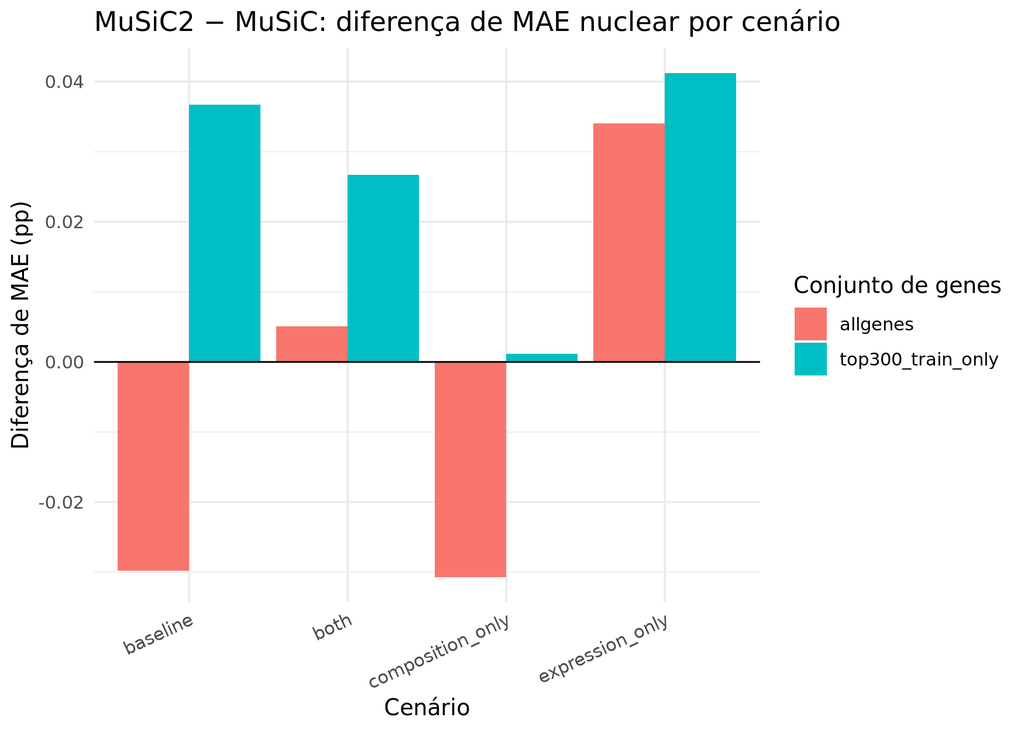

### Erros e vieses por tipo celular

| gene_set | method | cell_type | MAE_nuclear_pp | MAE_RNA_pp | bias_nuclear_pp | frac_zero_positive |
| --- | --- | --- | --- | --- | --- | --- |
| allgenes | MuSiC | Ast | 2.5162 | 5.0066 | -0.2799 | 0.0000 |
| allgenes | MuSiC2 | Ast | 2.4920 | 5.0826 | -0.2065 | 0.0000 |
| allgenes | MuSiC | End | 3.7776 | 4.2161 | 1.1794 | 0.0000 |
| allgenes | MuSiC2 | End | 3.7797 | 4.1040 | 0.9905 | 0.0000 |
| allgenes | MuSiC | Ex | 3.3837 | 25.5115 | 2.2146 | 0.0000 |
| allgenes | MuSiC2 | Ex | 3.3909 | 25.4327 | 2.2934 | 0.0000 |
| allgenes | MuSiC | In | 3.6521 | 4.2007 | 0.0558 | 0.0000 |
| allgenes | MuSiC2 | In | 3.6042 | 4.0749 | 0.1678 | 0.0000 |
| allgenes | MuSiC | Mic | 1.6300 | 6.3862 | 1.3034 | 0.0000 |
| allgenes | MuSiC2 | Mic | 1.6298 | 6.3666 | 1.2838 | 0.0000 |
| allgenes | MuSiC | Oli | 2.2547 | 10.3835 | -2.2122 | 0.0000 |
| allgenes | MuSiC2 | Oli | 2.2585 | 10.4034 | -2.1924 | 0.0000 |
| allgenes | MuSiC | Opc | 2.7906 | 1.7787 | -1.5027 | 0.0025 |
| allgenes | MuSiC2 | Opc | 2.8170 | 1.7532 | -1.5360 | 0.0006 |
| allgenes | MuSiC | Per | 2.5637 | 2.7076 | -0.7584 | 0.0306 |
| allgenes | MuSiC2 | Per | 2.5537 | 2.6638 | -0.8006 | 0.0387 |
| top300_train_only | MuSiC | Ast | 2.5736 | 5.3831 | 0.0977 | 0.0000 |
| top300_train_only | MuSiC2 | Ast | 2.5607 | 5.4404 | 0.1525 | 0.0000 |
| top300_train_only | MuSiC | End | 3.8401 | 4.4830 | 1.5025 | 0.0000 |
| top300_train_only | MuSiC2 | End | 3.9595 | 4.4208 | 1.3786 | 0.0000 |
| top300_train_only | MuSiC | Ex | 3.5837 | 25.0960 | 2.6302 | 0.0000 |
| top300_train_only | MuSiC2 | Ex | 3.6019 | 25.0656 | 2.6606 | 0.0000 |
| top300_train_only | MuSiC | In | 3.5265 | 3.8871 | 0.3536 | 0.0000 |
| top300_train_only | MuSiC2 | In | 3.5393 | 3.8224 | 0.3906 | 0.0000 |
| top300_train_only | MuSiC | Mic | 1.1882 | 5.0212 | -0.0616 | 0.0000 |
| top300_train_only | MuSiC2 | Mic | 1.2229 | 4.9870 | -0.0958 | 0.0000 |
| top300_train_only | MuSiC | Oli | 1.9436 | 10.7784 | -1.8174 | 0.0000 |
| top300_train_only | MuSiC2 | Oli | 1.9138 | 10.8585 | -1.7372 | 0.0000 |
| top300_train_only | MuSiC | Opc | 2.1856 | 1.7237 | -1.0535 | 0.0000 |
| top300_train_only | MuSiC2 | Opc | 2.2398 | 1.7060 | -1.0871 | 0.0000 |
| top300_train_only | MuSiC | Per | 2.4705 | 2.3207 | -1.6514 | 0.0031 |
| top300_train_only | MuSiC2 | Per | 2.4855 | 2.3648 | -1.6620 | 0.0050 |

### 3.6.3 Figura — MAE nuclear por tipo celular no 06g

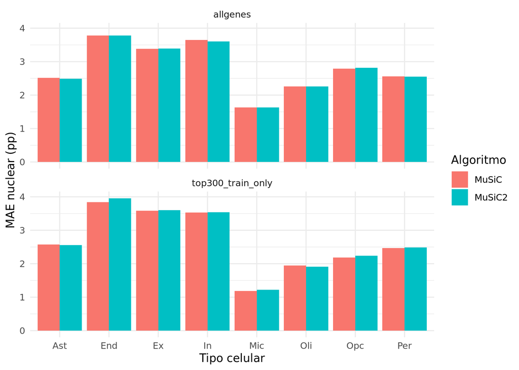

**Atenção:** MAE de fração nuclear e MAE da contribuição teórica de RNA são alvos diferentes. A contribuição de RNA não foi medida diretamente.

### 3.6.4 Verificação da seleção de genes durante o refinamento

*Precisão e sensibilidade apresentadas em porcentagem quando essas colunas estão disponíveis.*

| gene_set | scenario | execucoes | genes_verdadeiros_media | genes_removidos_media | precisao_media | sensibilidade_media |
| --- | --- | --- | --- | --- | --- | --- |
| allgenes | both | 20 | 952.25 | 2566.90 | 8.99 | 23.98 |
| allgenes | expression_only | 20 | 952.25 | 2551.55 | 8.83 | 23.67 |
| top300_train_only | both | 20 | 144.00 | 435.60 | 10.00 | 29.67 |
| top300_train_only | expression_only | 20 | 146.75 | 423.80 | 10.41 | 29.66 |

Fonte: `results/deconvolution/MuSiC2_Synthetic_Validation_06g/full/06g_DE_detection_summary.tsv`

**06g summary by scenario**

*Exibindo 20 de 256 linhas; tabela integral preservada no TSV original.*

| gene_set | scenario | method | group | cell_type | MAE_nuclear_pp | MAE_RNA_pp | RMSE_nuclear_pp | frac_zero_positive |
| --- | --- | --- | --- | --- | --- | --- | --- | --- |
| allgenes | baseline | MuSiC | Case | Ast | 2.220756 | 4.622688 | 2.785658 | 0.0000 |
| allgenes | baseline | MuSiC | Case | End | 3.788994 | 4.382609 | 5.296151 | 0.0000 |
| allgenes | baseline | MuSiC | Case | Ex | 3.635723 | 27.052691 | 4.464216 | 0.0000 |
| allgenes | baseline | MuSiC | Case | In | 3.559557 | 3.581254 | 4.336421 | 0.0000 |
| allgenes | baseline | MuSiC | Case | Mic | 1.610952 | 6.551366 | 2.061060 | 0.0000 |
| allgenes | baseline | MuSiC | Case | Oli | 2.251357 | 10.565270 | 2.596529 | 0.0000 |
| allgenes | baseline | MuSiC | Case | Opc | 2.833496 | 1.827359 | 3.200584 | 0.0050 |
| allgenes | baseline | MuSiC | Case | Per | 2.503354 | 2.750717 | 3.289269 | 0.0375 |
| allgenes | baseline | MuSiC | Control | Ast | 2.239211 | 4.624533 | 2.822816 | 0.0000 |
| allgenes | baseline | MuSiC | Control | End | 3.800031 | 4.393050 | 5.294343 | 0.0025 |
| allgenes | baseline | MuSiC | Control | Ex | 3.661256 | 26.943465 | 4.495543 | 0.0000 |
| allgenes | baseline | MuSiC | Control | In | 3.540144 | 3.602495 | 4.333824 | 0.0000 |
| allgenes | baseline | MuSiC | Control | Mic | 1.634976 | 6.507202 | 2.078770 | 0.0000 |
| allgenes | baseline | MuSiC | Control | Oli | 2.294023 | 10.595674 | 2.616238 | 0.0000 |
| allgenes | baseline | MuSiC | Control | Opc | 2.819554 | 1.872084 | 3.151900 | 0.0000 |
| allgenes | baseline | MuSiC | Control | Per | 2.589833 | 2.695478 | 3.488710 | 0.0250 |
| allgenes | baseline | MuSiC2 | Case | Ast | 2.234459 | 4.686762 | 2.811344 | 0.0000 |
| allgenes | baseline | MuSiC2 | Case | End | 3.711190 | 4.255457 | 5.185456 | 0.0000 |
| allgenes | baseline | MuSiC2 | Case | Ex | 3.664230 | 26.904057 | 4.575183 | 0.0000 |
| allgenes | baseline | MuSiC2 | Case | In | 3.463603 | 3.533664 | 4.321682 | 0.0000 |

Fonte: `results/deconvolution/MuSiC2_Synthetic_Validation_06g/full/06g_summary_by_scenario.tsv`

**06g paired methods**

*Exibindo 20 de 2.560 linhas; tabela integral preservada no TSV original.*

| fold | gene_set | profile | scenario | group | cell_type | MuSiC | MuSiC2 | delta_MAE_MuSiC2_minus_MuSiC |
| --- | --- | --- | --- | --- | --- | --- | --- | --- |
| 1 | allgenes | cortical_like | baseline | Case | Ast | 0.9060047 | 1.1363222 | 0.2303175 |
| 1 | allgenes | cortical_like | baseline | Case | End | 1.2921799 | 1.2748565 | -0.0173233 |
| 1 | allgenes | cortical_like | baseline | Case | Ex | 5.4137771 | 5.8404777 | 0.4267005 |
| 1 | allgenes | cortical_like | baseline | Case | In | 0.4807741 | 0.2763143 | -0.2044598 |
| 1 | allgenes | cortical_like | baseline | Case | Mic | 0.6392290 | 0.5916812 | -0.0475478 |
| 1 | allgenes | cortical_like | baseline | Case | Oli | 3.4122234 | 3.2261105 | -0.1861129 |
| 1 | allgenes | cortical_like | baseline | Case | Opc | 0.9520612 | 1.1065842 | 0.1545231 |
| 1 | allgenes | cortical_like | baseline | Case | Per | 1.8279202 | 1.9520925 | 0.1241724 |
| 1 | allgenes | cortical_like | baseline | Control | Ast | 0.7594934 | 0.7594934 | 0.0000000 |
| 1 | allgenes | cortical_like | baseline | Control | End | 1.5045645 | 1.5045645 | 0.0000000 |
| 1 | allgenes | cortical_like | baseline | Control | Ex | 5.5153759 | 5.5153759 | 0.0000000 |
| 1 | allgenes | cortical_like | baseline | Control | In | 0.3893975 | 0.3893975 | 0.0000000 |
| 1 | allgenes | cortical_like | baseline | Control | Mic | 0.5933529 | 0.5933529 | 0.0000000 |
| 1 | allgenes | cortical_like | baseline | Control | Oli | 3.5236344 | 3.5236344 | 0.0000000 |
| 1 | allgenes | cortical_like | baseline | Control | Opc | 1.0375411 | 1.0375411 | 0.0000000 |
| 1 | allgenes | cortical_like | baseline | Control | Per | 1.7379685 | 1.7379685 | 0.0000000 |
| 1 | allgenes | cortical_like | both | Case | Ast | 0.9130558 | 1.4633237 | 0.5502679 |
| 1 | allgenes | cortical_like | both | Case | End | 1.3419864 | 1.2148812 | -0.1271052 |
| 1 | allgenes | cortical_like | both | Case | Ex | 5.2252639 | 4.8339444 | -0.3913195 |
| 1 | allgenes | cortical_like | both | Case | In | 0.5090747 | 0.6083344 | 0.0992598 |

Fonte: `results/deconvolution/MuSiC2_Synthetic_Validation_06g/full/06g_paired_methods.tsv`

# 4 BisqueRNA: deconvolução e auditorias

## 4.1 07 — Deconvolução principal

As estimativas do BisqueRNA devem ser interpretadas considerando a transformação baseada na referência. A ausência de colapso de In/Opc não demonstra, por si só, acurácia.

**07 status**

| dataset | reference_version | marker_set | check | status | observed | expected | note |
| --- | --- | --- | --- | --- | --- | --- | --- |
| ROSMAP | main24 | top300 | execution | PASS | completed | completed | NA |
| ROSMAP | main24 | top300 | eight_celltypes | PASS | 8 | 8 | NA |
| ROSMAP | main24 | top300 | all_samples_returned | PASS | 144 | 144 | NA |
| ROSMAP | main24 | top300 | sum_to_one | PASS | 8.88178419700125e-16 | 0.001 | NA |
| ROSMAP | main24 | top300 | no_technical_feature_used | PASS | TRUE | TRUE | NA |
| ROSMAP | main24 | top300 | constant_vector_degeneracy | PASS | FALSE | FALSE | Todas as oito proporções quase constantes entre amostras: revisar Bisque. |
| ROSMAP | main24 | top300 | near_uniform_degeneracy | PASS | FALSE | FALSE | Próximo de 12,5% por tipo e sem variabilidade: NÃO usar como evidência independente. |
| ROSMAP | main24 | top300 | plot_generation | PASS | 4/4 figuras geradas | 4/4 | NA |
| GSE125583 | main24 | top300 | execution | PASS | completed | completed | NA |
| GSE125583 | main24 | top300 | eight_celltypes | PASS | 8 | 8 | NA |
| GSE125583 | main24 | top300 | all_samples_returned | PASS | 289 | 289 | NA |
| GSE125583 | main24 | top300 | sum_to_one | PASS | 8.88178419700125e-16 | 0.001 | NA |
| GSE125583 | main24 | top300 | no_technical_feature_used | PASS | TRUE | TRUE | NA |
| GSE125583 | main24 | top300 | constant_vector_degeneracy | PASS | FALSE | FALSE | Todas as oito proporções quase constantes entre amostras: revisar Bisque. |
| GSE125583 | main24 | top300 | near_uniform_degeneracy | PASS | FALSE | FALSE | Próximo de 12,5% por tipo e sem variabilidade: NÃO usar como evidência independente. |
| GSE125583 | main24 | top300 | plot_generation | PASS | 4/4 figuras geradas | 4/4 | NA |
| GSE64810 | main24 | top300 | execution | PASS | completed | completed | NA |
| GSE64810 | main24 | top300 | eight_celltypes | PASS | 8 | 8 | NA |
| GSE64810 | main24 | top300 | all_samples_returned | PASS | 69 | 69 | NA |
| GSE64810 | main24 | top300 | sum_to_one | PASS | 6.66133814775094e-16 | 0.001 | NA |
| GSE64810 | main24 | top300 | no_technical_feature_used | PASS | TRUE | TRUE | NA |
| GSE64810 | main24 | top300 | constant_vector_degeneracy | PASS | FALSE | FALSE | Todas as oito proporções quase constantes entre amostras: revisar Bisque. |
| GSE64810 | main24 | top300 | near_uniform_degeneracy | PASS | FALSE | FALSE | Próximo de 12,5% por tipo e sem variabilidade: NÃO usar como evidência independente. |
| GSE64810 | main24 | top300 | plot_generation | PASS | 4/4 figuras geradas | 4/4 | NA |
| GSE68719 | main24 | top300 | execution | PASS | completed | completed | NA |
| GSE68719 | main24 | top300 | eight_celltypes | PASS | 8 | 8 | NA |
| GSE68719 | main24 | top300 | all_samples_returned | PASS | 73 | 73 | NA |
| GSE68719 | main24 | top300 | sum_to_one | PASS | 8.88178419700125e-16 | 0.001 | NA |
| GSE68719 | main24 | top300 | no_technical_feature_used | PASS | TRUE | TRUE | NA |
| GSE68719 | main24 | top300 | constant_vector_degeneracy | PASS | FALSE | FALSE | Todas as oito proporções quase constantes entre amostras: revisar Bisque. |
| GSE68719 | main24 | top300 | near_uniform_degeneracy | PASS | FALSE | FALSE | Próximo de 12,5% por tipo e sem variabilidade: NÃO usar como evidência independente. |
| GSE68719 | main24 | top300 | plot_generation | PASS | 4/4 figuras geradas | 4/4 | NA |

Fonte: `results/deconvolution/BisqueRNA/07_status.tsv`

**07 run summary**

| dataset | disease | cohort_role | reference_version | marker_set | reference_donors | reference_nuclei | genes_input | genes_used | bulk_samples | controls | cases | max_proportion_sum_error | min_proportion | max_proportion | degenerate_uniform | degenerate_constant | low_variance_celltypes | unique_vectors_6dec | fraction_samples_uniform | median_uniform_rmse_pp | median_celltype_sd_pp | elapsed_seconds |
| --- | --- | --- | --- | --- | --- | --- | --- | --- | --- | --- | --- | --- | --- | --- | --- | --- | --- | --- | --- | --- | --- | --- |
| ROSMAP | AD | principal | main24 | top300 | 24 | 35140 | 2222 | 2222 | 144 | 67 | 77 | 0 | 0 | 0.6835451 | FALSE | FALSE | 0 | 144 | 0 | 16.33011 | 2.182554 | 0.025 |
| GSE125583 | AD | validation | main24 | top300 | 24 | 35140 | 2241 | 2241 | 289 | 70 | 219 | 0 | 0 | 0.6488111 | FALSE | FALSE | 0 | 289 | 0 | 15.54185 | 1.725721 | 0.043 |
| GSE64810 | HD | principal | main24 | top300 | 24 | 35140 | 2241 | 2241 | 69 | 49 | 20 | 0 | 0 | 0.6466508 | FALSE | FALSE | 0 | 69 | 0 | 16.37518 | 2.026291 | 0.012 |
| GSE68719 | PD | principal | main24 | top300 | 24 | 35140 | 2241 | 2241 | 73 | 44 | 29 | 0 | 0 | 0.6262868 | FALSE | FALSE | 0 | 73 | 0 | 16.41106 | 1.933049 | 0.016 |

Fonte: `results/deconvolution/BisqueRNA/07_run_summary.tsv`

**07 proportion summary all**

*Exibindo 60 de 64 linhas; tabela integral preservada no TSV original.*

| dataset | disease | cohort_role | reference_version | marker_set | group | cell_type | n_samples | mean_proportion | median_proportion | sd_proportion | min_proportion | max_proportion |
| --- | --- | --- | --- | --- | --- | --- | --- | --- | --- | --- | --- | --- |
| ROSMAP | AD | principal | main24 | top300 | Control | Ex | 67 | 0.4957306 | 0.5006034 | 0.0617516 | 0.3022958 | 0.6835451 |
| ROSMAP | AD | principal | main24 | top300 | AD | Ex | 77 | 0.4796364 | 0.4926116 | 0.0547197 | 0.3765739 | 0.5999451 |
| ROSMAP | AD | principal | main24 | top300 | Control | In | 67 | 0.1384933 | 0.1442482 | 0.0247179 | 0.0910612 | 0.1814719 |
| ROSMAP | AD | principal | main24 | top300 | AD | In | 77 | 0.1324668 | 0.1266838 | 0.0223372 | 0.0912378 | 0.1802141 |
| ROSMAP | AD | principal | main24 | top300 | Control | Ast | 67 | 0.0410962 | 0.0384873 | 0.0204971 | 0.0000000 | 0.0858402 |
| ROSMAP | AD | principal | main24 | top300 | AD | Ast | 77 | 0.0441382 | 0.0399590 | 0.0197073 | 0.0086105 | 0.1025812 |
| ROSMAP | AD | principal | main24 | top300 | Control | Oli | 67 | 0.2483809 | 0.2472331 | 0.0292024 | 0.1721467 | 0.3656572 |
| ROSMAP | AD | principal | main24 | top300 | AD | Oli | 77 | 0.2548878 | 0.2536265 | 0.0325810 | 0.1793134 | 0.3368544 |
| ROSMAP | AD | principal | main24 | top300 | Control | Opc | 67 | 0.0358185 | 0.0338848 | 0.0142670 | 0.0000000 | 0.0727978 |
| ROSMAP | AD | principal | main24 | top300 | AD | Opc | 77 | 0.0363215 | 0.0343222 | 0.0156008 | 0.0087315 | 0.0652431 |
| ROSMAP | AD | principal | main24 | top300 | Control | Mic | 67 | 0.0216251 | 0.0063209 | 0.0271888 | 0.0000000 | 0.0918974 |
| ROSMAP | AD | principal | main24 | top300 | AD | Mic | 77 | 0.0268319 | 0.0192002 | 0.0273301 | 0.0000000 | 0.0814338 |
| ROSMAP | AD | principal | main24 | top300 | Control | End | 67 | 0.0092500 | 0.0000000 | 0.0174522 | 0.0000000 | 0.0691534 |
| ROSMAP | AD | principal | main24 | top300 | AD | End | 77 | 0.0126039 | 0.0000000 | 0.0180461 | 0.0000000 | 0.0609783 |
| ROSMAP | AD | principal | main24 | top300 | Control | Per | 67 | 0.0096054 | 0.0000000 | 0.0176259 | 0.0000000 | 0.0673505 |
| ROSMAP | AD | principal | main24 | top300 | AD | Per | 77 | 0.0131136 | 0.0000000 | 0.0185810 | 0.0000000 | 0.0703110 |
| GSE125583 | AD | validation | main24 | top300 | AD | Ex | 219 | 0.4704571 | 0.4617814 | 0.0631926 | 0.3206567 | 0.6322104 |
| GSE125583 | AD | validation | main24 | top300 | Control | Ex | 70 | 0.5254774 | 0.5292039 | 0.0610575 | 0.3880287 | 0.6488111 |
| GSE125583 | AD | validation | main24 | top300 | AD | In | 219 | 0.1327630 | 0.1311159 | 0.0114818 | 0.1085158 | 0.1870411 |
| GSE125583 | AD | validation | main24 | top300 | Control | In | 70 | 0.1416707 | 0.1378208 | 0.0166410 | 0.1177479 | 0.1870755 |
| GSE125583 | AD | validation | main24 | top300 | AD | Ast | 219 | 0.0419627 | 0.0397565 | 0.0188937 | 0.0000000 | 0.0947840 |
| GSE125583 | AD | validation | main24 | top300 | Control | Ast | 70 | 0.0395181 | 0.0339433 | 0.0235051 | 0.0000000 | 0.1121189 |
| GSE125583 | AD | validation | main24 | top300 | AD | Oli | 219 | 0.2575975 | 0.2441112 | 0.0676010 | 0.1477815 | 0.5041151 |
| GSE125583 | AD | validation | main24 | top300 | Control | Oli | 70 | 0.2276196 | 0.2206418 | 0.0405825 | 0.1489973 | 0.3279024 |
| GSE125583 | AD | validation | main24 | top300 | AD | Opc | 219 | 0.0375465 | 0.0385105 | 0.0137030 | 0.0073833 | 0.0738404 |
| GSE125583 | AD | validation | main24 | top300 | Control | Opc | 70 | 0.0309940 | 0.0298762 | 0.0125965 | 0.0066607 | 0.0602531 |
| GSE125583 | AD | validation | main24 | top300 | AD | Mic | 219 | 0.0321770 | 0.0346767 | 0.0223652 | 0.0000000 | 0.0722233 |
| GSE125583 | AD | validation | main24 | top300 | Control | Mic | 70 | 0.0197680 | 0.0123893 | 0.0211516 | 0.0000000 | 0.0736636 |
| GSE125583 | AD | validation | main24 | top300 | AD | End | 219 | 0.0127734 | 0.0078192 | 0.0137175 | 0.0000000 | 0.0493096 |
| GSE125583 | AD | validation | main24 | top300 | Control | End | 70 | 0.0074505 | 0.0000000 | 0.0120768 | 0.0000000 | 0.0453682 |
| GSE125583 | AD | validation | main24 | top300 | AD | Per | 219 | 0.0147228 | 0.0104422 | 0.0147145 | 0.0000000 | 0.0516349 |
| GSE125583 | AD | validation | main24 | top300 | Control | Per | 70 | 0.0075017 | 0.0000000 | 0.0120036 | 0.0000000 | 0.0489454 |
| GSE64810 | HD | principal | main24 | top300 | Control | Ex | 49 | 0.4913669 | 0.4986067 | 0.0751663 | 0.2485910 | 0.6177273 |
| GSE64810 | HD | principal | main24 | top300 | HD | Ex | 20 | 0.4802779 | 0.4869021 | 0.0730779 | 0.3367433 | 0.5894575 |
| GSE64810 | HD | principal | main24 | top300 | Control | In | 49 | 0.1369566 | 0.1349950 | 0.0183596 | 0.0807103 | 0.1804011 |
| GSE64810 | HD | principal | main24 | top300 | HD | In | 20 | 0.1313935 | 0.1304367 | 0.0157098 | 0.0965815 | 0.1627547 |
| GSE64810 | HD | principal | main24 | top300 | Control | Ast | 49 | 0.0394225 | 0.0409422 | 0.0210231 | 0.0000000 | 0.0822932 |
| GSE64810 | HD | principal | main24 | top300 | HD | Ast | 20 | 0.0534478 | 0.0519091 | 0.0301369 | 0.0048925 | 0.1331949 |
| GSE64810 | HD | principal | main24 | top300 | Control | Oli | 49 | 0.2568159 | 0.2330371 | 0.0819278 | 0.1839810 | 0.6466508 |
| GSE64810 | HD | principal | main24 | top300 | HD | Oli | 20 | 0.2404710 | 0.2309971 | 0.0621246 | 0.1896518 | 0.4717510 |
| GSE64810 | HD | principal | main24 | top300 | Control | Opc | 49 | 0.0339298 | 0.0327639 | 0.0096805 | 0.0187010 | 0.0638058 |
| GSE64810 | HD | principal | main24 | top300 | HD | Opc | 20 | 0.0413794 | 0.0415010 | 0.0090457 | 0.0228743 | 0.0586203 |
| GSE64810 | HD | principal | main24 | top300 | Control | Mic | 49 | 0.0243821 | 0.0290367 | 0.0229629 | 0.0000000 | 0.0759236 |
| GSE64810 | HD | principal | main24 | top300 | HD | Mic | 20 | 0.0310724 | 0.0319773 | 0.0223340 | 0.0000000 | 0.0764391 |
| GSE64810 | HD | principal | main24 | top300 | Control | End | 49 | 0.0079820 | 0.0000000 | 0.0119500 | 0.0000000 | 0.0450393 |
| GSE64810 | HD | principal | main24 | top300 | HD | End | 20 | 0.0109846 | 0.0043590 | 0.0129755 | 0.0000000 | 0.0442124 |
| GSE64810 | HD | principal | main24 | top300 | Control | Per | 49 | 0.0091443 | 0.0000000 | 0.0138876 | 0.0000000 | 0.0507863 |
| GSE64810 | HD | principal | main24 | top300 | HD | Per | 20 | 0.0109734 | 0.0036543 | 0.0129026 | 0.0000000 | 0.0350961 |
| GSE68719 | PD | principal | main24 | top300 | Control | Ex | 44 | 0.5061438 | 0.5151598 | 0.0695169 | 0.2760580 | 0.6262868 |
| GSE68719 | PD | principal | main24 | top300 | PD | Ex | 29 | 0.4579686 | 0.4548395 | 0.0703502 | 0.2778412 | 0.5924737 |
| GSE68719 | PD | principal | main24 | top300 | Control | In | 44 | 0.1394691 | 0.1374558 | 0.0183624 | 0.0788524 | 0.1854179 |
| GSE68719 | PD | principal | main24 | top300 | PD | In | 29 | 0.1287684 | 0.1263650 | 0.0118261 | 0.1017462 | 0.1567488 |
| GSE68719 | PD | principal | main24 | top300 | Control | Ast | 44 | 0.0382186 | 0.0392148 | 0.0229214 | 0.0000000 | 0.0844158 |
| GSE68719 | PD | principal | main24 | top300 | PD | Ast | 29 | 0.0505371 | 0.0509606 | 0.0212739 | 0.0060115 | 0.0999281 |
| GSE68719 | PD | principal | main24 | top300 | Control | Oli | 44 | 0.2489192 | 0.2271616 | 0.0788128 | 0.1775825 | 0.6220114 |
| GSE68719 | PD | principal | main24 | top300 | PD | Oli | 29 | 0.2556126 | 0.2391099 | 0.0739874 | 0.1834392 | 0.5297551 |
| GSE68719 | PD | principal | main24 | top300 | Control | Opc | 44 | 0.0373430 | 0.0360734 | 0.0097110 | 0.0228388 | 0.0666424 |
| GSE68719 | PD | principal | main24 | top300 | PD | Opc | 29 | 0.0340267 | 0.0320889 | 0.0061816 | 0.0206027 | 0.0454011 |
| GSE68719 | PD | principal | main24 | top300 | Control | Mic | 44 | 0.0189483 | 0.0176177 | 0.0194974 | 0.0000000 | 0.0658554 |
| GSE68719 | PD | principal | main24 | top300 | PD | Mic | 29 | 0.0409028 | 0.0426007 | 0.0184336 | 0.0000000 | 0.0754151 |

Fonte: `results/deconvolution/BisqueRNA/07_proportion_summary_all.tsv`

**Figura — 07 boxplots by celltype**

Arquivo: `results/deconvolution/BisqueRNA/GSE125583/main24/top300/plots/07_boxplots_by_celltype.png`

**Figura — 07 mean composition stacked**

Arquivo: `results/deconvolution/BisqueRNA/GSE125583/main24/top300/plots/07_mean_composition_stacked.png`

**Figura — 07 variability sd**

Arquivo: `results/deconvolution/BisqueRNA/GSE125583/main24/top300/plots/07_variability_sd.png`

**Figura — 07 zero fraction**

Arquivo: `results/deconvolution/BisqueRNA/GSE125583/main24/top300/plots/07_zero_fraction.png`

**Figura — 07 boxplots by celltype**

Arquivo: `results/deconvolution/BisqueRNA/GSE64810/main24/top300/plots/07_boxplots_by_celltype.png`

**Figura — 07 mean composition stacked**

Arquivo: `results/deconvolution/BisqueRNA/GSE64810/main24/top300/plots/07_mean_composition_stacked.png`

**Figura — 07 variability sd**

Arquivo: `results/deconvolution/BisqueRNA/GSE64810/main24/top300/plots/07_variability_sd.png`

**Figura — 07 zero fraction**

Arquivo: `results/deconvolution/BisqueRNA/GSE64810/main24/top300/plots/07_zero_fraction.png`

**Figura — 07 boxplots by celltype**

Arquivo: `results/deconvolution/BisqueRNA/GSE68719/main24/top300/plots/07_boxplots_by_celltype.png`

**Figura — 07 mean composition stacked**

Arquivo: `results/deconvolution/BisqueRNA/GSE68719/main24/top300/plots/07_mean_composition_stacked.png`

**Figura — 07 variability sd**

Arquivo: `results/deconvolution/BisqueRNA/GSE68719/main24/top300/plots/07_variability_sd.png`

**Figura — 07 zero fraction**

Arquivo: `results/deconvolution/BisqueRNA/GSE68719/main24/top300/plots/07_zero_fraction.png`

**Figura — 07 variability all**

Arquivo: `results/deconvolution/BisqueRNA/plots/07_variability_all.png`

**Figura — 07 zero fraction all**

Arquivo: `results/deconvolution/BisqueRNA/plots/07_zero_fraction_all.png`

**Figura — 07 boxplots by celltype**

Arquivo: `results/deconvolution/BisqueRNA/ROSMAP/main24/top300/plots/07_boxplots_by_celltype.png`

**Figura — 07 mean composition stacked**

Arquivo: `results/deconvolution/BisqueRNA/ROSMAP/main24/top300/plots/07_mean_composition_stacked.png`

**Figura — 07 variability sd**

Arquivo: `results/deconvolution/BisqueRNA/ROSMAP/main24/top300/plots/07_variability_sd.png`

**Figura — 07 zero fraction**

Arquivo: `results/deconvolution/BisqueRNA/ROSMAP/main24/top300/plots/07_zero_fraction.png`

## 4.2 07b — Diagnósticos de normalização e estabilidade

Comparação de opções de normalização e de comportamento entre amostras, sem seleção por significância de caso–controle.

*Nenhuma figura salva nesta etapa.*

## 4.3 07d-A — Dependência da composição da referência

Avalia como a representação relativa dos tipos celulares na referência afeta as frações estimadas no bulk.

**07d A reference sample sizes**

*Exibindo 60 de 96 linhas; tabela integral preservada no TSV original.*

| replicate | scenario | cell_type | n_nuclei |
| --- | --- | --- | --- |
| 1 | ref_like | Ex | 2918 |
| 1 | ref_like | In | 824 |
| 1 | ref_like | Ast | 267 |
| 1 | ref_like | Oli | 1571 |
| 1 | ref_like | Opc | 228 |
| 1 | ref_like | Mic | 165 |
| 1 | ref_like | End | 11 |
| 1 | ref_like | Per | 16 |
| 1 | in_low | Ex | 3398 |
| 1 | in_low | In | 344 |
| 1 | in_low | Ast | 267 |
| 1 | in_low | Oli | 1571 |
| 1 | in_low | Opc | 228 |
| 1 | in_low | Mic | 165 |
| 1 | in_low | End | 11 |
| 1 | in_low | Per | 16 |
| 1 | in_high | Ex | 2438 |
| 1 | in_high | In | 1304 |
| 1 | in_high | Ast | 267 |
| 1 | in_high | Oli | 1571 |
| 1 | in_high | Opc | 228 |
| 1 | in_high | Mic | 165 |
| 1 | in_high | End | 11 |
| 1 | in_high | Per | 16 |
| 1 | opc_low | Ex | 3068 |
| 1 | opc_low | In | 824 |
| 1 | opc_low | Ast | 267 |
| 1 | opc_low | Oli | 1571 |
| 1 | opc_low | Opc | 78 |
| 1 | opc_low | Mic | 165 |
| 1 | opc_low | End | 11 |
| 1 | opc_low | Per | 16 |
| 1 | opc_high | Ex | 2558 |
| 1 | opc_high | In | 824 |
| 1 | opc_high | Ast | 267 |
| 1 | opc_high | Oli | 1571 |
| 1 | opc_high | Opc | 588 |
| 1 | opc_high | Mic | 165 |
| 1 | opc_high | End | 11 |
| 1 | opc_high | Per | 16 |
| 1 | vascular_high | Ex | 2837 |
| 1 | vascular_high | In | 824 |
| 1 | vascular_high | Ast | 267 |
| 1 | vascular_high | Oli | 1571 |
| 1 | vascular_high | Opc | 228 |
| 1 | vascular_high | Mic | 165 |
| 1 | vascular_high | End | 48 |
| 1 | vascular_high | Per | 60 |
| 2 | ref_like | Ex | 2918 |
| 2 | ref_like | In | 824 |
| 2 | ref_like | Ast | 267 |
| 2 | ref_like | Oli | 1571 |
| 2 | ref_like | Opc | 228 |
| 2 | ref_like | Mic | 165 |
| 2 | ref_like | End | 11 |
| 2 | ref_like | Per | 16 |
| 2 | in_low | Ex | 3398 |
| 2 | in_low | In | 344 |
| 2 | in_low | Ast | 267 |
| 2 | in_low | Oli | 1571 |

Fonte: `results/deconvolution/BisqueRNA_Audit/07d/A/07d_A_reference_sample_sizes.tsv`

**07d A composition dependence**

| dataset | scenario | cell_type | n_replicates | reference_fraction_mean | estimated_fraction_mean | estimated_fraction_sd_across_reps | delta_from_ref_like_mean_pp | delta_from_ref_like_sd_pp |
| --- | --- | --- | --- | --- | --- | --- | --- | --- |
| GSE64810 | in_high | Ast | 2 | 0.0445000 | 0.0424555 | 0.0008886 | -0.0843936 | 0.1132445 |
| GSE64810 | in_high | End | 2 | 0.0018333 | 0.0079484 | 0.0019621 | -0.0187612 | 0.0229450 |
| GSE64810 | in_high | Ex | 2 | 0.4063333 | 0.4096831 | 0.0062440 | -7.7696829 | 0.0782397 |
| GSE64810 | in_high | In | 2 | 0.2173333 | 0.2141966 | 0.0033783 | 8.0017314 | 0.3072161 |
| GSE64810 | in_high | Mic | 2 | 0.0275000 | 0.0272962 | 0.0002007 | -0.0335510 | 0.0279742 |
| GSE64810 | in_high | Oli | 2 | 0.2618333 | 0.2536346 | 0.0015885 | -0.0561707 | 0.1663378 |
| GSE64810 | in_high | Opc | 2 | 0.0380000 | 0.0354742 | 0.0009350 | -0.0286278 | 0.0365786 |
| GSE64810 | in_high | Per | 2 | 0.0026667 | 0.0093114 | 0.0008393 | -0.0105443 | 0.0183757 |
| GSE64810 | in_low | Ast | 2 | 0.0445000 | 0.0438377 | 0.0021780 | 0.0538293 | 0.0156918 |
| GSE64810 | in_low | End | 2 | 0.0018333 | 0.0083351 | 0.0023219 | 0.0199096 | 0.0130343 |
| GSE64810 | in_low | Ex | 2 | 0.5663333 | 0.5624514 | 0.0060781 | 7.5071513 | 0.0948356 |
| GSE64810 | in_low | In | 2 | 0.0573333 | 0.0573597 | 0.0003195 | -7.6819650 | 0.0625678 |
| GSE64810 | in_low | Mic | 2 | 0.0275000 | 0.0278957 | 0.0004860 | 0.0263957 | 0.0005510 |
| GSE64810 | in_low | Oli | 2 | 0.2618333 | 0.2546204 | 0.0027934 | 0.0424078 | 0.0458443 |
| GSE64810 | in_low | Opc | 2 | 0.0380000 | 0.0359619 | 0.0006955 | 0.0201459 | 0.0126295 |
| GSE64810 | in_low | Per | 2 | 0.0026667 | 0.0095381 | 0.0006863 | 0.0121255 | 0.0030712 |
| GSE64810 | opc_high | Ast | 2 | 0.0445000 | 0.0431366 | 0.0013901 | -0.0162823 | 0.0630937 |
| GSE64810 | opc_high | End | 2 | 0.0018333 | 0.0079314 | 0.0021252 | -0.0204602 | 0.0066406 |
| GSE64810 | opc_high | Ex | 2 | 0.4263333 | 0.4315454 | 0.0063177 | -5.5834546 | 0.0708670 |
| GSE64810 | opc_high | In | 2 | 0.1373333 | 0.1344349 | 0.0005282 | 0.0255615 | 0.0834411 |
| GSE64810 | opc_high | Mic | 2 | 0.0275000 | 0.0274470 | 0.0004003 | -0.0184710 | 0.0080170 |
| GSE64810 | opc_high | Oli | 2 | 0.2618333 | 0.2539767 | 0.0031422 | -0.0219658 | 0.0109634 |
| GSE64810 | opc_high | Opc | 2 | 0.0980000 | 0.0922746 | 0.0004365 | 5.6514125 | 0.1005634 |
| GSE64810 | opc_high | Per | 2 | 0.0026667 | 0.0092535 | 0.0006483 | -0.0163402 | 0.0007253 |
| GSE64810 | opc_low | Ast | 2 | 0.0445000 | 0.0433035 | 0.0021190 | 0.0004086 | 0.0097904 |
| GSE64810 | opc_low | End | 2 | 0.0018333 | 0.0082396 | 0.0022156 | 0.0103593 | 0.0023961 |
| GSE64810 | opc_low | Ex | 2 | 0.5113333 | 0.5101780 | 0.0066894 | 2.2798067 | 0.0337038 |
| GSE64810 | opc_low | In | 2 | 0.1373333 | 0.1340863 | 0.0004232 | -0.0093004 | 0.0117011 |
| GSE64810 | opc_low | Mic | 2 | 0.0275000 | 0.0277233 | 0.0004364 | 0.0091514 | 0.0044053 |
| GSE64810 | opc_low | Oli | 2 | 0.2618333 | 0.2546455 | 0.0032692 | 0.0449105 | 0.0017324 |
| GSE64810 | opc_low | Opc | 2 | 0.0130000 | 0.0123125 | 0.0010759 | -2.3447935 | 0.0506761 |
| GSE64810 | opc_low | Per | 2 | 0.0026667 | 0.0095115 | 0.0006980 | 0.0094574 | 0.0042425 |
| GSE64810 | ref_like | Ast | 2 | 0.0445000 | 0.0432994 | 0.0020211 | 0.0000000 | 0.0000000 |
| GSE64810 | ref_like | End | 2 | 0.0018333 | 0.0081360 | 0.0021916 | 0.0000000 | 0.0000000 |
| GSE64810 | ref_like | Ex | 2 | 0.4863333 | 0.4873799 | 0.0070264 | 0.0000000 | 0.0000000 |
| GSE64810 | ref_like | In | 2 | 0.1373333 | 0.1341793 | 0.0003062 | 0.0000000 | 0.0000000 |
| GSE64810 | ref_like | Mic | 2 | 0.0275000 | 0.0276318 | 0.0004805 | 0.0000000 | 0.0000000 |
| GSE64810 | ref_like | Oli | 2 | 0.2618333 | 0.2541964 | 0.0032519 | 0.0000000 | 0.0000000 |
| GSE64810 | ref_like | Opc | 2 | 0.0380000 | 0.0357604 | 0.0005692 | 0.0000000 | 0.0000000 |
| GSE64810 | ref_like | Per | 2 | 0.0026667 | 0.0094169 | 0.0006556 | 0.0000000 | 0.0000000 |
| GSE64810 | vascular_high | Ast | 2 | 0.0445000 | 0.0438391 | 0.0019250 | 0.0539662 | 0.0096078 |
| GSE64810 | vascular_high | End | 2 | 0.0080000 | 0.0126302 | 0.0001045 | 0.4494217 | 0.2296089 |
| GSE64810 | vascular_high | Ex | 2 | 0.4728333 | 0.4757837 | 0.0063713 | -1.1596221 | 0.0655081 |
| GSE64810 | vascular_high | In | 2 | 0.1373333 | 0.1344747 | 0.0004660 | 0.0295383 | 0.0159805 |
| GSE64810 | vascular_high | Mic | 2 | 0.0275000 | 0.0280342 | 0.0010903 | 0.0402480 | 0.0609848 |
| GSE64810 | vascular_high | Oli | 2 | 0.2618333 | 0.2546848 | 0.0032011 | 0.0488462 | 0.0050749 |
| GSE64810 | vascular_high | Opc | 2 | 0.0380000 | 0.0358919 | 0.0005248 | 0.0131505 | 0.0044355 |
| GSE64810 | vascular_high | Per | 2 | 0.0100000 | 0.0146614 | 0.0003182 | 0.5244511 | 0.0973827 |

Fonte: `results/deconvolution/BisqueRNA_Audit/07d/A/07d_A_composition_dependence.tsv`

**07d A individual fits**

*Exibindo 60 de 96 linhas; tabela integral preservada no TSV original.*

| replicate | cell_type | dataset | scenario | n_reference_nuclei | fraction_reference_pool | fraction_reference_donor_mean | mean_bulk_estimate | sd_bulk_estimate | genes_used | baseline_mean | delta_from_ref_like_pp |
| --- | --- | --- | --- | --- | --- | --- | --- | --- | --- | --- | --- |
| 1 | Ast | GSE64810 | in_high | 6000 | 0.0445000 | 0.0460411 | 0.0430838 | 0.0261602 | 2241 | 0.0447285 | -0.1644695 |
| 1 | End | GSE64810 | in_high | 6000 | 0.0018333 | 0.0015011 | 0.0093358 | 0.0132104 | 2241 | 0.0096857 | -0.0349858 |
| 1 | Ex | GSE64810 | in_high | 6000 | 0.4063333 | 0.4114091 | 0.4052679 | 0.0624478 | 2241 | 0.4824115 | -7.7143591 |
| 1 | In | GSE64810 | in_high | 6000 | 0.2173333 | 0.2175635 | 0.2165855 | 0.0298101 | 2241 | 0.1343958 | 8.2189661 |
| 1 | Mic | GSE64810 | in_high | 6000 | 0.0275000 | 0.0280423 | 0.0274382 | 0.0234495 | 2241 | 0.0279715 | -0.0533317 |
| 1 | Oli | GSE64810 | in_high | 6000 | 0.2618333 | 0.2572328 | 0.2547579 | 0.0762672 | 2241 | 0.2564958 | -0.1737893 |
| 1 | Opc | GSE64810 | in_high | 6000 | 0.0380000 | 0.0352444 | 0.0348130 | 0.0106511 | 2241 | 0.0353580 | -0.0544927 |
| 1 | Per | GSE64810 | in_high | 6000 | 0.0026667 | 0.0029656 | 0.0087179 | 0.0117078 | 2241 | 0.0089533 | -0.0235379 |
| 1 | Ast | GSE64810 | in_low | 6000 | 0.0445000 | 0.0484368 | 0.0453778 | 0.0298867 | 2241 | 0.0447285 | 0.0649251 |
| 1 | End | GSE64810 | in_low | 6000 | 0.0018333 | 0.0014561 | 0.0099769 | 0.0141136 | 2241 | 0.0096857 | 0.0291263 |
| 1 | Ex | GSE64810 | in_low | 6000 | 0.5663333 | 0.5648301 | 0.5581536 | 0.0843115 | 2241 | 0.4824115 | 7.5742101 |
| 1 | In | GSE64810 | in_low | 6000 | 0.0573333 | 0.0583358 | 0.0571337 | 0.0150625 | 2241 | 0.1343958 | -7.7262072 |
| 1 | Mic | GSE64810 | in_low | 6000 | 0.0275000 | 0.0285777 | 0.0282393 | 0.0245490 | 2241 | 0.0279715 | 0.0267853 |
| 1 | Oli | GSE64810 | in_low | 6000 | 0.2618333 | 0.2593365 | 0.2565957 | 0.0809254 | 2241 | 0.2564958 | 0.0099910 |
| 1 | Opc | GSE64810 | in_low | 6000 | 0.0380000 | 0.0359741 | 0.0354701 | 0.0119002 | 2241 | 0.0353580 | 0.0112155 |
| 1 | Per | GSE64810 | in_low | 6000 | 0.0026667 | 0.0030528 | 0.0090529 | 0.0122992 | 2241 | 0.0089533 | 0.0099538 |
| 1 | Ast | GSE64810 | opc_high | 6000 | 0.0445000 | 0.0470822 | 0.0441196 | 0.0276271 | 2241 | 0.0447285 | -0.0608962 |
| 1 | End | GSE64810 | opc_high | 6000 | 0.0018333 | 0.0014907 | 0.0094341 | 0.0133666 | 2241 | 0.0096857 | -0.0251558 |
| 1 | Ex | GSE64810 | opc_high | 6000 | 0.4263333 | 0.4332190 | 0.4270780 | 0.0685570 | 2241 | 0.4824115 | -5.5333440 |
| 1 | In | GSE64810 | opc_high | 6000 | 0.1373333 | 0.1351097 | 0.1340614 | 0.0211320 | 2241 | 0.1343958 | -0.0334403 |
| 1 | Mic | GSE64810 | opc_high | 6000 | 0.0275000 | 0.0282577 | 0.0277301 | 0.0235915 | 2241 | 0.0279715 | -0.0241399 |
| 1 | Oli | GSE64810 | opc_high | 6000 | 0.2618333 | 0.2586939 | 0.2561986 | 0.0770467 | 2241 | 0.2564958 | -0.0297181 |
| 1 | Opc | GSE64810 | opc_high | 6000 | 0.0980000 | 0.0931017 | 0.0925832 | 0.0154547 | 2241 | 0.0353580 | 5.7225215 |
| 1 | Per | GSE64810 | opc_high | 6000 | 0.0026667 | 0.0030450 | 0.0087950 | 0.0117998 | 2241 | 0.0089533 | -0.0158273 |
| 1 | Ast | GSE64810 | opc_low | 6000 | 0.0445000 | 0.0478991 | 0.0448018 | 0.0288137 | 2241 | 0.0447285 | 0.0073315 |
| 1 | End | GSE64810 | opc_low | 6000 | 0.0018333 | 0.0014729 | 0.0098062 | 0.0138738 | 2241 | 0.0096857 | 0.0120536 |
| 1 | Ex | GSE64810 | opc_low | 6000 | 0.5113333 | 0.5120709 | 0.5054479 | 0.0758664 | 2241 | 0.4824115 | 2.3036388 |
| 1 | In | GSE64810 | opc_low | 6000 | 0.1373333 | 0.1355935 | 0.1343855 | 0.0213839 | 2241 | 0.1343958 | -0.0010265 |
| 1 | Mic | GSE64810 | opc_low | 6000 | 0.0275000 | 0.0284369 | 0.0280319 | 0.0242891 | 2241 | 0.0279715 | 0.0060364 |
| 1 | Oli | GSE64810 | opc_low | 6000 | 0.2618333 | 0.2596604 | 0.2569571 | 0.0799482 | 2241 | 0.2564958 | 0.0461355 |
| 1 | Opc | GSE64810 | opc_low | 6000 | 0.0130000 | 0.0117889 | 0.0115517 | 0.0092839 | 2241 | 0.0353580 | -2.3806269 |
| 1 | Per | GSE64810 | opc_low | 6000 | 0.0026667 | 0.0030774 | 0.0090179 | 0.0122009 | 2241 | 0.0089533 | 0.0064576 |
| 1 | Ast | GSE64810 | ref_like | 6000 | 0.0445000 | 0.0477588 | 0.0447285 | 0.0285137 | 2241 | 0.0447285 | 0.0000000 |
| 1 | End | GSE64810 | ref_like | 6000 | 0.0018333 | 0.0014721 | 0.0096857 | 0.0137085 | 2241 | 0.0096857 | 0.0000000 |
| 1 | Ex | GSE64810 | ref_like | 6000 | 0.4863333 | 0.4888204 | 0.4824115 | 0.0739970 | 2241 | 0.4824115 | 0.0000000 |
| 1 | In | GSE64810 | ref_like | 6000 | 0.1373333 | 0.1355096 | 0.1343958 | 0.0213040 | 2241 | 0.1343958 | 0.0000000 |
| 1 | Mic | GSE64810 | ref_like | 6000 | 0.0275000 | 0.0284285 | 0.0279715 | 0.0240678 | 2241 | 0.0279715 | 0.0000000 |
| 1 | Oli | GSE64810 | ref_like | 6000 | 0.2618333 | 0.2591096 | 0.2564958 | 0.0787555 | 2241 | 0.2564958 | 0.0000000 |
| 1 | Opc | GSE64810 | ref_like | 6000 | 0.0380000 | 0.0358154 | 0.0353580 | 0.0113714 | 2241 | 0.0353580 | 0.0000000 |
| 1 | Per | GSE64810 | ref_like | 6000 | 0.0026667 | 0.0030857 | 0.0089533 | 0.0120787 | 2241 | 0.0089533 | 0.0000000 |
| 1 | Ast | GSE64810 | vascular_high | 6000 | 0.0445000 | 0.0474151 | 0.0452002 | 0.0273360 | 2241 | 0.0447285 | 0.0471724 |
| 1 | End | GSE64810 | vascular_high | 6000 | 0.0080000 | 0.0084830 | 0.0125563 | 0.0150027 | 2241 | 0.0096857 | 0.2870637 |
| 1 | Ex | GSE64810 | vascular_high | 6000 | 0.4728333 | 0.4757406 | 0.4712785 | 0.0738667 | 2241 | 0.4824115 | -1.1133009 |
| 1 | In | GSE64810 | vascular_high | 6000 | 0.1373333 | 0.1353628 | 0.1348042 | 0.0217524 | 2241 | 0.1343958 | 0.0408383 |
| 1 | Mic | GSE64810 | vascular_high | 6000 | 0.0275000 | 0.0281432 | 0.0288052 | 0.0230293 | 2241 | 0.0279715 | 0.0833707 |
| 1 | Oli | GSE64810 | vascular_high | 6000 | 0.2618333 | 0.2587045 | 0.2569483 | 0.0785820 | 2241 | 0.2564958 | 0.0452577 |
| 1 | Opc | GSE64810 | vascular_high | 6000 | 0.0380000 | 0.0357493 | 0.0355208 | 0.0113393 | 2241 | 0.0353580 | 0.0162869 |
| 1 | Per | GSE64810 | vascular_high | 6000 | 0.0100000 | 0.0104015 | 0.0148864 | 0.0173761 | 2241 | 0.0089533 | 0.5933111 |
| 2 | Ast | GSE64810 | in_high | 6000 | 0.0445000 | 0.0452595 | 0.0418271 | 0.0231916 | 2241 | 0.0418703 | -0.0043176 |
| 2 | End | GSE64810 | in_high | 6000 | 0.0018333 | 0.0019994 | 0.0065609 | 0.0090542 | 2241 | 0.0065863 | -0.0025366 |
| 2 | Ex | GSE64810 | in_high | 6000 | 0.4063333 | 0.4196674 | 0.4140983 | 0.0676210 | 2241 | 0.4923483 | -7.8250067 |
| 2 | In | GSE64810 | in_high | 6000 | 0.2173333 | 0.2126940 | 0.2118078 | 0.0259163 | 2241 | 0.1339628 | 7.7844968 |
| 2 | Mic | GSE64810 | in_high | 6000 | 0.0275000 | 0.0268058 | 0.0271543 | 0.0240138 | 2241 | 0.0272920 | -0.0137703 |
| 2 | Oli | GSE64810 | in_high | 6000 | 0.2618333 | 0.2549405 | 0.2525114 | 0.0782150 | 2241 | 0.2518969 | 0.0614479 |
| 2 | Opc | GSE64810 | in_high | 6000 | 0.0380000 | 0.0363886 | 0.0361353 | 0.0098966 | 2241 | 0.0361629 | -0.0027628 |
| 2 | Per | GSE64810 | in_high | 6000 | 0.0026667 | 0.0022448 | 0.0099049 | 0.0137076 | 2241 | 0.0098805 | 0.0024493 |
| 2 | Ast | GSE64810 | in_low | 6000 | 0.0445000 | 0.0457541 | 0.0422976 | 0.0239528 | 2241 | 0.0418703 | 0.0427335 |
| 2 | End | GSE64810 | in_low | 6000 | 0.0018333 | 0.0019195 | 0.0066932 | 0.0092503 | 2241 | 0.0065863 | 0.0106929 |
| 2 | Ex | GSE64810 | in_low | 6000 | 0.5663333 | 0.5726097 | 0.5667492 | 0.0817635 | 2241 | 0.4923483 | 7.4400924 |
| 2 | In | GSE64810 | in_low | 6000 | 0.0573333 | 0.0583726 | 0.0575856 | 0.0146690 | 2241 | 0.1339628 | -7.6377229 |

Fonte: `results/deconvolution/BisqueRNA_Audit/07d/A/07d_A_individual_fits.tsv`

*Nenhuma figura salva nesta etapa.*

## 4.4 07d-B — Dependência do contexto bulk

Testa se as mesmas amostras controle recebem proporções diferentes quando se acrescentam diferentes conjuntos de casos ao ajuste.

**07d B context input audit**

| context | n_samples | n_controls | n_genes | reference_source |
| --- | --- | --- | --- | --- |
| controls_only | 44 | 44 | 2241 | Mathys_24 |
| controls_plus_HD | 64 | 44 | 2241 | Mathys_24 |
| controls_plus_PD | 73 | 44 | 2241 | Mathys_24 |
| controls_plus_both | 93 | 44 | 2241 | Mathys_24 |

Fonte: `results/deconvolution/BisqueRNA_Audit/07d/B/07d_B_context_input_audit.tsv`

**07d B paired context differences**

| context_a | context_b | cell_type | mean_absolute_difference_pp | median_absolute_difference_pp | max_absolute_difference_pp | mean_signed_difference_pp |
| --- | --- | --- | --- | --- | --- | --- |
| controls_only | controls_plus_HD | Ex | 0.2975826 | 0.2983829 | 0.8619411 | 0.2215132 |
| controls_only | controls_plus_HD | In | 0.1880303 | 0.1913577 | 0.4545038 | 0.1822871 |
| controls_only | controls_plus_HD | Ast | 0.3845728 | 0.3995008 | 0.7640671 | -0.3845728 |
| controls_only | controls_plus_HD | Oli | 0.4473540 | 0.3525809 | 2.5409222 | 0.4393662 |
| controls_only | controls_plus_HD | Opc | 0.2537747 | 0.2529462 | 0.7448983 | -0.2537747 |
| controls_only | controls_plus_HD | Mic | 0.1510365 | 0.1107333 | 0.8112865 | -0.1472444 |
| controls_only | controls_plus_HD | End | 0.0317368 | 0.0043558 | 0.1921251 | -0.0175990 |
| controls_only | controls_plus_HD | Per | 0.0542115 | 0.0116654 | 0.3175743 | -0.0399755 |
| controls_only | controls_plus_PD | Ex | 1.8077429 | 2.0223555 | 2.8266064 | 1.8077429 |
| controls_only | controls_plus_PD | In | 0.4218023 | 0.4263989 | 0.9281289 | 0.4126651 |
| controls_only | controls_plus_PD | Ast | 0.5136892 | 0.4044866 | 0.9435930 | -0.5136892 |
| controls_only | controls_plus_PD | Oli | 0.3147716 | 0.2256092 | 0.9095960 | -0.3104702 |
| controls_only | controls_plus_PD | Opc | 0.1432141 | 0.1367921 | 0.3958945 | 0.1212224 |
| controls_only | controls_plus_PD | Mic | 0.7903692 | 0.9352256 | 1.9494710 | -0.7903692 |
| controls_only | controls_plus_PD | End | 0.3588926 | 0.1206796 | 0.9127020 | -0.3588926 |
| controls_only | controls_plus_PD | Per | 0.3682092 | 0.3512665 | 1.0050354 | -0.3682092 |
| controls_only | controls_plus_both | Ex | 1.5734716 | 1.8576400 | 2.3631032 | 1.5734716 |
| controls_only | controls_plus_both | In | 0.4850054 | 0.4753709 | 1.0706461 | 0.4728571 |
| controls_only | controls_plus_both | Ast | 0.6660399 | 0.6041368 | 1.2054606 | -0.6660399 |
| controls_only | controls_plus_both | Oli | 0.2747232 | 0.1809651 | 1.4999939 | 0.0546577 |
| controls_only | controls_plus_both | Opc | 0.0937950 | 0.0777842 | 0.8124375 | -0.0818577 |
| controls_only | controls_plus_both | Mic | 0.7143723 | 0.8168847 | 1.9377946 | -0.7143723 |
| controls_only | controls_plus_both | End | 0.3071737 | 0.1206796 | 0.8743900 | -0.3071737 |
| controls_only | controls_plus_both | Per | 0.3315428 | 0.3545777 | 1.0082758 | -0.3315428 |
| controls_plus_HD | controls_plus_PD | Ex | 1.5862297 | 1.7793898 | 2.9337208 | 1.5862297 |
| controls_plus_HD | controls_plus_PD | In | 0.2400823 | 0.2460011 | 0.5286975 | 0.2303780 |
| controls_plus_HD | controls_plus_PD | Ast | 0.2148873 | 0.1596987 | 0.7366405 | -0.1291165 |
| controls_plus_HD | controls_plus_PD | Oli | 0.7498364 | 0.6599158 | 2.6933091 | -0.7498364 |
| controls_plus_HD | controls_plus_PD | Opc | 0.3749971 | 0.3711342 | 0.5047492 | 0.3749971 |
| controls_plus_HD | controls_plus_PD | Mic | 0.6431248 | 0.8352242 | 1.3458744 | -0.6431248 |
| controls_plus_HD | controls_plus_PD | End | 0.3412935 | 0.0174311 | 0.8913950 | -0.3412935 |
| controls_plus_HD | controls_plus_PD | Per | 0.3282337 | 0.1704209 | 0.9297521 | -0.3282337 |
| controls_plus_HD | controls_plus_both | Ex | 1.3519585 | 1.5033943 | 2.3189431 | 1.3519585 |
| controls_plus_HD | controls_plus_both | In | 0.2971366 | 0.2982037 | 0.6712147 | 0.2905700 |
| controls_plus_HD | controls_plus_both | Ast | 0.2814671 | 0.2129475 | 0.6709515 | -0.2814671 |
| controls_plus_HD | controls_plus_both | Oli | 0.3847085 | 0.3173907 | 1.0409283 | -0.3847085 |
| controls_plus_HD | controls_plus_both | Opc | 0.1758996 | 0.1759936 | 0.2648224 | 0.1719170 |
| controls_plus_HD | controls_plus_both | Mic | 0.5671279 | 0.7167889 | 1.3341980 | -0.5671279 |
| controls_plus_HD | controls_plus_both | End | 0.2895747 | 0.0174311 | 0.7507811 | -0.2895747 |
| controls_plus_HD | controls_plus_both | Per | 0.2915673 | 0.1704209 | 0.6907014 | -0.2915673 |
| controls_plus_PD | controls_plus_both | Ex | 0.2342713 | 0.2122875 | 1.1695957 | -0.2342713 |
| controls_plus_PD | controls_plus_both | In | 0.0821190 | 0.0694145 | 0.2308796 | 0.0601920 |
| controls_plus_PD | controls_plus_both | Ast | 0.1608304 | 0.1651075 | 0.4280629 | -0.1523507 |
| controls_plus_PD | controls_plus_both | Oli | 0.3651279 | 0.2866855 | 1.6523807 | 0.3651279 |
| controls_plus_PD | controls_plus_both | Opc | 0.2030801 | 0.1935468 | 0.4165430 | -0.2030801 |
| controls_plus_PD | controls_plus_both | Mic | 0.0759969 | 0.0852891 | 0.1934363 | 0.0759969 |
| controls_plus_PD | controls_plus_both | End | 0.0517189 | 0.0000000 | 0.2100050 | 0.0517189 |
| controls_plus_PD | controls_plus_both | Per | 0.0371788 | 0.0000000 | 0.2419994 | 0.0366664 |

Fonte: `results/deconvolution/BisqueRNA_Audit/07d/B/07d_B_paired_context_differences.tsv`

**07d B control means**

| context | cell_type | mean_controls | sd_controls | n_controls |
| --- | --- | --- | --- | --- |
| controls_only | Ex | 0.4880664 | 0.0730677 | 44 |
| controls_only | In | 0.1353424 | 0.0173020 | 44 |
| controls_only | Ast | 0.0433555 | 0.0221327 | 44 |
| controls_only | Oli | 0.2520239 | 0.0780754 | 44 |
| controls_only | Opc | 0.0361307 | 0.0092346 | 44 |
| controls_only | Mic | 0.0268520 | 0.0225890 | 44 |
| controls_only | End | 0.0084485 | 0.0118544 | 44 |
| controls_only | Per | 0.0097805 | 0.0138442 | 44 |
| controls_plus_HD | Ex | 0.4902815 | 0.0742309 | 44 |
| controls_plus_HD | In | 0.1371653 | 0.0183439 | 44 |
| controls_plus_HD | Ast | 0.0395098 | 0.0212261 | 44 |
| controls_plus_HD | Oli | 0.2564175 | 0.0824947 | 44 |
| controls_plus_HD | Opc | 0.0335930 | 0.0097553 | 44 |
| controls_plus_HD | Mic | 0.0253796 | 0.0225674 | 44 |
| controls_plus_HD | End | 0.0082725 | 0.0119257 | 44 |
| controls_plus_HD | Per | 0.0093808 | 0.0139387 | 44 |
| controls_plus_PD | Ex | 0.5061438 | 0.0695169 | 44 |
| controls_plus_PD | In | 0.1394691 | 0.0183624 | 44 |
| controls_plus_PD | Ast | 0.0382186 | 0.0229213 | 44 |
| controls_plus_PD | Oli | 0.2489192 | 0.0788128 | 44 |
| controls_plus_PD | Opc | 0.0373430 | 0.0097110 | 44 |
| controls_plus_PD | Mic | 0.0189483 | 0.0194974 | 44 |
| controls_plus_PD | End | 0.0048596 | 0.0091040 | 44 |
| controls_plus_PD | Per | 0.0060984 | 0.0114865 | 44 |
| controls_plus_both | Ex | 0.5038011 | 0.0709845 | 44 |
| controls_plus_both | In | 0.1400710 | 0.0189189 | 44 |
| controls_plus_both | Ast | 0.0366951 | 0.0222022 | 44 |
| controls_plus_both | Oli | 0.2525705 | 0.0815211 | 44 |
| controls_plus_both | Opc | 0.0353122 | 0.0098744 | 44 |
| controls_plus_both | Mic | 0.0197083 | 0.0199956 | 44 |
| controls_plus_both | End | 0.0053767 | 0.0096756 | 44 |
| controls_plus_both | Per | 0.0064651 | 0.0119070 | 44 |

Fonte: `results/deconvolution/BisqueRNA_Audit/07d/B/07d_B_control_means.tsv`

**07d B reproduction 07**

| comparison | max_abs_diff | reproduced |
| --- | --- | --- |
| B_HD_vs_07_original | 0.0037435 | FALSE |

Fonte: `results/deconvolution/BisqueRNA_Audit/07d/B/07d_B_reproduction_07.tsv`

*Nenhuma figura salva nesta etapa.*

## 4.5 07d-C — Validação sintética leave-one-donor-out

Teste de recuperação de proporções conhecidas com reconstrução dos marcadores sem o doador de teste. Não deve ser convertido em comparação direta de MAE com 06g e 08f, pois os desenhos não são idênticos.

**07d C metrics global**

| n_holdouts | n_scenarios | n_predictions | mae_nucleus_pp | rmse_nucleus_pp | mae_rna_pp | rmse_rna_pp |
| --- | --- | --- | --- | --- | --- | --- |
| 4 | 9 | 288 | 5.632736 | 7.807609 | 5.352925 | 8.384409 |

Fonte: `results/deconvolution/BisqueRNA_Audit/07d/C/07d_C_metrics_global.tsv`

**07d C metrics by type**

| cell_type | n_predictions | mae_nucleus_pp | bias_nucleus_pp | mae_rna_pp | bias_rna_pp | fraction_zero_for_positive_truth |
| --- | --- | --- | --- | --- | --- | --- |
| Ex | 36 | 16.490905 | 16.4909050 | 11.354471 | -9.2652055 | 0.0000000 |
| In | 36 | 1.696672 | 0.3806098 | 3.351903 | -1.4926950 | 0.0000000 |
| Ast | 36 | 9.094408 | -9.0944075 | 3.718512 | -3.6099505 | 0.0000000 |
| Oli | 36 | 5.380160 | 4.5075046 | 17.733073 | 17.7330729 | 0.0000000 |
| Opc | 36 | 3.203728 | -3.2037278 | 1.671192 | -1.3953938 | 0.0833333 |
| Mic | 36 | 3.081429 | -2.9758042 | 1.889240 | 0.9623805 | 0.1944444 |
| End | 36 | 3.261389 | -3.2518843 | 1.353050 | -1.2270543 | 0.4722222 |
| Per | 36 | 2.853196 | -2.8531956 | 1.751959 | -1.7051543 | 0.4722222 |

Fonte: `results/deconvolution/BisqueRNA_Audit/07d/C/07d_C_metrics_by_type.tsv`

**07d C metrics by scenario**

| scenario | n_predictions | mae_nucleus_pp | mae_rna_pp |
| --- | --- | --- | --- |
| equal | 32 | 7.412995 | 6.786166 |
| cortical_like | 32 | 4.611941 | 4.217856 |
| inhibitory_enriched | 32 | 5.573070 | 5.374741 |
| opc_enriched | 32 | 7.334579 | 7.231040 |
| vascular_enriched | 32 | 7.074183 | 6.128672 |
| low_in | 32 | 5.554501 | 5.271624 |
| low_opc | 32 | 4.605648 | 4.488539 |
| low_vascular | 32 | 4.243369 | 3.573381 |
| low_all_rare | 32 | 4.284335 | 5.104305 |

Fonte: `results/deconvolution/BisqueRNA_Audit/07d/C/07d_C_metrics_by_scenario.tsv`

**07d C metrics by holdout**

| holdout | n_scenarios | n_predictions | mae_nucleus_pp | rmse_nucleus_pp | mae_rna_pp | rmse_rna_pp | n_genes | max_sample_sum_error |
| --- | --- | --- | --- | --- | --- | --- | --- | --- |
| holdout_01 | 9 | 72 | 5.504770 | 7.358759 | 5.004308 | 6.353461 | 2239 | 0 |
| holdout_02 | 9 | 72 | 5.647562 | 7.933021 | 5.253780 | 8.396074 | 2236 | 0 |
| holdout_03 | 9 | 72 | 5.703670 | 7.956328 | 5.485934 | 8.983378 | 2243 | 0 |
| holdout_04 | 9 | 72 | 5.674941 | 7.965409 | 5.667679 | 9.467400 | 2238 | 0 |

Fonte: `results/deconvolution/BisqueRNA_Audit/07d/C/07d_C_metrics_by_holdout.tsv`

**07d C support**

| holdout | train_donors | train_nuclei | test_nuclei |
| --- | --- | --- | --- |
| holdout_01 | 23 | 33607 | 1533 |
| holdout_02 | 23 | 33391 | 1749 |
| holdout_03 | 23 | 33910 | 1230 |
| holdout_04 | 23 | 31776 | 3364 |

Fonte: `results/deconvolution/BisqueRNA_Audit/07d/C/07d_C_support.tsv`

**07d C holdout support**

| holdout | Ex | In | Ast | Oli | Opc | Mic | End | Per |
| --- | --- | --- | --- | --- | --- | --- | --- | --- |
| holdout_01 | 899 | 181 | 59 | 302 | 38 | 47 | 3 | 4 |
| holdout_02 | 663 | 242 | 65 | 661 | 65 | 45 | 1 | 7 |
| holdout_03 | 632 | 143 | 53 | 278 | 56 | 44 | 16 | 8 |
| holdout_04 | 1536 | 569 | 187 | 808 | 126 | 111 | 12 | 15 |

Fonte: `results/deconvolution/BisqueRNA_Audit/07d/C/07d_C_holdout_support.tsv`

*Nenhuma figura salva nesta etapa.*

### 4.5.1 Figuras das auditorias 07d-A, 07d-B e 07d-C

Arquivo: `results/deconvolution/BisqueRNA_Audit/07d/plots/07d_A_ancoragem_referencia.png`

Arquivo: `results/deconvolution/BisqueRNA_Audit/07d/plots/07d_B_contexto_bulk.png`

Arquivo: `results/deconvolution/BisqueRNA_Audit/07d/plots/07d_C_erro_por_tipo.png`

Arquivo: `results/deconvolution/BisqueRNA_Audit/07d/plots/07d_C_verdade_vs_estimativa_In_Opc.png`

**07d status**

| part | run | status | note |
| --- | --- | --- | --- |
| B | B_controls_only | PASS | NA |
| B | B_controls_plus_HD | PASS | NA |
| B | B_controls_plus_PD | PASS | NA |
| B | B_controls_plus_both | PASS | NA |
| PLOT | 07d_B_contexto_bulk.png | PASS | NA |

Fonte: `results/deconvolution/BisqueRNA_Audit/07d/07d_status.tsv`

**07d run parameters**

| property | value |
| --- | --- |
| parts | B |
| A_dataset | GSE64810 |
| A_nuclei | 6000 |
| A_reps | 2 |
| C_holdouts | 4 |
| reuse | TRUE |
| bisque_version | 1.0.5 |
| old_cpm | FALSE |
| use_overlap | FALSE |
| reference_nuclei | 35140 |
| reference_donors | 24 |

Fonte: `results/deconvolution/BisqueRNA_Audit/07d/07d_run_parameters.tsv`

# 5 dtangle: deconvolução e validações

## 5.1 08 — Configuração original

A configuração inicial com perfis doador–tipo apresentou grande sensibilidade para End e Per. É preservada como auditoria e não deve ser confundida com as configurações posteriores 08e.

**08 status**

| dataset | reference_version | marker_set | check | status | observed | note |
| --- | --- | --- | --- | --- | --- | --- |
| ROSMAP | main24 | top300 | sample_mapping | PASS | 144 | NA |
| ROSMAP | main24 | top300 | gene_alignment | PASS | 2222 | NA |
| ROSMAP | main24 | top300 | reference_support | PASS | 181 | NA |
| ROSMAP | main24 | top300 | markers_unique | PASS | 2222 | NA |
| ROSMAP | main24 | top300 | finite_estimates | PASS | TRUE | NA |
| ROSMAP | main24 | top300 | proportions_in_unit_interval | PASS | TRUE | NA |
| ROSMAP | main24 | top300 | row_sums_one | PASS | 2.22044604925031e-16 | NA |
| ROSMAP | main24 | top300 | nonconstant_estimates | PASS | 144 | NA |
| ROSMAP | main24 | top300 | nonuniform_estimates | PASS | 11.9473636965106 | NA |
| GSE125583 | main24 | top300 | sample_mapping | PASS | 289 | NA |
| GSE125583 | main24 | top300 | gene_alignment | PASS | 2241 | NA |
| GSE125583 | main24 | top300 | reference_support | PASS | 181 | NA |
| GSE125583 | main24 | top300 | markers_unique | PASS | 2241 | NA |
| GSE125583 | main24 | top300 | finite_estimates | PASS | TRUE | NA |
| GSE125583 | main24 | top300 | proportions_in_unit_interval | PASS | TRUE | NA |
| GSE125583 | main24 | top300 | row_sums_one | PASS | 2.22044604925031e-16 | NA |
| GSE125583 | main24 | top300 | nonconstant_estimates | PASS | 289 | NA |
| GSE125583 | main24 | top300 | nonuniform_estimates | PASS | 12.295207564148 | NA |
| GSE64810 | main24 | top300 | sample_mapping | PASS | 69 | NA |
| GSE64810 | main24 | top300 | gene_alignment | PASS | 2241 | NA |
| GSE64810 | main24 | top300 | reference_support | PASS | 181 | NA |
| GSE64810 | main24 | top300 | markers_unique | PASS | 2241 | NA |
| GSE64810 | main24 | top300 | finite_estimates | PASS | TRUE | NA |
| GSE64810 | main24 | top300 | proportions_in_unit_interval | PASS | TRUE | NA |
| GSE64810 | main24 | top300 | row_sums_one | PASS | 1.11022302462516e-16 | NA |
| GSE64810 | main24 | top300 | nonconstant_estimates | PASS | 69 | NA |
| GSE64810 | main24 | top300 | nonuniform_estimates | PASS | 11.5187849962633 | NA |
| GSE68719 | main24 | top300 | sample_mapping | PASS | 73 | NA |
| GSE68719 | main24 | top300 | gene_alignment | PASS | 2241 | NA |
| GSE68719 | main24 | top300 | reference_support | PASS | 181 | NA |
| GSE68719 | main24 | top300 | markers_unique | PASS | 2241 | NA |
| GSE68719 | main24 | top300 | finite_estimates | PASS | TRUE | NA |
| GSE68719 | main24 | top300 | proportions_in_unit_interval | PASS | TRUE | NA |
| GSE68719 | main24 | top300 | row_sums_one | PASS | 2.22044604925031e-16 | NA |
| GSE68719 | main24 | top300 | nonconstant_estimates | PASS | 73 | NA |
| GSE68719 | main24 | top300 | nonuniform_estimates | PASS | 11.4330437011798 | NA |

Fonte: `results/deconvolution/dtangle/08_status.tsv`

**08 run summary**

| dataset | disease | cohort_role | reference_version | marker_set | n_samples | genes_used | n_pseudobulks | n_markers | gamma | elapsed_seconds | checkpoint_reused | degenerate_uniform | degenerate_constant | unique_vectors_6dec | median_uniform_rmse_pp |
| --- | --- | --- | --- | --- | --- | --- | --- | --- | --- | --- | --- | --- | --- | --- | --- |
| ROSMAP | AD | principal | main24 | top300 | 144 | 2222 | 181 | 2222 | 0.9433902 | 0.126 | FALSE | FALSE | FALSE | 144 | 11.94736 |
| GSE125583 | AD | validation | main24 | top300 | 289 | 2241 | 181 | 2241 | 0.9433902 | 0.138 | FALSE | FALSE | FALSE | 289 | 12.29521 |
| GSE64810 | HD | principal | main24 | top300 | 69 | 2241 | 181 | 2241 | 0.9433902 | 0.107 | FALSE | FALSE | FALSE | 69 | 11.51878 |
| GSE68719 | PD | principal | main24 | top300 | 73 | 2241 | 181 | 2241 | 0.9433902 | 0.109 | FALSE | FALSE | FALSE | 73 | 11.43304 |

Fonte: `results/deconvolution/dtangle/08_run_summary.tsv`

**08 reference pseudobulk audit**

*Exibindo 60 de 181 linhas; tabela integral preservada no TSV original.*

| donor_id | cell_type | ref_id | n_nuclei | library_size_mapped_allgenes | library_size_per_nucleus |
| --- | --- | --- | --- | --- | --- |
| RefDonor_01 | Ex | REF_001 | 1125 | 2515813 | 2236.2782 |
| RefDonor_02 | Ex | REF_002 | 103 | 96596 | 937.8252 |
| RefDonor_03 | Ex | REF_003 | 415 | 2815804 | 6785.0699 |
| RefDonor_04 | Ex | REF_004 | 830 | 4358797 | 5251.5627 |
| RefDonor_05 | Ex | REF_005 | 1536 | 7585774 | 4938.6549 |
| RefDonor_06 | Ex | REF_006 | 613 | 4496650 | 7335.4812 |
| RefDonor_07 | Ex | REF_007 | 1009 | 4339029 | 4300.3261 |
| RefDonor_08 | Ex | REF_008 | 726 | 3744500 | 5157.7135 |
| RefDonor_09 | Ex | REF_009 | 725 | 5220021 | 7200.0290 |
| RefDonor_10 | Ex | REF_010 | 572 | 3047870 | 5328.4441 |
| RefDonor_11 | Ex | REF_011 | 408 | 2569342 | 6297.4069 |
| RefDonor_12 | Ex | REF_012 | 312 | 2005934 | 6429.2756 |
| RefDonor_13 | Ex | REF_013 | 632 | 6625099 | 10482.7516 |
| RefDonor_14 | Ex | REF_014 | 639 | 3975166 | 6220.9171 |
| RefDonor_15 | Ex | REF_015 | 402 | 3280537 | 8160.5398 |
| RefDonor_16 | Ex | REF_016 | 1268 | 8555061 | 6746.8935 |
| RefDonor_17 | Ex | REF_017 | 530 | 3524525 | 6650.0472 |
| RefDonor_18 | Ex | REF_018 | 1161 | 1724553 | 1485.4031 |
| RefDonor_19 | Ex | REF_019 | 586 | 3944889 | 6731.8925 |
| RefDonor_20 | Ex | REF_020 | 292 | 2497924 | 8554.5342 |
| RefDonor_21 | Ex | REF_021 | 899 | 2358485 | 2623.4538 |
| RefDonor_22 | Ex | REF_022 | 1053 | 2724958 | 2587.8044 |
| RefDonor_23 | Ex | REF_023 | 663 | 4677913 | 7055.6757 |
| RefDonor_24 | Ex | REF_024 | 599 | 3213429 | 5364.6561 |
| RefDonor_01 | In | REF_025 | 166 | 220862 | 1330.4940 |
| RefDonor_02 | In | REF_026 | 56 | 32755 | 584.9107 |
| RefDonor_03 | In | REF_027 | 208 | 828999 | 3985.5721 |
| RefDonor_04 | In | REF_028 | 205 | 429942 | 2097.2780 |
| RefDonor_05 | In | REF_029 | 569 | 1687430 | 2965.6063 |
| RefDonor_06 | In | REF_030 | 160 | 412293 | 2576.8313 |
| RefDonor_07 | In | REF_031 | 333 | 662962 | 1990.8769 |
| RefDonor_08 | In | REF_032 | 224 | 537818 | 2400.9732 |
| RefDonor_09 | In | REF_033 | 355 | 1396769 | 3934.5606 |
| RefDonor_10 | In | REF_034 | 166 | 711101 | 4283.7410 |
| RefDonor_11 | In | REF_035 | 132 | 259180 | 1963.4848 |
| RefDonor_12 | In | REF_036 | 55 | 153432 | 2789.6727 |
| RefDonor_13 | In | REF_037 | 143 | 804537 | 5626.1329 |
| RefDonor_14 | In | REF_038 | 129 | 445333 | 3452.1938 |
| RefDonor_15 | In | REF_039 | 119 | 402525 | 3382.5630 |
| RefDonor_16 | In | REF_040 | 443 | 1383921 | 3123.9752 |
| RefDonor_17 | In | REF_041 | 68 | 185047 | 2721.2794 |
| RefDonor_18 | In | REF_042 | 115 | 128181 | 1114.6174 |
| RefDonor_19 | In | REF_043 | 108 | 390488 | 3615.6296 |
| RefDonor_20 | In | REF_044 | 137 | 716119 | 5227.1460 |
| RefDonor_21 | In | REF_045 | 181 | 274933 | 1518.9669 |
| RefDonor_22 | In | REF_046 | 334 | 510279 | 1527.7814 |
| RefDonor_23 | In | REF_047 | 242 | 1082406 | 4472.7521 |
| RefDonor_24 | In | REF_048 | 177 | 663888 | 3750.7797 |
| RefDonor_01 | Ast | REF_049 | 99 | 178407 | 1802.0909 |
| RefDonor_02 | Ast | REF_050 | 56 | 53253 | 950.9464 |
| RefDonor_03 | Ast | REF_051 | 92 | 95063 | 1033.2935 |
| RefDonor_04 | Ast | REF_052 | 42 | 45046 | 1072.5238 |
| RefDonor_05 | Ast | REF_053 | 187 | 177774 | 950.6631 |
| RefDonor_06 | Ast | REF_054 | 134 | 233721 | 1744.1866 |
| RefDonor_07 | Ast | REF_055 | 47 | 36330 | 772.9787 |
| RefDonor_08 | Ast | REF_056 | 44 | 75544 | 1716.9091 |
| RefDonor_09 | Ast | REF_057 | 55 | 114120 | 2074.9091 |
| RefDonor_10 | Ast | REF_058 | 21 | 23505 | 1119.2857 |
| RefDonor_11 | Ast | REF_059 | 38 | 78545 | 2066.9737 |
| RefDonor_12 | Ast | REF_060 | 5 | 12373 | 2474.6000 |

Fonte: `results/deconvolution/dtangle/08_reference_pseudobulk_audit.tsv`

**Figura — 08 boxplots by celltype**

Arquivo: `results/deconvolution/dtangle/GSE125583/main24/top300/plots/08_boxplots_by_celltype.png`

**Figura — 08 mean composition stacked**

Arquivo: `results/deconvolution/dtangle/GSE125583/main24/top300/plots/08_mean_composition_stacked.png`

**Figura — 08 variability sd**

Arquivo: `results/deconvolution/dtangle/GSE125583/main24/top300/plots/08_variability_sd.png`

**Figura — 08 zero fraction**

Arquivo: `results/deconvolution/dtangle/GSE125583/main24/top300/plots/08_zero_fraction.png`

**Figura — 08 boxplots by celltype**

Arquivo: `results/deconvolution/dtangle/GSE64810/main24/top300/plots/08_boxplots_by_celltype.png`

**Figura — 08 mean composition stacked**

Arquivo: `results/deconvolution/dtangle/GSE64810/main24/top300/plots/08_mean_composition_stacked.png`

**Figura — 08 variability sd**

Arquivo: `results/deconvolution/dtangle/GSE64810/main24/top300/plots/08_variability_sd.png`

**Figura — 08 zero fraction**

Arquivo: `results/deconvolution/dtangle/GSE64810/main24/top300/plots/08_zero_fraction.png`

**Figura — 08 boxplots by celltype**

Arquivo: `results/deconvolution/dtangle/GSE68719/main24/top300/plots/08_boxplots_by_celltype.png`

**Figura — 08 mean composition stacked**

Arquivo: `results/deconvolution/dtangle/GSE68719/main24/top300/plots/08_mean_composition_stacked.png`

**Figura — 08 variability sd**

Arquivo: `results/deconvolution/dtangle/GSE68719/main24/top300/plots/08_variability_sd.png`

**Figura — 08 zero fraction**

Arquivo: `results/deconvolution/dtangle/GSE68719/main24/top300/plots/08_zero_fraction.png`

**Figura — 08 variability all**

Arquivo: `results/deconvolution/dtangle/plots/08_variability_all.png`

**Figura — 08 zero fraction all**

Arquivo: `results/deconvolution/dtangle/plots/08_zero_fraction_all.png`

**Figura — 08 boxplots by celltype**

Arquivo: `results/deconvolution/dtangle/ROSMAP/main24/top300/plots/08_boxplots_by_celltype.png`

**Figura — 08 mean composition stacked**

Arquivo: `results/deconvolution/dtangle/ROSMAP/main24/top300/plots/08_mean_composition_stacked.png`

**Figura — 08 variability sd**

Arquivo: `results/deconvolution/dtangle/ROSMAP/main24/top300/plots/08_variability_sd.png`

**Figura — 08 zero fraction**

Arquivo: `results/deconvolution/dtangle/ROSMAP/main24/top300/plots/08_zero_fraction.png`

## 5.2 08b — Auditoria dos marcadores e do suporte vascular

*Nenhuma figura salva nesta etapa.*

## 5.3 08c — Sensibilidade à referência e à normalização

Comparação de perfis doador–tipo versus perfis agrupados por tipo, com e sem normalização quantílica.

**08c status**

| dataset | check | status | observed | note |
| --- | --- | --- | --- | --- |
| ROSMAP | baseline_reproduced | PASS | 0 | tolerancia 1e-6 |
| ROSMAP | all_4_conditions | PASS | 4 | 2222 genes |
| GSE125583 | baseline_reproduced | PASS | 0 | tolerancia 1e-6 |
| GSE125583 | all_4_conditions | PASS | 4 | 2241 genes |
| GSE64810 | baseline_reproduced | PASS | 0 | tolerancia 1e-6 |
| GSE64810 | all_4_conditions | PASS | 4 | 2241 genes |
| GSE68719 | baseline_reproduced | PASS | 0 | tolerancia 1e-6 |
| GSE68719 | all_4_conditions | PASS | 4 | 2241 genes |

Fonte: `results/deconvolution/dtangle/08c_sensitivity/08c_status.tsv`

**08c sensitivity summary**

| dataset | condition | vascular_mean_percent | In_mean_percent | Opc_mean_percent |
| --- | --- | --- | --- | --- |
| GSE125583 | donor_quantile | 29.36015 | 6.489493 | 5.637203 |
| GSE125583 | donor_raw | 61.82270 | 3.808581 | 3.184408 |
| GSE125583 | pooled_quantile | 15.08669 | 8.385136 | 7.875391 |
| GSE125583 | pooled_raw | 14.98967 | 8.787700 | 7.179146 |
| GSE64810 | donor_quantile | 22.53657 | 9.976410 | 4.003869 |
| GSE64810 | donor_raw | 55.79063 | 6.598076 | 3.161609 |
| GSE64810 | pooled_quantile | 11.67602 | 12.803277 | 6.595845 |
| GSE64810 | pooled_raw | 11.74483 | 13.410149 | 6.113414 |
| GSE68719 | donor_quantile | 23.26592 | 9.246030 | 4.077570 |
| GSE68719 | donor_raw | 56.12021 | 6.103977 | 3.154560 |
| GSE68719 | pooled_quantile | 11.86135 | 11.882738 | 6.651998 |
| GSE68719 | pooled_raw | 11.90654 | 12.464889 | 6.157753 |
| ROSMAP | donor_quantile | 28.10752 | 9.386092 | 5.394258 |
| ROSMAP | donor_raw | 60.18330 | 5.726444 | 3.417864 |
| ROSMAP | pooled_quantile | 14.31289 | 11.861886 | 8.053854 |
| ROSMAP | pooled_raw | 14.12507 | 12.404164 | 7.277387 |

Fonte: `results/deconvolution/dtangle/08c_sensitivity/08c_sensitivity_summary.tsv`

**08c celltype summary**

*Exibindo 60 de 128 linhas; tabela integral preservada no TSV original.*

| cell_type | n_samples | mean_proportion | sd_pp | fraction_zero | mean_abs_change_from_baseline_pp | dataset | condition |
| --- | --- | --- | --- | --- | --- | --- | --- |
| Ex | 144 | 0.1654312 | 6.9649616 | 0 | 0.0000000 | ROSMAP | donor_raw |
| In | 144 | 0.0572644 | 2.3025575 | 0 | 0.0000000 | ROSMAP | donor_raw |
| Ast | 144 | 0.0806273 | 2.0988533 | 0 | 0.0000000 | ROSMAP | donor_raw |
| Oli | 144 | 0.0355293 | 0.6892176 | 0 | 0.0000000 | ROSMAP | donor_raw |
| Opc | 144 | 0.0341786 | 0.5137869 | 0 | 0.0000000 | ROSMAP | donor_raw |
| Mic | 144 | 0.0251361 | 0.5515547 | 0 | 0.0000000 | ROSMAP | donor_raw |
| End | 144 | 0.4146050 | 6.1278970 | 0 | 0.0000000 | ROSMAP | donor_raw |
| Per | 144 | 0.1872280 | 2.2389366 | 0 | 0.0000000 | ROSMAP | donor_raw |
| Ex | 144 | 0.3509502 | 13.8342067 | 0 | 18.5519002 | ROSMAP | donor_quantile |
| In | 144 | 0.0938609 | 3.4986831 | 0 | 3.6596487 | ROSMAP | donor_quantile |
| Ast | 144 | 0.1452170 | 6.6330091 | 0 | 6.4589672 | ROSMAP | donor_quantile |
| Oli | 144 | 0.0553478 | 1.9855760 | 0 | 1.9818523 | ROSMAP | donor_quantile |
| Opc | 144 | 0.0539426 | 0.7087780 | 0 | 1.9763941 | ROSMAP | donor_quantile |
| Mic | 144 | 0.0196062 | 0.5259062 | 0 | 0.5635544 | ROSMAP | donor_quantile |
| End | 144 | 0.1865848 | 7.3280429 | 0 | 22.8020180 | ROSMAP | donor_quantile |
| Per | 144 | 0.0944904 | 2.9521516 | 0 | 9.2737561 | ROSMAP | donor_quantile |
| Ex | 144 | 0.3670774 | 11.8175056 | 0 | 20.1646111 | ROSMAP | pooled_raw |
| In | 144 | 0.1240416 | 3.6105172 | 0 | 6.6777207 | ROSMAP | pooled_raw |
| Ast | 144 | 0.1777069 | 7.2826729 | 0 | 9.7079583 | ROSMAP | pooled_raw |
| Oli | 144 | 0.0851095 | 2.8368970 | 0 | 4.9580231 | ROSMAP | pooled_raw |
| Opc | 144 | 0.0727739 | 0.9812155 | 0 | 3.8595226 | ROSMAP | pooled_raw |
| Mic | 144 | 0.0320400 | 1.1643837 | 0 | 0.6937263 | ROSMAP | pooled_raw |
| End | 144 | 0.0782595 | 3.0589908 | 0 | 33.6345552 | ROSMAP | pooled_raw |
| Per | 144 | 0.0629912 | 2.1598840 | 0 | 12.4236760 | ROSMAP | pooled_raw |
| Ex | 144 | 0.3633131 | 11.6269318 | 0 | 19.7881821 | ROSMAP | pooled_quantile |
| In | 144 | 0.1186189 | 3.6497430 | 0 | 6.1354425 | ROSMAP | pooled_quantile |
| Ast | 144 | 0.1790267 | 7.1938732 | 0 | 9.8399356 | ROSMAP | pooled_quantile |
| Oli | 144 | 0.0886438 | 2.9763909 | 0 | 5.3114500 | ROSMAP | pooled_quantile |
| Opc | 144 | 0.0805385 | 0.9817616 | 0 | 4.6359901 | ROSMAP | pooled_quantile |
| Mic | 144 | 0.0267301 | 0.9030805 | 0 | 0.3604523 | ROSMAP | pooled_quantile |
| End | 144 | 0.0830402 | 3.2596971 | 0 | 33.1564814 | ROSMAP | pooled_quantile |
| Per | 144 | 0.0600887 | 2.0693089 | 0 | 12.7139278 | ROSMAP | pooled_quantile |
| Ex | 289 | 0.1055531 | 5.6861982 | 0 | 0.0000000 | GSE125583 | donor_raw |
| In | 289 | 0.0380858 | 1.6848935 | 0 | 0.0000000 | GSE125583 | donor_raw |
| Ast | 289 | 0.0818104 | 1.7436342 | 0 | 0.0000000 | GSE125583 | donor_raw |
| Oli | 289 | 0.0817058 | 3.1555408 | 0 | 0.0000000 | GSE125583 | donor_raw |
| Opc | 289 | 0.0318441 | 0.3705635 | 0 | 0.0000000 | GSE125583 | donor_raw |
| Mic | 289 | 0.0427738 | 1.2325199 | 0 | 0.0000000 | GSE125583 | donor_raw |
| End | 289 | 0.4198046 | 3.7664674 | 0 | 0.0000000 | GSE125583 | donor_raw |
| Per | 289 | 0.1984224 | 2.2800461 | 0 | 0.0000000 | GSE125583 | donor_raw |
| Ex | 289 | 0.2202353 | 11.4226276 | 0 | 11.4682174 | GSE125583 | donor_quantile |
| In | 289 | 0.0648949 | 2.5875070 | 0 | 2.6809121 | GSE125583 | donor_quantile |
| Ast | 289 | 0.1557638 | 4.5851692 | 0 | 7.3953411 | GSE125583 | donor_quantile |
| Oli | 289 | 0.1686714 | 7.5487197 | 0 | 8.6965644 | GSE125583 | donor_quantile |
| Opc | 289 | 0.0563720 | 0.7616151 | 0 | 2.4527943 | GSE125583 | donor_quantile |
| Mic | 289 | 0.0404610 | 1.5100954 | 0 | 0.4297157 | GSE125583 | donor_quantile |
| End | 289 | 0.1872474 | 4.1413362 | 0 | 23.2557153 | GSE125583 | donor_quantile |
| Per | 289 | 0.1063541 | 2.4945308 | 0 | 9.2068324 | GSE125583 | donor_quantile |
| Ex | 289 | 0.2479246 | 10.8268268 | 0 | 14.2371433 | GSE125583 | pooled_raw |
| In | 289 | 0.0878770 | 2.9148575 | 0 | 4.9791187 | GSE125583 | pooled_raw |
| Ast | 289 | 0.1839545 | 4.9993279 | 0 | 10.2144090 | GSE125583 | pooled_raw |
| Oli | 289 | 0.2018839 | 8.2670782 | 0 | 12.0178142 | GSE125583 | pooled_raw |
| Opc | 289 | 0.0717915 | 1.0994649 | 0 | 3.9947370 | GSE125583 | pooled_raw |
| Mic | 289 | 0.0566719 | 2.0896878 | 0 | 1.3914602 | GSE125583 | pooled_raw |
| End | 289 | 0.0805439 | 1.8747039 | 0 | 33.9260683 | GSE125583 | pooled_raw |
| Per | 289 | 0.0693528 | 1.7473205 | 0 | 12.9069658 | GSE125583 | pooled_raw |
| Ex | 289 | 0.2474682 | 10.6844886 | 0 | 14.1915109 | GSE125583 | pooled_quantile |
| In | 289 | 0.0838514 | 2.7943111 | 0 | 4.5765547 | GSE125583 | pooled_quantile |
| Ast | 289 | 0.1854236 | 4.9590312 | 0 | 10.3613261 | GSE125583 | pooled_quantile |
| Oli | 289 | 0.2056722 | 7.9385670 | 0 | 12.3966376 | GSE125583 | pooled_quantile |

Fonte: `results/deconvolution/dtangle/08c_sensitivity/08c_celltype_summary.tsv`

**Figura — 08c vascular by condition**

Arquivo: `results/deconvolution/dtangle/08c_sensitivity/08c_vascular_by_condition.png`

## 5.4 08d — Validação sintética de configurações do dtangle

Comparações entre representações da referência e normalizações; observar erros por tipo e cenários.

**08d status**

| holdout | check | status | value |
| --- | --- | --- | --- |
| holdout_01 | no_train_test_nucleus_overlap | PASS | TRUE |
| holdout_02 | no_train_test_nucleus_overlap | PASS | TRUE |
| holdout_03 | no_train_test_nucleus_overlap | PASS | TRUE |
| holdout_04 | no_train_test_nucleus_overlap | PASS | TRUE |

Fonte: `results/deconvolution/dtangle/08d_synthetic_validation/08d_status.tsv`

**08d metrics by condition**

| marker_source | condition | n_predictions | n_holdouts | n_scenarios | mae_nucleus_pp | rmse_nucleus_pp | mae_rna_pp | mean_abs_bias_in_pp | mean_abs_bias_opc_pp | mean_abs_bias_vascular_pp | fraction_exact_zero |
| --- | --- | --- | --- | --- | --- | --- | --- | --- | --- | --- | --- |
| train_only | donor_raw | 288 | 4 | 9 | 12.054962 | 15.053807 | 13.284603 | 2.578522 | 1.406733 | 22.821489 | 0 |
| train_only | donor_quantile | 288 | 4 | 9 | 7.702509 | 9.279766 | 6.341548 | 5.051902 | 1.547622 | 7.142376 | 0 |
| train_only | pooled_raw | 288 | 4 | 9 | 5.828093 | 7.308586 | 5.321169 | 7.477167 | 3.355676 | 1.649383 | 0 |
| train_only | pooled_quantile | 288 | 4 | 9 | 6.225108 | 7.817404 | 4.778989 | 6.965351 | 4.141961 | 1.209931 | 0 |
| fixed_08 | donor_raw | 288 | 4 | 9 | 12.094925 | 15.082655 | 13.324537 | 2.564064 | 1.439255 | 22.903245 | 0 |
| fixed_08 | donor_quantile | 288 | 4 | 9 | 7.708995 | 9.284838 | 6.357238 | 5.240741 | 1.552926 | 7.092788 | 0 |
| fixed_08 | pooled_raw | 288 | 4 | 9 | 5.837348 | 7.327282 | 5.288604 | 7.582231 | 3.316657 | 1.633745 | 0 |
| fixed_08 | pooled_quantile | 288 | 4 | 9 | 6.241573 | 7.844172 | 4.762292 | 7.146507 | 4.119895 | 1.160083 | 0 |

Fonte: `results/deconvolution/dtangle/08d_synthetic_validation/08d_metrics_by_condition.tsv`

**08d metrics by type**

*Exibindo 60 de 64 linhas; tabela integral preservada no TSV original.*

| marker_source | condition | cell_type | n_predictions | mae_nucleus_pp | rmse_nucleus_pp | bias_nucleus_pp | mae_rna_pp | bias_rna_pp | zero_for_positive_truth | mean_truth_nucleus | mean_estimate |
| --- | --- | --- | --- | --- | --- | --- | --- | --- | --- | --- | --- |
| train_only | donor_raw | Ex | 36 | 12.898160 | 15.233443 | -12.8510842 | 38.6071947 | -38.6071947 | 0 | 0.3250000 | 0.1964892 |
| train_only | donor_raw | In | 36 | 5.765599 | 7.166977 | -2.5785219 | 7.6529181 | -4.4518267 | 0 | 0.1316667 | 0.1058814 |
| train_only | donor_raw | Ast | 36 | 8.876715 | 8.958869 | -8.8767148 | 3.3922577 | -3.3922577 | 0 | 0.1350000 | 0.0462329 |
| train_only | donor_raw | Oli | 36 | 16.647130 | 17.038263 | -16.6471299 | 3.4215616 | -3.4215616 | 0 | 0.2072222 | 0.0407509 |
| train_only | donor_raw | Opc | 36 | 3.326316 | 4.929883 | -1.4067332 | 3.4236903 | 0.4016008 | 0 | 0.0683333 | 0.0542660 |
| train_only | donor_raw | Mic | 36 | 3.282795 | 4.191362 | -3.2827949 | 0.9633529 | 0.6553899 | 0 | 0.0550000 | 0.0221721 |
| train_only | donor_raw | End | 36 | 27.760944 | 28.140498 | 27.7609443 | 29.7857743 | 29.7857743 | 0 | 0.0394444 | 0.3170539 |
| train_only | donor_raw | Per | 36 | 17.882034 | 18.033047 | 17.8820344 | 19.0300758 | 19.0300758 | 0 | 0.0383333 | 0.2171537 |
| train_only | donor_quantile | Ex | 36 | 9.256332 | 10.694276 | 8.1837680 | 17.5723425 | -17.5723425 | 0 | 0.3250000 | 0.4068377 |
| train_only | donor_quantile | In | 36 | 6.008854 | 7.180179 | 5.0519023 | 5.2501112 | 3.1785975 | 0 | 0.1316667 | 0.1821857 |
| train_only | donor_quantile | Ast | 36 | 8.628258 | 8.782192 | -8.6282581 | 3.1438010 | -3.1438010 | 0 | 0.1350000 | 0.0487174 |
| train_only | donor_quantile | Oli | 36 | 16.267549 | 16.771907 | -16.2675485 | 3.0419803 | -3.0419803 | 0 | 0.2072222 | 0.0445467 |
| train_only | donor_quantile | Opc | 36 | 2.957285 | 3.474576 | 1.5476225 | 3.6335976 | 3.3559565 | 0 | 0.0683333 | 0.0838096 |
| train_only | donor_quantile | Mic | 36 | 4.172238 | 4.976462 | -4.1722376 | 0.6329258 | -0.2340529 | 0 | 0.0550000 | 0.0132776 |
| train_only | donor_quantile | End | 36 | 7.863022 | 8.721892 | 7.8182148 | 9.8430447 | 9.8430447 | 0 | 0.0394444 | 0.1176266 |
| train_only | donor_quantile | Per | 36 | 6.466537 | 7.187271 | 6.4665367 | 7.6145780 | 7.6145780 | 0 | 0.0383333 | 0.1029987 |
| train_only | pooled_raw | Ex | 36 | 7.623230 | 9.273310 | 6.3259803 | 19.4301303 | -19.4301303 | 0 | 0.3250000 | 0.3882598 |
| train_only | pooled_raw | In | 36 | 7.931996 | 8.991140 | 7.4771665 | 6.9498457 | 5.6038616 | 0 | 0.1316667 | 0.2064383 |
| train_only | pooled_raw | Ast | 36 | 4.914310 | 5.291766 | -4.9143097 | 0.8771431 | 0.5701474 | 0 | 0.1350000 | 0.0858569 |
| train_only | pooled_raw | Oli | 36 | 12.459340 | 13.138395 | -12.4593395 | 1.9864070 | 0.7662288 | 0 | 0.2072222 | 0.0826288 |
| train_only | pooled_raw | Opc | 36 | 4.345733 | 4.702217 | 3.3556757 | 5.3275902 | 5.1640097 | 0 | 0.0683333 | 0.1018901 |
| train_only | pooled_raw | Mic | 36 | 3.083940 | 3.832556 | -3.0839395 | 0.9103938 | 0.8542453 | 0 | 0.0550000 | 0.0241606 |
| train_only | pooled_raw | End | 36 | 2.787831 | 3.193534 | 0.9672606 | 3.2981561 | 2.9920906 | 0 | 0.0394444 | 0.0491171 |
| train_only | pooled_raw | Per | 36 | 3.478367 | 3.587529 | 2.3315056 | 3.7896857 | 3.4795469 | 0 | 0.0383333 | 0.0616484 |
| train_only | pooled_quantile | Ex | 36 | 9.481771 | 11.476377 | 8.7902105 | 16.9659001 | -16.9659001 | 0 | 0.3250000 | 0.4129021 |
| train_only | pooled_quantile | In | 36 | 7.427817 | 8.559656 | 6.9653508 | 6.3750889 | 5.0920460 | 0 | 0.1316667 | 0.2013202 |
| train_only | pooled_quantile | Ast | 36 | 5.766294 | 6.077182 | -5.7662936 | 0.7902837 | -0.2818366 | 0 | 0.1350000 | 0.0773371 |
| train_only | pooled_quantile | Oli | 36 | 12.647255 | 13.354127 | -12.6472555 | 1.5617037 | 0.5783127 | 0 | 0.2072222 | 0.0807497 |
| train_only | pooled_quantile | Opc | 36 | 4.768189 | 5.060309 | 4.1419610 | 5.9502950 | 5.9502950 | 0 | 0.0683333 | 0.1097529 |
| train_only | pooled_quantile | Mic | 36 | 3.903835 | 4.689683 | -3.9038347 | 0.5823847 | 0.0343501 | 0 | 0.0550000 | 0.0159617 |
| train_only | pooled_quantile | End | 36 | 2.714896 | 3.218748 | 0.8040181 | 2.9554524 | 2.8288481 | 0 | 0.0394444 | 0.0474846 |
| train_only | pooled_quantile | Per | 36 | 3.090807 | 3.270246 | 1.6158434 | 3.0508065 | 2.7638847 | 0 | 0.0383333 | 0.0544918 |
| fixed_08 | donor_raw | Ex | 36 | 12.887666 | 15.206167 | -12.8717728 | 38.6278834 | -38.6278834 | 0 | 0.3250000 | 0.1962823 |
| fixed_08 | donor_raw | In | 36 | 5.782955 | 7.197849 | -2.5640643 | 7.6720006 | -4.4373691 | 0 | 0.1316667 | 0.1060260 |
| fixed_08 | donor_raw | Ast | 36 | 8.934793 | 9.016913 | -8.9347929 | 3.4503358 | -3.4503358 | 0 | 0.1350000 | 0.0456521 |
| fixed_08 | donor_raw | Oli | 36 | 16.678188 | 17.061538 | -16.6781879 | 3.4526196 | -3.4526196 | 0 | 0.2072222 | 0.0404403 |
| fixed_08 | donor_raw | Opc | 36 | 3.350895 | 4.960560 | -1.4392550 | 3.4482204 | 0.3690790 | 0 | 0.0683333 | 0.0539408 |
| fixed_08 | donor_raw | Mic | 36 | 3.318416 | 4.237048 | -3.3184164 | 0.9658765 | 0.6197683 | 0 | 0.0550000 | 0.0218158 |
| fixed_08 | donor_raw | End | 36 | 27.847263 | 28.177564 | 27.8472628 | 29.8720928 | 29.8720928 | 0 | 0.0394444 | 0.3179171 |
| fixed_08 | donor_raw | Per | 36 | 17.959226 | 18.108550 | 17.9592265 | 19.1072678 | 19.1072678 | 0 | 0.0383333 | 0.2179256 |
| fixed_08 | donor_quantile | Ex | 36 | 9.207572 | 10.621980 | 8.1521678 | 17.6039428 | -17.6039428 | 0 | 0.3250000 | 0.4065217 |
| fixed_08 | donor_quantile | In | 36 | 6.186193 | 7.333380 | 5.2407408 | 5.3729870 | 3.3674360 | 0 | 0.1316667 | 0.1840741 |
| fixed_08 | donor_quantile | Ast | 36 | 8.631823 | 8.786881 | -8.6318226 | 3.1473655 | -3.1473655 | 0 | 0.1350000 | 0.0486818 |
| fixed_08 | donor_quantile | Oli | 36 | 16.317330 | 16.811227 | -16.3173298 | 3.0917616 | -3.0917616 | 0 | 0.2072222 | 0.0440489 |
| fixed_08 | donor_quantile | Opc | 36 | 2.961207 | 3.481318 | 1.5529261 | 3.6451457 | 3.3612601 | 0 | 0.0683333 | 0.0838626 |
| fixed_08 | donor_quantile | Mic | 36 | 4.182259 | 4.990980 | -4.1822589 | 0.6382560 | -0.2440742 | 0 | 0.0550000 | 0.0131774 |
| fixed_08 | donor_quantile | End | 36 | 7.746205 | 8.542765 | 7.7462049 | 9.7710349 | 9.7710349 | 0 | 0.0394444 | 0.1169065 |
| fixed_08 | donor_quantile | Per | 36 | 6.439372 | 7.295604 | 6.4393716 | 7.5874130 | 7.5874130 | 0 | 0.0383333 | 0.1027270 |
| fixed_08 | pooled_raw | Ex | 36 | 7.629112 | 9.289945 | 6.3974471 | 19.3586634 | -19.3586634 | 0 | 0.3250000 | 0.3889745 |
| fixed_08 | pooled_raw | In | 36 | 8.023441 | 9.096253 | 7.5822308 | 7.0135291 | 5.7089260 | 0 | 0.1316667 | 0.2074890 |
| fixed_08 | pooled_raw | Ast | 36 | 4.981430 | 5.346763 | -4.9814299 | 0.8549370 | 0.5030271 | 0 | 0.1350000 | 0.0851857 |
| fixed_08 | pooled_raw | Oli | 36 | 12.467233 | 13.136935 | -12.4672334 | 1.9812552 | 0.7583349 | 0 | 0.2072222 | 0.0825499 |
| fixed_08 | pooled_raw | Opc | 36 | 4.310456 | 4.666734 | 3.3166568 | 5.2923792 | 5.1249908 | 0 | 0.0683333 | 0.1014999 |
| fixed_08 | pooled_raw | Mic | 36 | 3.115162 | 3.863751 | -3.1151620 | 0.8824908 | 0.8230228 | 0 | 0.0550000 | 0.0238484 |
| fixed_08 | pooled_raw | End | 36 | 2.716727 | 3.116610 | 0.9330951 | 3.2314860 | 2.9579251 | 0 | 0.0394444 | 0.0487754 |
| fixed_08 | pooled_raw | Per | 36 | 3.455223 | 3.588929 | 2.3343954 | 3.6940902 | 3.4824367 | 0 | 0.0383333 | 0.0616773 |
| fixed_08 | pooled_quantile | Ex | 36 | 9.479569 | 11.494022 | 8.8042969 | 16.9518136 | -16.9518136 | 0 | 0.3250000 | 0.4130430 |
| fixed_08 | pooled_quantile | In | 36 | 7.595060 | 8.725831 | 7.1465073 | 6.4810196 | 5.2732025 | 0 | 0.1316667 | 0.2031317 |
| fixed_08 | pooled_quantile | Ast | 36 | 5.802316 | 6.105243 | -5.8023165 | 0.7807796 | -0.3178595 | 0 | 0.1350000 | 0.0769768 |
| fixed_08 | pooled_quantile | Oli | 36 | 12.656526 | 13.347090 | -12.6565256 | 1.5874332 | 0.5690427 | 0 | 0.2072222 | 0.0806570 |

Fonte: `results/deconvolution/dtangle/08d_synthetic_validation/08d_metrics_by_type.tsv`

**08d metrics by scenario**

*Exibindo 60 de 72 linhas; tabela integral preservada no TSV original.*

| marker_source | condition | scenario | mae_nucleus_pp | mae_rna_pp | mae_in_pp | mae_opc_pp | mae_vascular_pp |
| --- | --- | --- | --- | --- | --- | --- | --- |
| train_only | donor_raw | equal | 10.286422 | 12.397852 | 4.403833 | 6.9206666 | 20.466923 |
| train_only | donor_raw | cortical_like | 11.652612 | 12.887956 | 4.762357 | 0.2872989 | 23.165830 |
| train_only | donor_raw | inhibitory_enriched | 11.782891 | 12.945899 | 15.152714 | 0.6036566 | 23.526013 |
| train_only | donor_raw | opc_enriched | 12.129204 | 12.838710 | 2.024996 | 11.8101759 | 24.254524 |
| train_only | donor_raw | vascular_enriched | 10.530174 | 12.939363 | 3.206132 | 1.3738208 | 21.060348 |
| train_only | donor_raw | low_in | 13.471851 | 14.641734 | 6.813549 | 0.6788729 | 23.528204 |
| train_only | donor_raw | low_opc | 12.519842 | 13.331800 | 3.996524 | 3.3869454 | 23.346212 |
| train_only | donor_raw | low_vascular | 11.770391 | 12.640341 | 4.009758 | 1.3501314 | 22.865716 |
| train_only | donor_raw | low_all_rare | 14.351268 | 14.937773 | 7.520530 | 3.5252717 | 23.179635 |
| train_only | donor_quantile | equal | 7.445233 | 5.619481 | 6.418628 | 1.6013453 | 6.681229 |
| train_only | donor_quantile | cortical_like | 6.672177 | 5.925260 | 3.048996 | 2.2359135 | 7.037254 |
| train_only | donor_quantile | inhibitory_enriched | 7.297851 | 5.341171 | 3.025610 | 2.2929097 | 7.458976 |
| train_only | donor_quantile | opc_enriched | 8.514957 | 5.278386 | 5.663685 | 4.8425293 | 8.313313 |
| train_only | donor_quantile | vascular_enriched | 7.454331 | 5.928268 | 5.528078 | 1.7370326 | 5.413683 |
| train_only | donor_quantile | low_in | 8.617840 | 7.863846 | 11.670194 | 1.2121346 | 7.092198 |
| train_only | donor_quantile | low_opc | 7.728296 | 6.332389 | 3.604581 | 5.0536142 | 7.147677 |
| train_only | donor_quantile | low_vascular | 6.500039 | 6.316114 | 3.066235 | 2.8881080 | 7.629201 |
| train_only | donor_quantile | low_all_rare | 9.091860 | 8.469014 | 12.053677 | 4.7519735 | 7.709485 |
| train_only | pooled_raw | equal | 5.786479 | 2.393493 | 7.682738 | 1.0805869 | 4.272580 |
| train_only | pooled_raw | cortical_like | 4.874366 | 5.728861 | 5.616935 | 4.1820628 | 2.714910 |
| train_only | pooled_raw | inhibitory_enriched | 5.181477 | 4.018681 | 2.413271 | 4.0345969 | 2.559441 |
| train_only | pooled_raw | opc_enriched | 6.184802 | 3.706862 | 8.009165 | 4.3773431 | 2.627018 |
| train_only | pooled_raw | vascular_enriched | 5.966357 | 4.330226 | 8.006730 | 4.0998084 | 3.186088 |
| train_only | pooled_raw | low_in | 6.587258 | 7.611234 | 13.668189 | 3.4715493 | 2.842279 |
| train_only | pooled_raw | low_opc | 5.813738 | 5.930558 | 6.325112 | 6.6698452 | 2.781289 |
| train_only | pooled_raw | low_vascular | 4.848821 | 6.176727 | 5.666391 | 4.7461246 | 3.566953 |
| train_only | pooled_raw | low_all_rare | 7.209542 | 7.993880 | 13.999436 | 6.4496830 | 3.647333 |
| train_only | pooled_quantile | equal | 6.733668 | 2.224487 | 7.257194 | 2.4796031 | 4.933126 |
| train_only | pooled_quantile | cortical_like | 5.135168 | 5.060266 | 5.047556 | 4.6434621 | 2.202961 |
| train_only | pooled_quantile | inhibitory_enriched | 5.640842 | 3.443504 | 2.741286 | 4.5682788 | 1.967342 |
| train_only | pooled_quantile | opc_enriched | 6.331090 | 3.092415 | 7.103688 | 3.3245121 | 1.922430 |
| train_only | pooled_quantile | vascular_enriched | 6.820896 | 3.592046 | 7.156752 | 4.5790021 | 3.870275 |
| train_only | pooled_quantile | low_in | 6.824765 | 6.897692 | 12.942195 | 3.9312493 | 2.314693 |
| train_only | pooled_quantile | low_opc | 6.113756 | 5.248940 | 5.736835 | 7.0038107 | 2.262997 |
| train_only | pooled_quantile | low_vascular | 5.062904 | 5.751577 | 5.185458 | 5.3265013 | 3.242646 |
| train_only | pooled_quantile | low_all_rare | 7.362882 | 7.699978 | 13.679386 | 7.0572783 | 3.409194 |
| fixed_08 | donor_raw | equal | 10.494521 | 12.641032 | 4.592155 | 7.0654512 | 20.953283 |
| fixed_08 | donor_raw | cortical_like | 11.648892 | 12.880692 | 4.697980 | 0.2607766 | 23.167968 |
| fixed_08 | donor_raw | inhibitory_enriched | 11.809259 | 12.970350 | 15.118125 | 0.5911184 | 23.586507 |
| fixed_08 | donor_raw | opc_enriched | 12.174534 | 12.883607 | 2.001635 | 11.8320520 | 24.349068 |
| fixed_08 | donor_raw | vascular_enriched | 10.723241 | 13.111568 | 3.333085 | 1.4687452 | 21.446482 |
| fixed_08 | donor_raw | low_in | 13.474590 | 14.644980 | 6.866012 | 0.6677013 | 23.512916 |
| fixed_08 | donor_raw | low_opc | 12.517087 | 13.323542 | 3.933322 | 3.3742473 | 23.347050 |
| fixed_08 | donor_raw | low_vascular | 11.710373 | 12.578373 | 3.885286 | 1.3638681 | 22.738812 |
| fixed_08 | donor_raw | low_all_rare | 14.301831 | 14.886691 | 7.618997 | 3.5340941 | 23.027116 |
| fixed_08 | donor_quantile | equal | 7.509780 | 5.760201 | 6.527945 | 1.6231999 | 6.805164 |
| fixed_08 | donor_quantile | cortical_like | 6.668101 | 5.925508 | 3.289745 | 2.2538987 | 6.910180 |
| fixed_08 | donor_quantile | inhibitory_enriched | 7.274203 | 5.294937 | 3.042859 | 2.3170654 | 7.356804 |
| fixed_08 | donor_quantile | opc_enriched | 8.512184 | 5.294106 | 5.869217 | 4.7805165 | 8.228990 |
| fixed_08 | donor_quantile | vascular_enriched | 7.519685 | 6.020284 | 5.694543 | 1.7025652 | 5.533785 |
| fixed_08 | donor_quantile | low_in | 8.605030 | 7.847046 | 11.857988 | 1.2308617 | 6.958139 |
| fixed_08 | donor_quantile | low_opc | 7.736131 | 6.327910 | 3.843488 | 5.0637757 | 7.016143 |
| fixed_08 | donor_quantile | low_vascular | 6.486895 | 6.307137 | 3.312875 | 2.9141244 | 7.475885 |
| fixed_08 | donor_quantile | low_all_rare | 9.068945 | 8.438016 | 12.237081 | 4.7648551 | 7.550004 |
| fixed_08 | pooled_raw | equal | 5.802367 | 2.339529 | 7.659446 | 1.0350254 | 4.277868 |
| fixed_08 | pooled_raw | cortical_like | 4.882596 | 5.707929 | 5.762103 | 4.1465290 | 2.645276 |
| fixed_08 | pooled_raw | inhibitory_enriched | 5.186265 | 3.970411 | 2.449681 | 4.0085283 | 2.503662 |
| fixed_08 | pooled_raw | opc_enriched | 6.207559 | 3.696604 | 8.116854 | 4.3781977 | 2.587938 |
| fixed_08 | pooled_raw | vascular_enriched | 6.010400 | 4.304947 | 8.040498 | 4.0338171 | 3.290602 |
| fixed_08 | pooled_raw | low_in | 6.590883 | 7.576488 | 13.774718 | 3.4322134 | 2.763741 |

Fonte: `results/deconvolution/dtangle/08d_synthetic_validation/08d_metrics_by_scenario.tsv`

**08d metrics by holdout**

| holdout | marker_source | condition | mae_nucleus_pp | mae_rna_pp | mae_vascular_pp | mae_in_pp | mae_opc_pp |
| --- | --- | --- | --- | --- | --- | --- | --- |
| holdout_01 | train_only | donor_raw | 13.925110 | 13.330028 | 26.789728 | 8.159680 | 3.508076 |
| holdout_01 | train_only | donor_quantile | 7.279321 | 6.824087 | 11.601324 | 4.297991 | 3.127161 |
| holdout_01 | train_only | pooled_raw | 4.572079 | 4.427880 | 3.667962 | 5.338952 | 4.800485 |
| holdout_01 | train_only | pooled_quantile | 4.567061 | 4.012532 | 3.421295 | 4.491755 | 5.556785 |
| holdout_01 | fixed_08 | donor_raw | 14.087171 | 13.485030 | 27.132834 | 8.281512 | 3.569667 |
| holdout_01 | fixed_08 | donor_quantile | 7.315806 | 6.846564 | 11.622891 | 4.377476 | 3.139533 |
| holdout_01 | fixed_08 | pooled_raw | 4.584684 | 4.361794 | 3.765875 | 5.268887 | 4.720606 |
| holdout_01 | fixed_08 | pooled_quantile | 4.612081 | 3.982180 | 3.527171 | 4.531308 | 5.544982 |
| holdout_02 | train_only | donor_raw | 10.604310 | 12.431098 | 19.626795 | 4.216317 | 3.034820 |
| holdout_02 | train_only | donor_quantile | 7.701115 | 5.746715 | 4.857138 | 7.052731 | 2.952439 |
| holdout_02 | train_only | pooled_raw | 6.196176 | 5.320943 | 2.992883 | 9.070912 | 4.497087 |
| holdout_02 | train_only | pooled_quantile | 6.747765 | 4.753010 | 2.740184 | 8.707726 | 4.839887 |
| holdout_02 | fixed_08 | donor_raw | 10.676057 | 12.507217 | 19.805361 | 4.270050 | 3.046892 |
| holdout_02 | fixed_08 | donor_quantile | 7.660652 | 5.853636 | 4.960853 | 7.122964 | 2.920530 |
| holdout_02 | fixed_08 | pooled_raw | 6.176837 | 5.329040 | 2.938350 | 9.132664 | 4.459423 |
| holdout_02 | fixed_08 | pooled_quantile | 6.696115 | 4.812328 | 2.695677 | 8.828692 | 4.821762 |
| holdout_03 | train_only | donor_raw | 12.404811 | 14.212105 | 23.616044 | 6.099667 | 3.410759 |
| holdout_03 | train_only | donor_quantile | 7.699986 | 6.862843 | 6.978591 | 5.574601 | 3.030123 |
| holdout_03 | train_only | pooled_raw | 5.829134 | 5.935960 | 3.069694 | 7.895746 | 4.303314 |
| holdout_03 | train_only | pooled_quantile | 6.343919 | 5.331924 | 2.803814 | 7.298008 | 4.639659 |
| holdout_03 | fixed_08 | donor_raw | 12.359879 | 14.165378 | 23.500489 | 6.029957 | 3.418756 |
| holdout_03 | fixed_08 | donor_quantile | 7.699460 | 6.812130 | 6.768335 | 5.742143 | 3.033353 |
| holdout_03 | fixed_08 | pooled_raw | 5.830619 | 5.921595 | 2.961437 | 8.013959 | 4.304186 |
| holdout_03 | fixed_08 | pooled_quantile | 6.362641 | 5.297053 | 2.685439 | 7.436399 | 4.660082 |
| holdout_04 | train_only | donor_raw | 11.285616 | 13.165182 | 21.253390 | 4.586732 | 3.351607 |
| holdout_04 | train_only | donor_quantile | 8.129615 | 5.932546 | 5.222065 | 7.110093 | 2.719416 |
| holdout_04 | train_only | pooled_raw | 6.714984 | 5.599893 | 2.801857 | 9.422377 | 3.782048 |
| holdout_04 | train_only | pooled_quantile | 7.241687 | 5.018491 | 2.646114 | 9.213778 | 4.036423 |
| holdout_04 | fixed_08 | donor_raw | 11.256595 | 13.140524 | 21.174294 | 4.550303 | 3.368264 |
| holdout_04 | fixed_08 | donor_quantile | 8.160063 | 5.916622 | 5.019074 | 7.502191 | 2.751411 |
| holdout_04 | fixed_08 | pooled_raw | 6.757252 | 5.541985 | 2.678239 | 9.678255 | 3.757608 |
| holdout_04 | fixed_08 | pooled_quantile | 7.295454 | 4.957607 | 2.531506 | 9.583842 | 3.961932 |

Fonte: `results/deconvolution/dtangle/08d_synthetic_validation/08d_metrics_by_holdout.tsv`

**08d paired improvements**

| marker_source | condition | mean_improvement_pp | fraction_improved | n_compared |
| --- | --- | --- | --- | --- |
| train_only | donor_raw | 0.000000 | 0.0000000 | 288 |
| train_only | donor_quantile | 4.352452 | 0.5486111 | 288 |
| train_only | pooled_raw | 6.226868 | 0.7083333 | 288 |
| train_only | pooled_quantile | 5.829854 | 0.6562500 | 288 |
| fixed_08 | donor_raw | 0.000000 | 0.0000000 | 288 |
| fixed_08 | donor_quantile | 4.385930 | 0.5520833 | 288 |
| fixed_08 | pooled_raw | 6.257577 | 0.7083333 | 288 |
| fixed_08 | pooled_quantile | 5.853353 | 0.6527778 | 288 |

Fonte: `results/deconvolution/dtangle/08d_synthetic_validation/08d_paired_improvements.tsv`

**Figura — 08d mae by condition**

Arquivo: `results/deconvolution/dtangle/08d_synthetic_validation/plots/08d_mae_by_condition.png`

**Figura — 08d mae by type**

Arquivo: `results/deconvolution/dtangle/08d_synthetic_validation/plots/08d_mae_by_type.png`

**Figura — 08d true vs estimated**

Arquivo: `results/deconvolution/dtangle/08d_synthetic_validation/plots/08d_true_vs_estimated.png`

## 5.5 08e — Reprodução da configuração proposta pelo orientador

Utiliza todos os genes compartilhados, oito perfis agregados e marcadores selecionados automaticamente, distinguindo `pooled_counts` e `mean_nucleus_cpm`.

**08e status**

| dataset | reference_mode | check | status | info |
| --- | --- | --- | --- | --- |
| ROSMAP | pooled_counts | fit_integrity | PASS | 144 amostras; 17033 genes; 100 marcadores/tipo |
| ROSMAP | mean_nucleus_cpm | fit_integrity | PASS | 144 amostras; 17033 genes; 100 marcadores/tipo |
| GSE125583 | pooled_counts | fit_integrity | PASS | 289 amostras; 17364 genes; 100 marcadores/tipo |
| GSE125583 | mean_nucleus_cpm | fit_integrity | PASS | 289 amostras; 17364 genes; 100 marcadores/tipo |
| GSE64810 | pooled_counts | fit_integrity | PASS | 69 amostras; 17346 genes; 100 marcadores/tipo |
| GSE64810 | mean_nucleus_cpm | fit_integrity | PASS | 69 amostras; 17346 genes; 100 marcadores/tipo |
| GSE68719 | pooled_counts | fit_integrity | PASS | 73 amostras; 17339 genes; 100 marcadores/tipo |
| GSE68719 | mean_nucleus_cpm | fit_integrity | PASS | 73 amostras; 17339 genes; 100 marcadores/tipo |

Fonte: `results/deconvolution/dtangle/08e_replicacao_orientador/08e_status.tsv`

**08e run summary**

| dataset | reference_mode | n_samples | genes_used | n_reference_profiles | n_markers_per_type | data_type | marker_method | gamma | mean_In_percent | mean_Opc_percent | mean_vascular_percent | max_sum_error | elapsed_seconds | dtangle_version |
| --- | --- | --- | --- | --- | --- | --- | --- | --- | --- | --- | --- | --- | --- | --- |
| ROSMAP | pooled_counts | 144 | 17033 | 8 | 100 | rna-seq | ratio | 0.9433902 | 10.002481 | 6.891113 | 7.963557 | 0 | 0.409 | 2.0.10 |
| ROSMAP | mean_nucleus_cpm | 144 | 17033 | 8 | 100 | rna-seq | ratio | 0.9433902 | 8.840051 | 6.444023 | 7.804865 | 0 | 0.383 | 2.0.10 |
| GSE125583 | pooled_counts | 289 | 17364 | 8 | 100 | rna-seq | ratio | 0.9433902 | 7.946733 | 7.500851 | 8.470398 | 0 | 0.421 | 2.0.10 |
| GSE125583 | mean_nucleus_cpm | 289 | 17364 | 8 | 100 | rna-seq | ratio | 0.9433902 | 7.201160 | 7.235147 | 8.663279 | 0 | 0.416 | 2.0.10 |
| GSE64810 | pooled_counts | 69 | 17346 | 8 | 100 | rna-seq | ratio | 0.9433902 | 12.152001 | 5.470293 | 6.610856 | 0 | 0.355 | 2.0.10 |
| GSE64810 | mean_nucleus_cpm | 69 | 17346 | 8 | 100 | rna-seq | ratio | 0.9433902 | 10.842176 | 5.256461 | 6.524428 | 0 | 0.362 | 2.0.10 |
| GSE68719 | pooled_counts | 73 | 17339 | 8 | 100 | rna-seq | ratio | 0.9433902 | 11.090926 | 5.596644 | 6.603692 | 0 | 0.357 | 2.0.10 |
| GSE68719 | mean_nucleus_cpm | 73 | 17339 | 8 | 100 | rna-seq | ratio | 0.9433902 | 9.855056 | 5.371919 | 6.646379 | 0 | 0.360 | 2.0.10 |

Fonte: `results/deconvolution/dtangle/08e_replicacao_orientador/08e_run_summary.tsv`

**08e celltype summary**

*Exibindo 60 de 64 linhas; tabela integral preservada no TSV original.*

| dataset | reference_mode | cell_type | n_samples | mean_proportion | median_proportion | sd_pp | fraction_exact_zero | range_pp |
| --- | --- | --- | --- | --- | --- | --- | --- | --- |
| ROSMAP | pooled_counts | Ex | 144 | 0.4268762 | 0.4769418 | 14.418257 | 0 | 57.250741 |
| ROSMAP | pooled_counts | In | 144 | 0.1000248 | 0.1014754 | 2.611787 | 0 | 12.547037 |
| ROSMAP | pooled_counts | Ast | 144 | 0.2208543 | 0.1846937 | 9.324449 | 0 | 48.269126 |
| ROSMAP | pooled_counts | Oli | 144 | 0.0742732 | 0.0642882 | 3.255752 | 0 | 17.930455 |
| ROSMAP | pooled_counts | Opc | 144 | 0.0689111 | 0.0640172 | 1.705516 | 0 | 9.379880 |
| ROSMAP | pooled_counts | Mic | 144 | 0.0294248 | 0.0263403 | 1.434947 | 0 | 8.790828 |
| ROSMAP | pooled_counts | End | 144 | 0.0472128 | 0.0373158 | 2.677295 | 0 | 19.763842 |
| ROSMAP | pooled_counts | Per | 144 | 0.0324228 | 0.0271827 | 1.589788 | 0 | 9.425903 |
| ROSMAP | mean_nucleus_cpm | Ex | 144 | 0.4640933 | 0.5207478 | 15.374347 | 0 | 61.229403 |
| ROSMAP | mean_nucleus_cpm | In | 144 | 0.0884005 | 0.0899195 | 2.238389 | 0 | 9.995943 |
| ROSMAP | mean_nucleus_cpm | Ast | 144 | 0.2072347 | 0.1676188 | 9.414037 | 0 | 47.287798 |
| ROSMAP | mean_nucleus_cpm | Oli | 144 | 0.0705498 | 0.0605484 | 3.244063 | 0 | 17.893809 |
| ROSMAP | mean_nucleus_cpm | Opc | 144 | 0.0644402 | 0.0587953 | 1.739968 | 0 | 9.647388 |
| ROSMAP | mean_nucleus_cpm | Mic | 144 | 0.0272328 | 0.0241319 | 1.360969 | 0 | 8.159868 |
| ROSMAP | mean_nucleus_cpm | End | 144 | 0.0496748 | 0.0371447 | 3.278972 | 0 | 24.223524 |
| ROSMAP | mean_nucleus_cpm | Per | 144 | 0.0283739 | 0.0239615 | 1.350143 | 0 | 7.645038 |
| GSE125583 | pooled_counts | Ex | 289 | 0.2668144 | 0.2599339 | 12.173573 | 0 | 51.652957 |
| GSE125583 | pooled_counts | In | 289 | 0.0794673 | 0.0760271 | 2.705159 | 0 | 13.555652 |
| GSE125583 | pooled_counts | Ast | 289 | 0.2038547 | 0.1913742 | 6.449488 | 0 | 39.794607 |
| GSE125583 | pooled_counts | Oli | 289 | 0.2342372 | 0.2164222 | 10.777271 | 0 | 62.196895 |
| GSE125583 | pooled_counts | Opc | 289 | 0.0750085 | 0.0714478 | 1.835981 | 0 | 9.735914 |
| GSE125583 | pooled_counts | Mic | 289 | 0.0559138 | 0.0512042 | 2.624294 | 0 | 16.979674 |
| GSE125583 | pooled_counts | End | 289 | 0.0468267 | 0.0446751 | 1.589630 | 0 | 9.308594 |
| GSE125583 | pooled_counts | Per | 289 | 0.0378773 | 0.0363755 | 1.183628 | 0 | 6.121722 |
| GSE125583 | mean_nucleus_cpm | Ex | 289 | 0.2784195 | 0.2728159 | 12.692283 | 0 | 53.032910 |
| GSE125583 | mean_nucleus_cpm | In | 289 | 0.0720116 | 0.0691084 | 2.441845 | 0 | 11.504448 |
| GSE125583 | mean_nucleus_cpm | Ast | 289 | 0.2044749 | 0.1936420 | 6.393624 | 0 | 39.250890 |
| GSE125583 | mean_nucleus_cpm | Oli | 289 | 0.2306137 | 0.2128788 | 10.713915 | 0 | 61.734705 |
| GSE125583 | mean_nucleus_cpm | Opc | 289 | 0.0723515 | 0.0688708 | 1.779999 | 0 | 9.201731 |
| GSE125583 | mean_nucleus_cpm | Mic | 289 | 0.0554960 | 0.0514057 | 2.602443 | 0 | 16.588955 |
| GSE125583 | mean_nucleus_cpm | End | 289 | 0.0531235 | 0.0499485 | 1.918211 | 0 | 11.101696 |
| GSE125583 | mean_nucleus_cpm | Per | 289 | 0.0335093 | 0.0318923 | 1.000413 | 0 | 5.309616 |
| GSE64810 | pooled_counts | Ex | 69 | 0.4576875 | 0.4815075 | 12.255757 | 0 | 63.619315 |
| GSE64810 | pooled_counts | In | 69 | 0.1215200 | 0.1194621 | 3.293894 | 0 | 20.058551 |
| GSE64810 | pooled_counts | Ast | 69 | 0.1463276 | 0.1446972 | 6.249397 | 0 | 28.574606 |
| GSE64810 | pooled_counts | Oli | 69 | 0.1320296 | 0.0959266 | 12.458127 | 0 | 80.313900 |
| GSE64810 | pooled_counts | Opc | 69 | 0.0547029 | 0.0521317 | 1.210757 | 0 | 10.225154 |
| GSE64810 | pooled_counts | Mic | 69 | 0.0216238 | 0.0163748 | 1.449664 | 0 | 8.725915 |
| GSE64810 | pooled_counts | End | 69 | 0.0349055 | 0.0306216 | 1.632044 | 0 | 8.337717 |
| GSE64810 | pooled_counts | Per | 69 | 0.0312031 | 0.0245505 | 1.956213 | 0 | 10.415565 |
| GSE64810 | mean_nucleus_cpm | Ex | 69 | 0.4793439 | 0.5087436 | 12.690847 | 0 | 66.073212 |
| GSE64810 | mean_nucleus_cpm | In | 69 | 0.1084218 | 0.1067680 | 2.962517 | 0 | 19.283539 |
| GSE64810 | mean_nucleus_cpm | Ast | 69 | 0.1433203 | 0.1385911 | 6.227730 | 0 | 28.937962 |
| GSE64810 | mean_nucleus_cpm | Oli | 69 | 0.1296459 | 0.0918544 | 12.385572 | 0 | 79.928264 |
| GSE64810 | mean_nucleus_cpm | Opc | 69 | 0.0525646 | 0.0498576 | 1.210932 | 0 | 10.184712 |
| GSE64810 | mean_nucleus_cpm | Mic | 69 | 0.0214593 | 0.0161166 | 1.477231 | 0 | 9.172221 |
| GSE64810 | mean_nucleus_cpm | End | 69 | 0.0374066 | 0.0335979 | 1.623522 | 0 | 8.557288 |
| GSE64810 | mean_nucleus_cpm | Per | 69 | 0.0278377 | 0.0222742 | 1.594401 | 0 | 8.432775 |
| GSE68719 | pooled_counts | Ex | 73 | 0.4283053 | 0.4461114 | 13.591810 | 0 | 63.619315 |
| GSE68719 | pooled_counts | In | 73 | 0.1109093 | 0.1119459 | 3.504359 | 0 | 20.058550 |
| GSE68719 | pooled_counts | Ast | 73 | 0.1612656 | 0.1612359 | 6.321692 | 0 | 30.511872 |
| GSE68719 | pooled_counts | Oli | 73 | 0.1534179 | 0.1128899 | 14.082108 | 0 | 80.313897 |
| GSE68719 | pooled_counts | Opc | 73 | 0.0559664 | 0.0541731 | 1.273587 | 0 | 10.225153 |
| GSE68719 | pooled_counts | Mic | 73 | 0.0240986 | 0.0198214 | 1.490484 | 0 | 7.052562 |
| GSE68719 | pooled_counts | End | 73 | 0.0360327 | 0.0318422 | 1.668117 | 0 | 10.206224 |
| GSE68719 | pooled_counts | Per | 73 | 0.0300042 | 0.0250320 | 1.990158 | 0 | 14.955363 |
| GSE68719 | mean_nucleus_cpm | Ex | 73 | 0.4489010 | 0.4669288 | 14.146291 | 0 | 66.073211 |
| GSE68719 | mean_nucleus_cpm | In | 73 | 0.0985506 | 0.0996738 | 3.150985 | 0 | 19.283538 |
| GSE68719 | mean_nucleus_cpm | Ast | 73 | 0.1581254 | 0.1576269 | 6.236714 | 0 | 29.528343 |
| GSE68719 | mean_nucleus_cpm | Oli | 73 | 0.1504906 | 0.1099739 | 13.989066 | 0 | 79.928300 |

Fonte: `results/deconvolution/dtangle/08e_replicacao_orientador/08e_celltype_summary.tsv`

**08e reference support**

| cell_type | n_nuclei | pooled_library_counts | median_library_counts_per_nucleus |
| --- | --- | --- | --- |
| Ex | 17098 | 89898669 | 4448.0 |
| In | 4825 | 14321200 | 2272.0 |
| Ast | 1562 | 2454195 | 1454.0 |
| Oli | 9200 | 8294380 | 802.0 |
| Opc | 1337 | 2622386 | 1781.0 |
| Mic | 965 | 624988 | 574.0 |
| End | 62 | 68552 | 919.5 |
| Per | 91 | 99962 | 876.0 |

Fonte: `results/deconvolution/dtangle/08e_replicacao_orientador/08e_reference_support.tsv`

**08e comparison with 08c**

| cell_type | mae_pp | mean_new | mean_old | dataset |
| --- | --- | --- | --- | --- |
| Ast | 4.3274524 | 0.2208543 | 0.1777069 | ROSMAP |
| End | 3.1046658 | 0.0472128 | 0.0782595 | ROSMAP |
| Ex | 6.0018311 | 0.4268762 | 0.3670774 | ROSMAP |
| In | 2.4444312 | 0.1000248 | 0.1240416 | ROSMAP |
| Mic | 0.3993524 | 0.0294248 | 0.0320400 | ROSMAP |
| Oli | 1.1722485 | 0.0742732 | 0.0851095 | ROSMAP |
| Opc | 0.8474382 | 0.0689111 | 0.0727739 | ROSMAP |
| Per | 3.0568447 | 0.0324228 | 0.0629912 | ROSMAP |
| Ast | 2.1372799 | 0.2038547 | 0.1839545 | GSE125583 |
| End | 3.3717220 | 0.0468267 | 0.0805439 | GSE125583 |
| Ex | 1.9950876 | 0.2668144 | 0.2479246 | GSE125583 |
| In | 0.8951420 | 0.0794673 | 0.0878770 | GSE125583 |
| Mic | 0.5189107 | 0.0559138 | 0.0566719 | GSE125583 |
| Oli | 3.4020236 | 0.2342372 | 0.2018839 | GSE125583 |
| Opc | 0.6543618 | 0.0750085 | 0.0717915 | GSE125583 |
| Per | 3.1475479 | 0.0378773 | 0.0693528 | GSE125583 |
| Ast | 1.6235967 | 0.1463276 | 0.1330950 | GSE64810 |
| End | 2.9379030 | 0.0349055 | 0.0642845 | GSE64810 |
| Ex | 5.6719503 | 0.4576875 | 0.4021211 | GSE64810 |
| In | 1.3717113 | 0.1215200 | 0.1341015 | GSE64810 |
| Mic | 0.6195048 | 0.0216238 | 0.0272208 | GSE64810 |
| Oli | 1.7143685 | 0.1320296 | 0.1248792 | GSE64810 |
| Opc | 0.7407669 | 0.0547029 | 0.0611341 | GSE64810 |
| Per | 2.1960657 | 0.0312031 | 0.0531638 | GSE64810 |
| Ast | 1.9457484 | 0.1612656 | 0.1450643 | GSE68719 |
| End | 2.9177794 | 0.0360327 | 0.0652105 | GSE68719 |
| Ex | 5.1383466 | 0.4283053 | 0.3780118 | GSE68719 |
| In | 1.4742643 | 0.1109093 | 0.1246489 | GSE68719 |
| Mic | 0.5997350 | 0.0240986 | 0.0298520 | GSE68719 |
| Oli | 2.0132324 | 0.1534179 | 0.1417801 | GSE68719 |
| Opc | 0.6764115 | 0.0559664 | 0.0615775 | GSE68719 |
| Per | 2.4606409 | 0.0300042 | 0.0538548 | GSE68719 |

Fonte: `results/deconvolution/dtangle/08e_replicacao_orientador/08e_comparison_with_08c.tsv`

**Figura — 08e means by reference mode**

Arquivo: `results/deconvolution/dtangle/08e_replicacao_orientador/plots/08e_means_by_reference_mode.png`

## 5.6 08f — Validação sintética da configuração 08e

Quatro doadores separados do treinamento e nove cenários por doador. As frações nucleares e a contribuição teórica de RNA são alvos diferentes e devem ser reportadas separadamente.

**08f status**

| fold | check | status | info |
| --- | --- | --- | --- |
| holdout_01 | full_fold | PASS | 2 modos |
| holdout_02 | full_fold | PASS | 2 modos |
| holdout_03 | full_fold | PASS | 2 modos |
| holdout_04 | full_fold | PASS | 2 modos |

Fonte: `results/deconvolution/dtangle/08f_synthetic_validation/08f_status.tsv`

**08f metrics global**

| reference_mode | n_holdouts | n_scenarios | n_predictions | mae_nucleus_pp | rmse_nucleus_pp | bias_nucleus_pp | mae_rna_pp | rmse_rna_pp | fraction_exact_zero |
| --- | --- | --- | --- | --- | --- | --- | --- | --- | --- |
| pooled_counts | 4 | 9 | 288 | 6.623391 | 9.241401 | 0 | 2.626107 | 4.258681 | 0 |
| mean_nucleus_cpm | 4 | 9 | 288 | 6.659626 | 9.140856 | 0 | 2.804176 | 4.526936 | 0 |

Fonte: `results/deconvolution/dtangle/08f_synthetic_validation/08f_metrics_global.tsv`

**08f metrics by type**

| reference_mode | cell_type | n_predictions | mean_true_nucleus | mean_true_rna | mean_estimated | mae_nucleus_pp | rmse_nucleus_pp | bias_nucleus_pp | mae_rna_pp | bias_rna_pp | fraction_zero_positive_truth | spearman_nucleus |
| --- | --- | --- | --- | --- | --- | --- | --- | --- | --- | --- | --- | --- |
| pooled_counts | Ex | 36 | 0.3250000 | 0.5825611 | 0.5013125 | 17.631255 | 18.687031 | 17.6312547 | 8.4546488 | -8.1248558 | 0 | 0.8772050 |
| pooled_counts | In | 36 | 0.1316667 | 0.1503997 | 0.1904666 | 6.162916 | 7.094981 | 5.8799895 | 4.5582545 | 4.0066847 | 0 | 0.7304957 |
| pooled_counts | Ast | 36 | 0.1350000 | 0.0801554 | 0.0811594 | 5.396390 | 5.885355 | -5.3840596 | 0.4606692 | 0.1003974 | 0 | 0.1305768 |
| pooled_counts | Oli | 36 | 0.2072222 | 0.0749665 | 0.0740058 | 13.321641 | 14.045333 | -13.3216409 | 1.0052822 | -0.0960727 | 0 | 0.2569115 |
| pooled_counts | Opc | 36 | 0.0683333 | 0.0502500 | 0.0827783 | 2.619866 | 3.179197 | 1.4444989 | 3.2973668 | 3.2528329 | 0 | 0.8986777 |
| pooled_counts | Mic | 36 | 0.0550000 | 0.0156182 | 0.0182611 | 3.673889 | 4.266264 | -3.6738891 | 0.4059566 | 0.2642957 | 0 | 0.7860826 |
| pooled_counts | End | 36 | 0.0394444 | 0.0191961 | 0.0229136 | 2.268646 | 3.698263 | -1.6530814 | 1.2270663 | 0.3717486 | 0 | 0.7187947 |
| pooled_counts | Per | 36 | 0.0383333 | 0.0268529 | 0.0291026 | 1.912529 | 3.128867 | -0.9230721 | 1.5996149 | 0.2249692 | 0 | 0.7497653 |
| mean_nucleus_cpm | Ex | 36 | 0.3250000 | 0.5825611 | 0.4970327 | 17.203273 | 18.136162 | 17.2032726 | 8.9782084 | -8.5528380 | 0 | 0.8980042 |
| mean_nucleus_cpm | In | 36 | 0.1316667 | 0.1503997 | 0.1960849 | 6.679724 | 7.494391 | 6.4418236 | 5.0247576 | 4.5685188 | 0 | 0.7404594 |
| mean_nucleus_cpm | Ast | 36 | 0.1350000 | 0.0801554 | 0.0790719 | 5.592815 | 6.009712 | -5.5928148 | 0.5143523 | -0.1083577 | 0 | 0.1331988 |
| mean_nucleus_cpm | Oli | 36 | 0.2072222 | 0.0749665 | 0.0752060 | 13.201624 | 13.925726 | -13.2016237 | 1.1387145 | 0.0239446 | 0 | 0.2605668 |
| mean_nucleus_cpm | Opc | 36 | 0.0683333 | 0.0502500 | 0.0848816 | 2.686898 | 3.169045 | 1.6548224 | 3.4918259 | 3.4631564 | 0 | 0.9060829 |
| mean_nucleus_cpm | Mic | 36 | 0.0550000 | 0.0156182 | 0.0190094 | 3.599062 | 4.189099 | -3.5990617 | 0.4603925 | 0.3391230 | 0 | 0.7761189 |
| mean_nucleus_cpm | End | 36 | 0.0394444 | 0.0191961 | 0.0193048 | 2.426113 | 3.987132 | -2.0139654 | 1.2923787 | 0.0108646 | 0 | 0.7039194 |
| mean_nucleus_cpm | Per | 36 | 0.0383333 | 0.0268529 | 0.0294088 | 1.887504 | 3.134438 | -0.8924531 | 1.5327799 | 0.2555882 | 0 | 0.7649779 |

Fonte: `results/deconvolution/dtangle/08f_synthetic_validation/08f_metrics_by_type.tsv`

**08f metrics by scenario**

| reference_mode | scenario | mae_nucleus_pp | mae_rna_pp | mae_In_pp | mae_Opc_pp | mae_End_Per_pp |
| --- | --- | --- | --- | --- | --- | --- |
| pooled_counts | equal | 7.947421 | 1.986123 | 9.606573 | 1.686497 | 7.4339255 |
| pooled_counts | cortical_like | 5.422724 | 2.726426 | 3.641544 | 1.801203 | 0.5293467 |
| pooled_counts | inhibitory_enriched | 5.773800 | 1.558411 | 4.189918 | 1.866387 | 0.8737273 |
| pooled_counts | opc_enriched | 7.047878 | 1.490297 | 7.297539 | 5.040638 | 0.8993376 |
| pooled_counts | vascular_enriched | 7.844380 | 2.387130 | 7.458982 | 2.251747 | 5.8357343 |
| pooled_counts | low_in | 6.874130 | 3.667536 | 8.001193 | 1.291794 | 0.5249120 |
| pooled_counts | low_opc | 6.303687 | 2.823224 | 4.202803 | 3.856942 | 0.5392254 |
| pooled_counts | low_vascular | 5.190139 | 3.050845 | 3.066435 | 2.211042 | 1.0712170 |
| pooled_counts | low_all_rare | 7.206363 | 3.944974 | 8.001253 | 3.572543 | 1.1078611 |
| mean_nucleus_cpm | equal | 8.036832 | 2.241796 | 9.972294 | 1.657159 | 7.7883306 |
| mean_nucleus_cpm | cortical_like | 5.465988 | 2.910823 | 4.297719 | 1.975696 | 0.5327941 |
| mean_nucleus_cpm | inhibitory_enriched | 5.795280 | 1.628373 | 4.221753 | 2.125595 | 0.9155964 |
| mean_nucleus_cpm | opc_enriched | 7.039013 | 1.635351 | 7.737299 | 4.659611 | 0.9889699 |
| mean_nucleus_cpm | vascular_enriched | 7.974562 | 2.613355 | 8.025498 | 2.515861 | 6.1074865 |
| mean_nucleus_cpm | low_in | 6.870431 | 3.834955 | 8.576758 | 1.267123 | 0.5272179 |
| mean_nucleus_cpm | low_opc | 6.344148 | 3.005419 | 4.890931 | 4.001303 | 0.5410086 |
| mean_nucleus_cpm | low_vascular | 5.207960 | 3.245059 | 3.752985 | 2.355859 | 0.9823775 |
| mean_nucleus_cpm | low_all_rare | 7.202427 | 4.122455 | 8.642281 | 3.623879 | 1.0274937 |

Fonte: `results/deconvolution/dtangle/08f_synthetic_validation/08f_metrics_by_scenario.tsv`

**08f paired summary by type**

| cell_type | n_pairs | mean_delta_pp | fraction_pooled_better |
| --- | --- | --- | --- |
| Ex | 36 | -0.4279821 | 0.2500000 |
| In | 36 | 0.5168083 | 0.9166667 |
| Ast | 36 | 0.1964246 | 0.7222222 |
| Oli | 36 | -0.1200173 | 0.1666667 |
| Opc | 36 | 0.0670326 | 0.6666667 |
| Mic | 36 | -0.0748274 | 0.0000000 |
| End | 36 | 0.1574668 | 0.6666667 |
| Per | 36 | -0.0250249 | 0.6388889 |

Fonte: `results/deconvolution/dtangle/08f_synthetic_validation/08f_paired_summary_by_type.tsv`

**08f fold audit**

| fold | train_donors | train_nuclei | test_nuclei | genes_used | min_train_nuclei_by_type | min_heldout_nuclei_by_type |
| --- | --- | --- | --- | --- | --- | --- |
| holdout_01 | 23 | 33607 | 1533 | 15886 | 59 | 3 |
| holdout_02 | 23 | 33391 | 1749 | 16431 | 61 | 1 |
| holdout_03 | 23 | 33910 | 1230 | 16599 | 46 | 8 |
| holdout_04 | 23 | 31776 | 3364 | 16081 | 50 | 12 |

Fonte: `results/deconvolution/dtangle/08f_synthetic_validation/08f_fold_audit.tsv`

**08f parameters**

| dataset | reference | dtangle_version | fold_count | scenario_count | n_markers | marker_method | data_type | modes | reference_normalization | quantile_normalization | holdout_support_match_08d | note |
| --- | --- | --- | --- | --- | --- | --- | --- | --- | --- | --- | --- | --- |
| Mathys2019 | pathology_free_main24 | 2.0.10 | 4 | 9 | 100 | ratio | rna-seq | pooled_counts,mean_nucleus_cpm | log2(CPM+1) | FALSE | same_support | Validacao sintética INTRA-plataforma; nao teste com bulk real conhecido |

Fonte: `results/deconvolution/dtangle/08f_synthetic_validation/08f_parameters.tsv`

**Figura — 08f bias by type**

Arquivo: `results/deconvolution/dtangle/08f_synthetic_validation/plots/08f_bias_by_type.png`

**Figura — 08f mae by type**

Arquivo: `results/deconvolution/dtangle/08f_synthetic_validation/plots/08f_mae_by_type.png`

**Figura — 08f mae global**

Arquivo: `results/deconvolution/dtangle/08f_synthetic_validation/plots/08f_mae_global.png`

**Figura — 08f truth vs estimated critical**

Arquivo: `results/deconvolution/dtangle/08f_synthetic_validation/plots/08f_truth_vs_estimated_critical.png`